# FigS10

N. Alcala

2025-05-23

# Figure S10: mutational signatures analysis comparisons

This document produces Figure S10 from the lungNENomics manuscript, which displays the mutational signatures of different types of variants compared across molecular groups and histological types. It also produces the data presented in Table S21.

# Load files

## load color palette

```r
# useful variables
source("../../Colour_palettes.R")
```

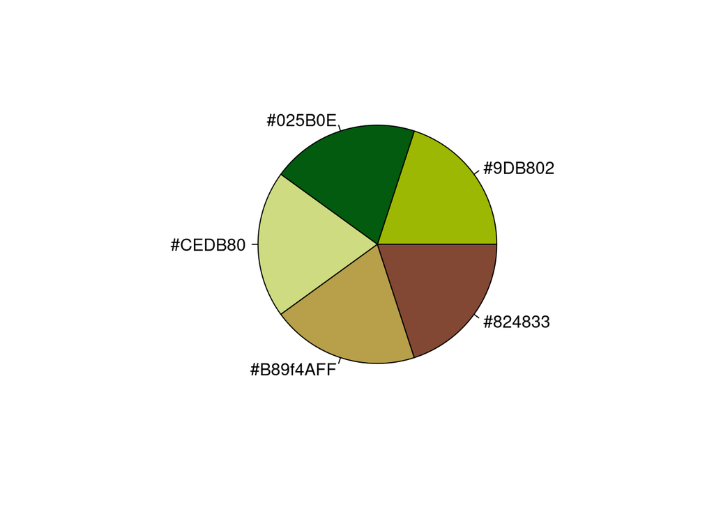

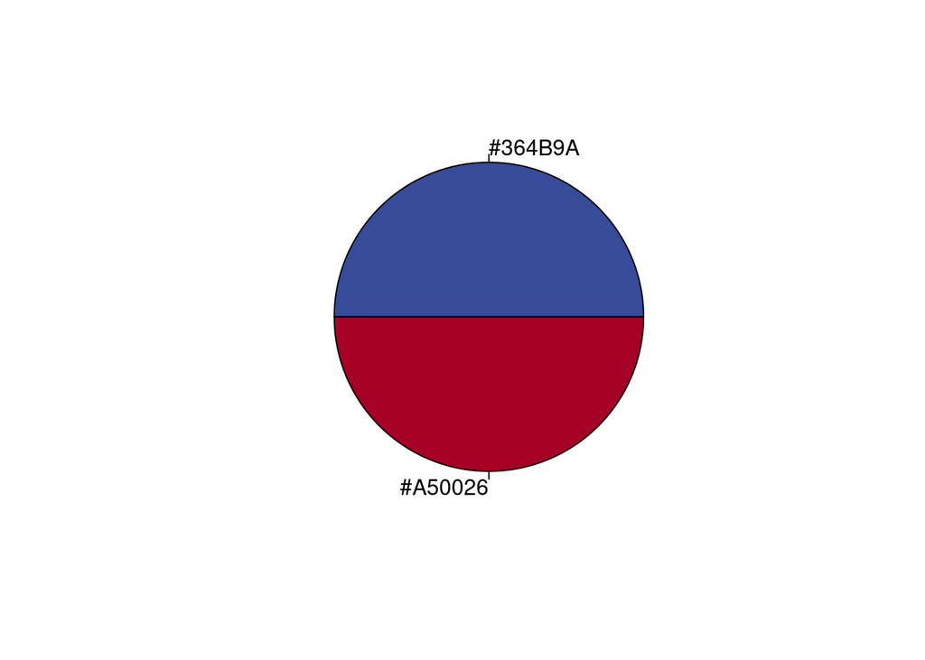

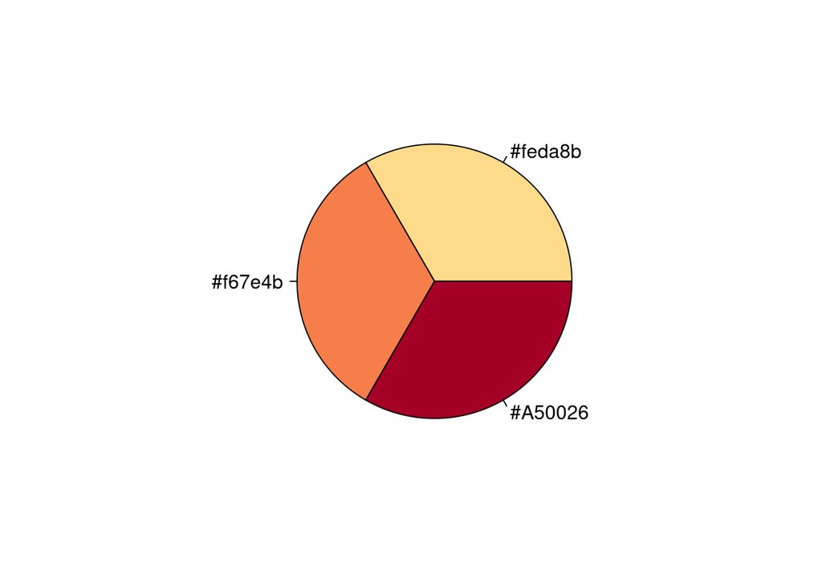

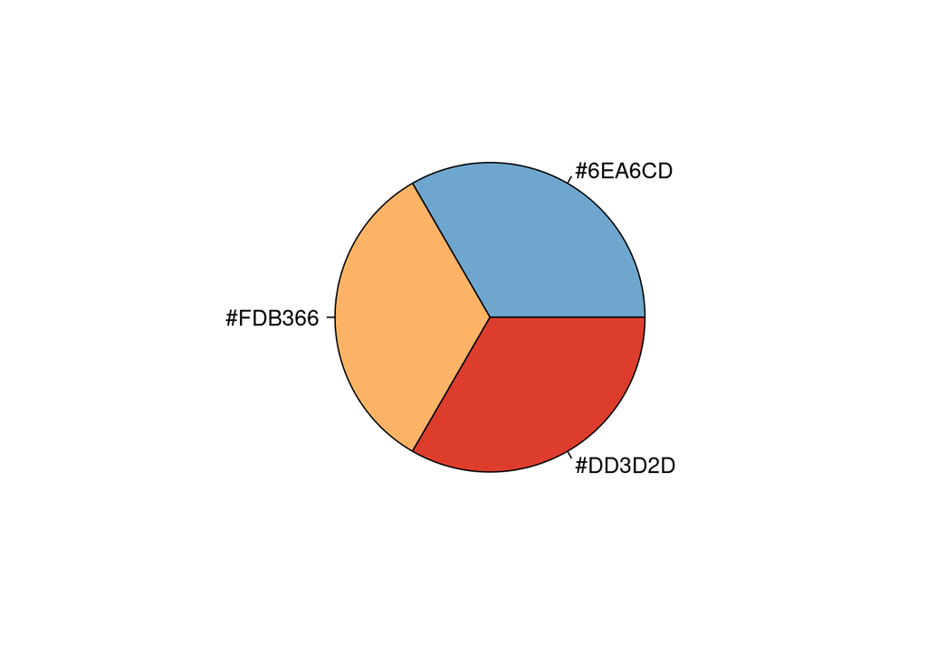

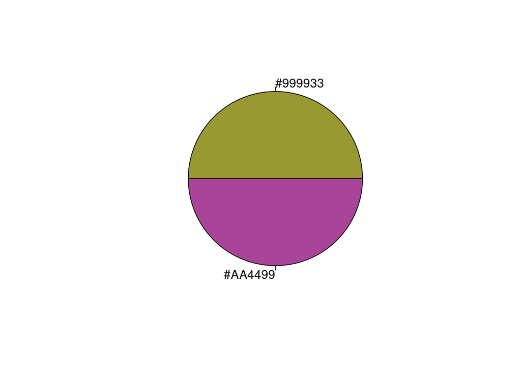

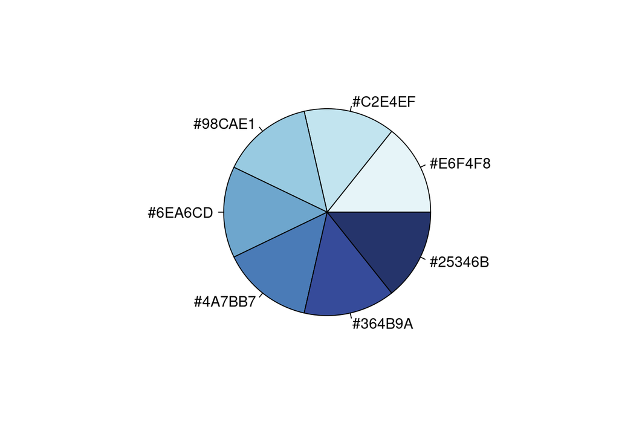

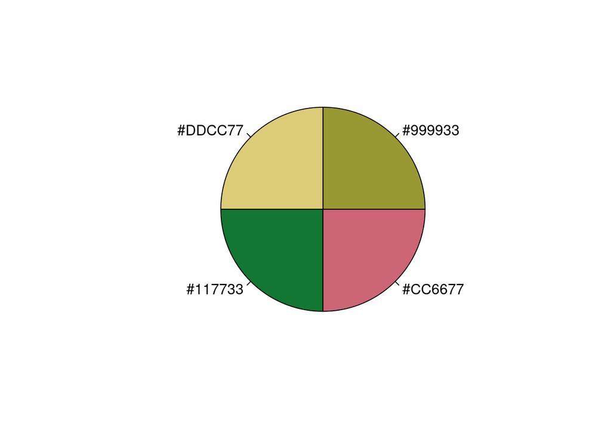

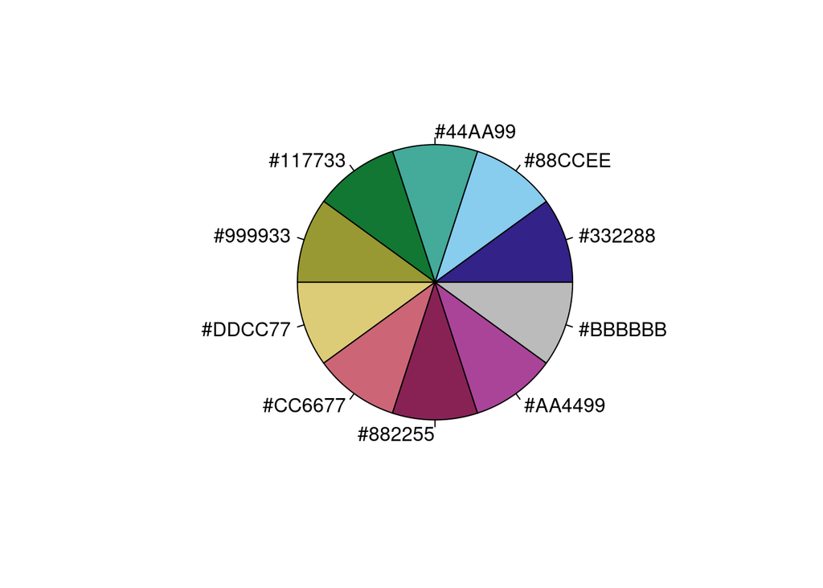

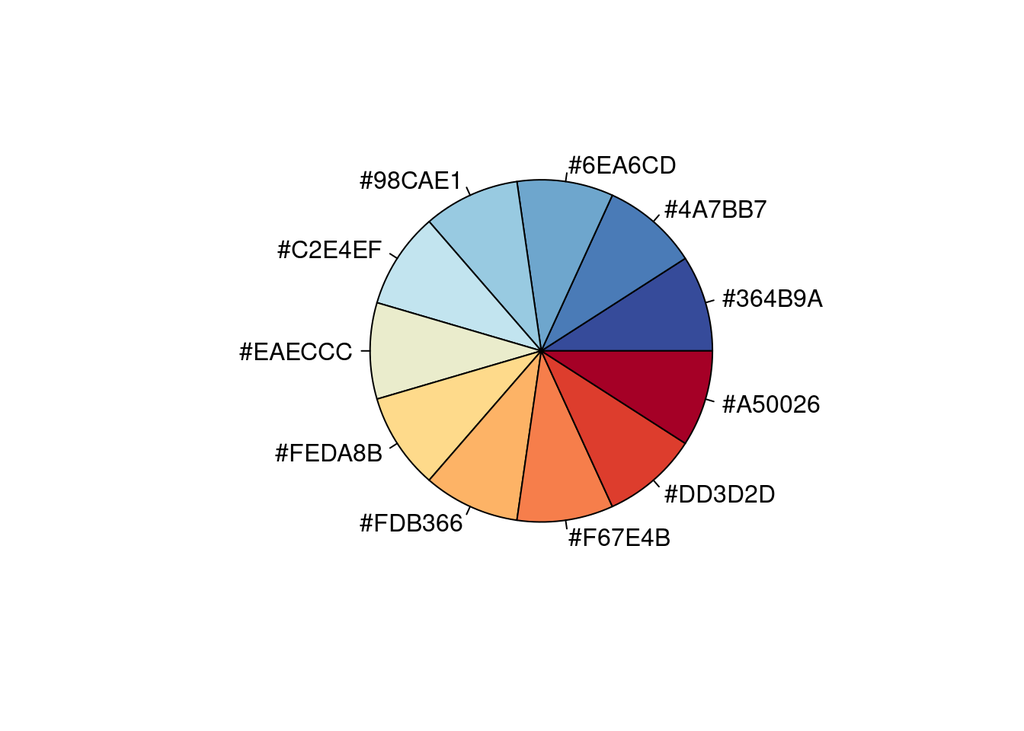

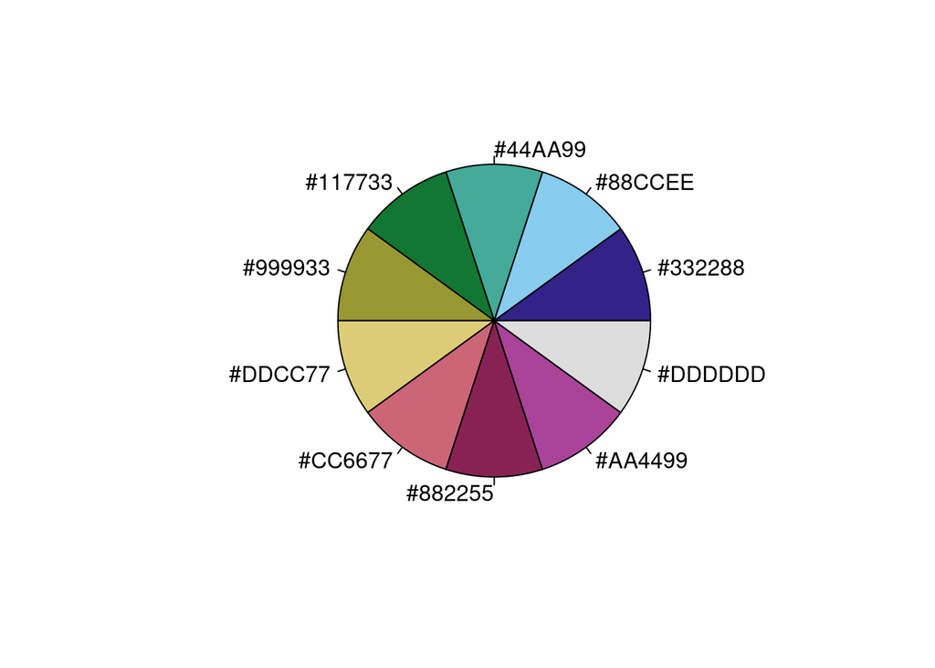

```r
# alterations
SBScols = c(SBS1="#afe9d6ff",SBS5="#afd2e9ff",SBS8="#e295ccff",SBS13="#c837aaff",SBS18="#a02c57ff",SBS26="#808080ff")
IDcols =  c(ID1="#ffccaaff",ID2="#ff9955ff",ID3="#ff6600ff",ID5="#aa4400ff",ID8="#d38d5fff",ID9="#deaa87ff")
```

## Load libraries

Note that sigvar is on github and has to be installed with devtools or similar

## load signature attributions

We load here the COSMIC or signal signatures signature attributions

```r
SV_sigs = read_tsv("/data/lungNENomics/work/alcalan/WGS/structural_variants/sv-somatic-cns-nf_lungNENomicsAndPublic_20092022_results/SV_signatures/release1_16Jun2023/decomposition/Decompose_Solution/Activities/Decompose_Solution_Activities.txt")
SV_sigs$Samples = str_replace(SV_sigs$Samples,"-","_")
SV_sigs$Samples = str_replace(SV_sigs$Samples,"_T$","")

CNV_sigs= read_tsv("/data/lungNENomics/work/alcalan/WGS/CNV/release1.1_PURPLE_19052023/mutational_signatures/decomposition/Decompose_Solution/Activities/Decompose_Solution_Activities.txt")
SBS_sigs  = read_tsv("/data/lungNENomics/work/alcalan/WGS/small_variants/somatic/release2_intersectmnps_15042023/mutational_signatures/lungNENomics/SBS96/Suggested_Solution/COSMIC_SBS96_Decomposed_Solution/Activities/COSMIC_SBS96_Activities.txt")
SBS_sigs$Samples = str_replace(SBS_sigs$Samples,"-","_")
SBS_sigs$Samples = str_replace(SBS_sigs$Samples,"_final","")
ID_sigs   = read_tsv("/data/lungNENomics/work/alcalan/WGS/small_variants/somatic/release2_intersectmnps_15042023/mutational_signatures/lungNENomics/ID83/Suggested_Solution/COSMIC_ID83_Decomposed_Solution/Activities/COSMIC_ID83_Activities.txt")
ID_sigs$Samples = str_replace(ID_sigs$Samples,"-","_")
ID_sigs$Samples = str_replace(ID_sigs$Samples,"_final","")
# note: no DBS

#load GEL signature attributions for comparison
SVsigs_GEL.samples = read_xlsx("/data/lungNENomics/work/alcalan/references/mutational_signatures/Degasperi2020_suptables.xlsx",sheet=2)
SVsigs_GEL = read_xlsx("/data/lungNENomics/work/alcalan/references/mutational_signatures/Degasperi2020_suptables.xlsx",sheet=8)
colnames(SVsigs_GEL)[1] = "ID"

SVsigs_GEL.refs = read_xlsx("/data/lungNENomics/work/alcalan/references/mutational_signatures/Degasperi2020_suptables.xlsx",sheet=6)
SVsigs_GEL = left_join(SVsigs_GEL,SVsigs_GEL.samples)
```

## Load metadata

```r
Attributes = read_tsv(unzip('../../Data/GabrielEtAl2020/Attributes.txt.zip')[1])
load("/data/lungNENomics/work/Descriptive_manuscript_data/MOFA/MOFA.Exp.Meth.Alt.CNV_lungNENomicsCombined/ParetoTI/variables_archetypes_MOFA_LNET.RData") # data also contained in Table S1
var_cli2 = read_tsv("/home/alcalan/lungNENomics/var_cli_plus_23022024.tsv")
gigascience_attributes = read_tsv("/data/lungNENomics/work/SextonoatesA/Attributes.txt")
```

```r
var_LNET$sample_id = as.character(var_LNET$sample_id)
var_LNET$group = var_LNET$archetype_k4_LF3_label

var_cli = bind_rows(var_LNET, Attributes %>% filter(Histopathology_simplified%in%c("LCNEC","SCLC")) %>%
                      mutate(sample_id = Sample_ID, group=Histopathology_simplified) %>% dplyr::select(sample_id,group) )
var_cli = bind_rows(var_cli,tibble(sample_id=c("LCNEC3T","LCNEC4T","S00715"),group="LCNEC") )
var_cli = left_join(var_cli, var_cli2 %>% dplyr::select(sample_id,age_cont)) # add age, not necessary if age as continuous variable in Table S1
```

Retrieve sample names for LNEN cohort samples with WGS

```r
WGS_LNENcohort_samples = var_cli %>% filter(str_detect(omics_group,"WGS"),!is.na(group)) %>% pull(sample_id)
WGS_LNENcohort_samples = c(WGS_LNENcohort_samples, "LCNEC3T","LCNEC4T","S00715","S01318","S01468","S01496","S01499","S01505","S02267") #Note: S01318 and 1468 are a former smoker
```

# Analyses

We first format the data for downstream analyses, joining the signature data with clinical data and normalizing the data to obtain relative signature attributions.

```r
SV_sigs.group = left_join(tibble(Samples=var_cli$sample_id,group=var_cli$group) %>% filter(Samples %in% WGS_LNENcohort_samples), SV_sigs )
SV_sigs.group[is.na(SV_sigs.group)] = 0 # fill samples with no SVs detected
SV_sigs.group.stats = SV_sigs.group %>% pivot_longer(cols = RefSigR2:RefSigR15,names_to = "Signature",values_to = "Mutations") %>% group_by(group,Signature) %>%
  summarize(prop=mean(Mutations>0),med=median(Mutations[Mutations>0]))
SV_sigs.group.stats$med[is.na(SV_sigs.group.stats$med)] = 0

CNV_sigs.group = left_join(tibble(Samples=var_cli$sample_id,group=var_cli$group) %>% filter(Samples %in% WGS_LNENcohort_samples),CNV_sigs )
CNV_sigs.group[is.na(CNV_sigs.group)] # no samples without CNV sigs
```

```
## <unspecified> [0]
```

```r
CNV_sigs.group.stats = CNV_sigs.group %>% pivot_longer(cols = CN1:CN21,names_to = "Signature",values_to = "Mutations") %>% group_by(group,Signature) %>%
  summarize(prop=mean(Mutations>0),med=median(Mutations[Mutations>0]))
CNV_sigs.group.stats$med[is.na(CNV_sigs.group.stats$med)] = 0

SBS_sigs.group = left_join(tibble(Samples=var_cli$sample_id,group=var_cli$group) %>% filter(Samples %in% WGS_LNENcohort_samples),SBS_sigs )
SBS_sigs.group[is.na(SBS_sigs.group)] # no samples without CNV sigs
```

```
## <unspecified> [0]
```

```r
SBS_sigs.group.stats = SBS_sigs.group %>% pivot_longer(cols = SBS1:SBS90,names_to = "Signature",values_to = "Mutations") %>% group_by(group,Signature) %>%
  summarize(prop=mean(Mutations>0),med=median(Mutations[Mutations>0]))
SBS_sigs.group.stats$med[is.na(SBS_sigs.group.stats$med)] = 0

ID_sigs.group = left_join(tibble(Samples=var_cli$sample_id,group=var_cli$group) %>% filter(Samples %in% WGS_LNENcohort_samples),ID_sigs )
ID_sigs.group[is.na(ID_sigs.group)] # no samples without CNV sigs
```

```
## <unspecified> [0]
```

```r
ID_sigs.group.stats = ID_sigs.group %>% pivot_longer(cols = ID1:ID9,names_to = "Signature",values_to = "Mutations") %>% group_by(group,Signature) %>%
  summarize(prop=mean(Mutations>0),med=median(Mutations[Mutations>0]))
ID_sigs.group.stats$med[is.na(ID_sigs.group.stats$med)] = 0

#Compute relative abundances
SV_sigs.group.props = sweep(SV_sigs.group[,3:10],1,rowSums(SV_sigs.group[,3:10]),"/" )
colnames(SV_sigs.group.props) = colnames(SV_sigs.group[,3:10])
SV_sigs.group.props$group = SV_sigs.group$group

CNV_sigs.group.props = sweep(CNV_sigs.group[,3:7],1,rowSums(CNV_sigs.group[,3:7]),"/" )
colnames(CNV_sigs.group.props) = colnames(CNV_sigs.group[,3:7])
CNV_sigs.group.props$group = CNV_sigs.group$group

SBS_sigs.group.props = sweep(SBS_sigs.group[,3:13],1,rowSums(SBS_sigs.group[,3:13]),"/" )
colnames(SBS_sigs.group.props) = colnames(SBS_sigs.group[,3:13])
SBS_sigs.group.props$group = SBS_sigs.group$group

ID_sigs.group.props = sweep(ID_sigs.group[,3:8],1,rowSums(ID_sigs.group[,3:8]),"/" )
colnames(ID_sigs.group.props) = colnames(ID_sigs.group[,3:8])
ID_sigs.group.props$group = ID_sigs.group$group

## total proportions
full_join0 <- function(x, y, fill = 0L, ...){
  z <- full_join(x, y, ...)
  new_cols <- setdiff(names(z), names(x))
  z <- replace_na(z, setNames(as.list(rep(fill, length(new_cols))), new_cols))
  z
}

sigs.groups = full_join0(full_join0(full_join0(SBS_sigs.group,ID_sigs.group), CNV_sigs.group), SV_sigs.group) %>% dplyr::relocate(group,.before=SBS1)
sigs.group.props = sweep(sigs.groups[,3:ncol(sigs.groups)],1,rowSums(sigs.groups[,3:ncol(sigs.groups)]),"/" ) # total proportion across all types of variants
colnames(sigs.group.props) = colnames(sigs.groups[,3:ncol(sigs.groups)])
sigs.group.props$group = sigs.groups$group
```

We remove signatures with a proportion below 5%

```r
### remove sigs <5%
sigs.groups.5p = sigs.groups
sigs.groups.5p[,2+1:(ncol(SBS_sigs)-1)][sweep(sigs.groups.5p[,2+1:(ncol(SBS_sigs)-1)], 1, rowSums(sigs.groups.5p[,2+1:(ncol(SBS_sigs)-1)]),"/" )<0.05] = 0
sigs.groups.5p[,2+(ncol(SBS_sigs)):(ncol(SBS_sigs)+ncol(ID_sigs)-2)][sweep(sigs.groups.5p[,2+(ncol(SBS_sigs)):(ncol(SBS_sigs)+ncol(ID_sigs)-2)], 1, rowSums(sigs.groups.5p[,2+(ncol(SBS_sigs)):(ncol(SBS_sigs)+ncol(ID_sigs)-2)]),"/" )<0.05] = 0
sigs.groups.5p[,2+(ncol(SBS_sigs)+ncol(ID_sigs)-1):(ncol(SBS_sigs)+ncol(ID_sigs)+ncol(CNV_sigs)-3)][sweep(sigs.groups.5p[,2+(ncol(SBS_sigs)+ncol(ID_sigs)-1):(ncol(SBS_sigs)+ncol(ID_sigs)+ncol(CNV_sigs)-3)], 1, rowSums(sigs.groups.5p[,2+(ncol(SBS_sigs)+ncol(ID_sigs)-1):(ncol(SBS_sigs)+ncol(ID_sigs)+ncol(CNV_sigs)-3)]),"/" )<0.05] = 0
sigs.groups.5p[,2+(ncol(SBS_sigs)+ncol(ID_sigs)+ncol(CNV_sigs)-2):(ncol(SBS_sigs)+ncol(ID_sigs)+ncol(CNV_sigs)+ncol(SV_sigs)-4)][sweep(sigs.groups.5p[,2+(ncol(SBS_sigs)+ncol(ID_sigs)+ncol(CNV_sigs)-2):(ncol(SBS_sigs)+ncol(ID_sigs)+ncol(CNV_sigs)+ncol(SV_sigs)-4)], 1, rowSums(sigs.groups.5p[,2+(ncol(SBS_sigs)+ncol(ID_sigs)+ncol(CNV_sigs)-2):(ncol(SBS_sigs)+ncol(ID_sigs)+ncol(CNV_sigs)+ncol(SV_sigs)-4)]),"/" )<0.05] = 0

sigs.groups.5p$group[sigs.groups.5p$group=="LCNEC" & sigs.groups.5p$SBS4>0] = "LCNEC (smoker)"
sigs.groups.5p$group[sigs.groups.5p$group=="LCNEC" & sigs.groups.5p$SBS4==0] = "LCNEC (non-smoker)"
sigs.groups.5p$group = factor(sigs.groups.5p$group,levels = c("Ca A1","Ca A2","Ca B","sc-enriched","LCNEC (non-smoker)","LCNEC (smoker)"))
```

## Compare signature attributions per group

### Dot plots (Fig. S10A)

```r
# by type of alteration
sigs.groups.5p.norm = sigs.groups.5p
sigs.groups.5p.norm[,-(1:2)] = sigs.groups.5p.norm[,-(1:2)]/3088269832*10**6 # based on purple length

## SBS
gg_SBS = plot_dots(sigs.groups.5p.norm[,-c(1,which(colSums(sigs.groups.5p[,-(1:2)])==0)+2)][,c(1:11)] %>% filter(!is.na(group)),
          group = "group",median = TRUE,normalized = FALSE) +
  scale_color_gradient2(low = "yellow",mid = "violet",high = "darkblue",midpoint = 0,trans="log10") +
  theme(axis.title.x = element_blank(),axis.text.x = element_blank()) + guides(size="none")
## ID
gg_ID = plot_dots(sigs.groups.5p.norm[,-c(1,which(colSums(sigs.groups.5p[,-(1:2)])==0)+2)][,c(1,12:17)] %>% filter(!is.na(group)),
          group = "group",median = TRUE,normalized = FALSE) +
  scale_color_gradient2(low = "yellow",mid = "violet",high = "darkblue",midpoint = -1,trans="log10") +
  theme(axis.title.x = element_blank(),axis.text.x = element_blank()) + guides(size="none")
## CN
gg_CN = plot_dots(sigs.groups.5p.norm[,-c(1,which(colSums(sigs.groups.5p[,-(1:2)])==0)+2)][,c(1,18:22)] %>% filter(!is.na(group)),
          group = "group",median = TRUE,normalized = FALSE) +
  scale_color_gradient2(low = "yellow",mid = "violet",high = "darkblue",midpoint = -1.5,trans="log10")  +
  theme(axis.title.x = element_blank(),axis.text.x = element_blank()) + guides(size="none")
## SV
gg_SV = plot_dots(sigs.groups.5p.norm[,-c(1,which(colSums(sigs.groups.5p[,-(1:2)])==0)+2)][,c(1,23:30)] %>% filter(!is.na(group)),
                  group = "group",median = TRUE,normalized = FALSE) +
  scale_color_gradient2(low = "yellow",mid = "violet",high = "darkblue",midpoint = -1.5,trans="log10")  +
  theme(axis.title.x = element_blank())
ggsave( gg_SBS/gg_ID/gg_CN/gg_SV + plot_layout(widths = c(1, 4)) , filename = "FigS11A_mutational_signatures_median_dotplots.svg",height = 2.5*4,width=3)
```

### Statistical tests

We test for each type of variant whether there are differences in presence/absence patterns and then in proportions in samples where the signature is present, across groups and types

### SBS

#### presence / absence or burden in present

SBS1 (age) is never seen in LCNEC, rarer in B and most frequent in A2

```r
var_cli$type[var_cli$group=="LCNEC"] = "LCNEC"
sigs.groups.5p = left_join(sigs.groups.5p,tibble(Samples=var_cli$sample_id,type=var_cli$type,age=var_cli$age_cont,sex=var_cli$sex_inferred,groupsimp = var_cli$group))
table(sigs.groups.5p$SBS1>0,sigs.groups.5p$groupsimp)
```

```
##
##         Ca A1 Ca A2 Ca B LCNEC sc-enriched
##   FALSE    21     7   18     9           2
##   TRUE     23    22    6     0           3
```

```r
fisher.test(table(sigs.groups.5p$SBS1>0,sigs.groups.5p$groupsimp)) # less in LCNEC
```

```
##
##  Fisher's Exact Test for Count Data
##
## data:  table(sigs.groups.5p$SBS1 > 0, sigs.groups.5p$groupsimp)
## p-value = 3.363e-05
## alternative hypothesis: two.sided
```

```r
fisher.test(table(sigs.groups.5p$SBS1>0,sigs.groups.5p$groupsimp)[,-4]) # more in A2, less in B, average in A1
```

```
##
##  Fisher's Exact Test for Count Data
##
## data:  table(sigs.groups.5p$SBS1 > 0, sigs.groups.5p$groupsimp)[, -4]
## p-value = 0.001849
## alternative hypothesis: two.sided
```

```r
table(sigs.groups.5p$SBS1>0,sigs.groups.5p$type)
```

```
##
##         Atypical Carcinoid LCNEC Typical
##   FALSE       12        18     9      18
##   TRUE         8        26     0      20
```

```r
fisher.test(table(sigs.groups.5p$SBS1>0,sigs.groups.5p$type)) # less in LCNEC
```

```
##
##  Fisher's Exact Test for Count Data
##
## data:  table(sigs.groups.5p$SBS1 > 0, sigs.groups.5p$type)
## p-value = 0.006418
## alternative hypothesis: two.sided
```

```r
fisher.test(table(sigs.groups.5p$SBS1>0,sigs.groups.5p$type)[,-3]) # less in LCNEC
```

```
##
##  Fisher's Exact Test for Count Data
##
## data:  table(sigs.groups.5p$SBS1 > 0, sigs.groups.5p$type)[, -3]
## p-value = 0.3649
## alternative hypothesis: two.sided
```

SBS5 (age) is present in all samples, can’t test presence

```r
table(sigs.groups.5p$SBS5>0,sigs.groups.5p$groupsimp) #everywhere
```

```
##
##        Ca A1 Ca A2 Ca B LCNEC sc-enriched
##   TRUE    44    29   24     9           5
```

SBS2 and 13 (APOBEC) are in 1 LNET sample and 1 LCNEC only, anecdotal although they are in LCNEC and sc-enriched despite smaller sample sizes and thus lead to a significant test. Interestingly, the LCNEC is from the non-smoker individual.

```r
table(sigs.groups.5p$SBS2>0,sigs.groups.5p$groupsimp)
```

```
##
##         Ca A1 Ca A2 Ca B LCNEC sc-enriched
##   FALSE    44    28   24     8           5
##   TRUE      0     1    0     1           0
```

```r
fisher.test(table(sigs.groups.5p$SBS2>0,sigs.groups.5p$groupsimp))
```

```
##
##  Fisher's Exact Test for Count Data
##
## data:  table(sigs.groups.5p$SBS2 > 0, sigs.groups.5p$groupsimp)
## p-value = 0.1725
## alternative hypothesis: two.sided
```

```r
fisher.test(table(sigs.groups.5p$SBS2>0,sigs.groups.5p$groupsimp)[,-4])#
```

```
##
##  Fisher's Exact Test for Count Data
##
## data:  table(sigs.groups.5p$SBS2 > 0, sigs.groups.5p$groupsimp)[, -4]
## p-value = 0.5686
## alternative hypothesis: two.sided
```

```r
table(sigs.groups.5p$SBS2>0,sigs.groups.5p$type)
```

```
##
##         Atypical Carcinoid LCNEC Typical
##   FALSE       20        43     8      38
##   TRUE         0         1     1       0
```

```r
fisher.test(table(sigs.groups.5p$SBS2>0,sigs.groups.5p$type)) # a bit more in LCNEC
```

```
##
##  Fisher's Exact Test for Count Data
##
## data:  table(sigs.groups.5p$SBS2 > 0, sigs.groups.5p$type)
## p-value = 0.1874
## alternative hypothesis: two.sided
```

```r
fisher.test(table(sigs.groups.5p$SBS2>0,sigs.groups.5p$type)[,-3])#borderline more in SC
```

```
##
##  Fisher's Exact Test for Count Data
##
## data:  table(sigs.groups.5p$SBS2 > 0, sigs.groups.5p$type)[, -3]
## p-value = 1
## alternative hypothesis: two.sided
```

```r
table(sigs.groups.5p$SBS13>0,sigs.groups.5p$groupsimp)
```

```
##
##         Ca A1 Ca A2 Ca B LCNEC sc-enriched
##   FALSE    44    29   24     8           4
##   TRUE      0     0    0     1           1
```

```r
fisher.test(table(sigs.groups.5p$SBS13>0,sigs.groups.5p$groupsimp)) # more in LCNEC and AC
```

```
##
##  Fisher's Exact Test for Count Data
##
## data:  table(sigs.groups.5p$SBS13 > 0, sigs.groups.5p$groupsimp)
## p-value = 0.01491
## alternative hypothesis: two.sided
```

```r
fisher.test(table(sigs.groups.5p$SBS13>0,sigs.groups.5p$groupsimp)[,-4]) #more in SC
```

```
##
##  Fisher's Exact Test for Count Data
##
## data:  table(sigs.groups.5p$SBS13 > 0, sigs.groups.5p$groupsimp)[, -4]
## p-value = 0.04902
## alternative hypothesis: two.sided
```

```r
table(sigs.groups.5p$SBS13>0,sigs.groups.5p$type)
```

```
##
##         Atypical Carcinoid LCNEC Typical
##   FALSE       19        44     8      38
##   TRUE         1         0     1       0
```

```r
fisher.test(table(sigs.groups.5p$SBS13>0,sigs.groups.5p$type)) # more in LCNEC
```

```
##
##  Fisher's Exact Test for Count Data
##
## data:  table(sigs.groups.5p$SBS13 > 0, sigs.groups.5p$type)
## p-value = 0.03538
## alternative hypothesis: two.sided
```

```r
fisher.test(table(sigs.groups.5p$SBS13>0,sigs.groups.5p$type)[,-3]) #more in SC
```

```
##
##  Fisher's Exact Test for Count Data
##
## data:  table(sigs.groups.5p$SBS13 > 0, sigs.groups.5p$type)[, -3]
## p-value = 0.1961
## alternative hypothesis: two.sided
```

```r
#Combining both signals, same ass SBS2 because of SBS2 and 13 co-occurence
table((sigs.groups.5p$SBS2+sigs.groups.5p$SBS13)>0,sigs.groups.5p$groupsimp)
```

```
##
##         Ca A1 Ca A2 Ca B LCNEC sc-enriched
##   FALSE    44    28   24     8           4
##   TRUE      0     1    0     1           1
```

```r
fisher.test(table((sigs.groups.5p$SBS2+sigs.groups.5p$SBS13)>0,sigs.groups.5p$groupsimp)) # more in LCNEC
```

```
##
##  Fisher's Exact Test for Count Data
##
## data:  table((sigs.groups.5p$SBS2 + sigs.groups.5p$SBS13) > 0, sigs.groups.5p$groupsimp)
## p-value = 0.02537
## alternative hypothesis: two.sided
```

```r
fisher.test(table((sigs.groups.5p$SBS2+sigs.groups.5p$SBS13)>0,sigs.groups.5p$groupsimp)[,-4]) #more in SC
```

```
##
##  Fisher's Exact Test for Count Data
##
## data:  table((sigs.groups.5p$SBS2 + sigs.groups.5p$SBS13) > 0, sigs.groups.5p$groupsimp)[, -4]
## p-value = 0.05339
## alternative hypothesis: two.sided
```

```r
sigs.groups.5p %>% filter(SBS2 + SBS13>0) #sample names with APOBEC signature
```

```
## # A tibble: 3 × 36
##   Samples    group    SBS1  SBS2  SBS4  SBS5  SBS8 SBS13 SBS16 SBS18 SBS26 SBS57
##   <chr>      <fct>   <dbl> <dbl> <dbl> <dbl> <dbl> <dbl> <dbl> <dbl> <dbl> <dbl>
## 1 LNEN056_TU Ca A2       0   252     0  3109     0     0     0     0     0     0
## 2 LNEN071_TU sc-enr…   516     0     0  4548  3113   455     0     0     0     0
## 3 LCNEC3T    LCNEC …     0  5506     0 15323     0  9088     0     0     0     0
## # ℹ 24 more variables: SBS90 <dbl>, ID1 <dbl>, ID2 <dbl>, ID3 <dbl>, ID5 <dbl>,
## #   ID8 <dbl>, ID9 <dbl>, CN1 <dbl>, CN2 <dbl>, CN9 <dbl>, CN20 <dbl>,
## #   CN21 <dbl>, RefSigR2 <dbl>, RefSigR4 <dbl>, RefSigR5 <dbl>,
## #   RefSigR6a <dbl>, RefSigR6b <dbl>, RefSigR11 <dbl>, RefSigR13 <dbl>,
## #   RefSigR15 <dbl>, type <chr>, age <dbl>, sex <chr>, groupsimp <chr>
```

SBS4 (smoking), only in LCNEC

```r
table(sigs.groups.5p$SBS4>0,sigs.groups.5p$groupsimp)
```

```
##
##         Ca A1 Ca A2 Ca B LCNEC sc-enriched
##   FALSE    44    29   24     1           5
##   TRUE      0     0    0     8           0
```

```r
fisher.test(table(sigs.groups.5p$SBS4>0,sigs.groups.5p$groupsimp)) # only in LCNEC
```

```
##
##  Fisher's Exact Test for Count Data
##
## data:  table(sigs.groups.5p$SBS4 > 0, sigs.groups.5p$groupsimp)
## p-value = 2.038e-11
## alternative hypothesis: two.sided
```

```r
table(sigs.groups.5p$SBS4>0,sigs.groups.5p$type)
```

```
##
##         Atypical Carcinoid LCNEC Typical
##   FALSE       20        44     1      38
##   TRUE         0         0     8       0
```

```r
fisher.test(table(sigs.groups.5p$SBS4>0,sigs.groups.5p$type)) # only in LCNEC
```

```
##
##  Fisher's Exact Test for Count Data
##
## data:  table(sigs.groups.5p$SBS4 > 0, sigs.groups.5p$type)
## p-value = 2.038e-11
## alternative hypothesis: two.sided
```

SBS18 (ROS), presence is a bit anecdotal, observed once in A1 and SC, borderline significant

```r
table(sigs.groups.5p$SBS18>0,sigs.groups.5p$groupsimp)
```

```
##
##         Ca A1 Ca A2 Ca B LCNEC sc-enriched
##   FALSE    43    29   24     9           4
##   TRUE      1     0    0     0           1
```

```r
fisher.test(table(sigs.groups.5p$SBS18>0,sigs.groups.5p$groupsimp)) # never in LCNEC
```

```
##
##  Fisher's Exact Test for Count Data
##
## data:  table(sigs.groups.5p$SBS18 > 0, sigs.groups.5p$groupsimp)
## p-value = 0.1297
## alternative hypothesis: two.sided
```

```r
fisher.test(table(sigs.groups.5p$SBS18>0,sigs.groups.5p$groupsimp)[,-4]) #once in A1 and SC, borderline signif
```

```
##
##  Fisher's Exact Test for Count Data
##
## data:  table(sigs.groups.5p$SBS18 > 0, sigs.groups.5p$groupsimp)[, -4]
## p-value = 0.0961
## alternative hypothesis: two.sided
```

```r
table(sigs.groups.5p$SBS18>0,sigs.groups.5p$type)
```

```
##
##         Atypical Carcinoid LCNEC Typical
##   FALSE       19        43     9      38
##   TRUE         1         1     0       0
```

```r
fisher.test(table(sigs.groups.5p$SBS18>0,sigs.groups.5p$type)) # not signif
```

```
##
##  Fisher's Exact Test for Count Data
##
## data:  table(sigs.groups.5p$SBS18 > 0, sigs.groups.5p$type)
## p-value = 0.5712
## alternative hypothesis: two.sided
```

```r
fisher.test(table(sigs.groups.5p$SBS18>0,sigs.groups.5p$type)[,-3]) # not signif
```

```
##
##  Fisher's Exact Test for Count Data
##
## data:  table(sigs.groups.5p$SBS18 > 0, sigs.groups.5p$type)[, -3]
## p-value = 0.4917
## alternative hypothesis: two.sided
```

SBS26 (defective DNA mismatch repair), only in 2 samples

```r
table(sigs.groups.5p$SBS26>0,sigs.groups.5p$groupsimp)
```

```
##
##         Ca A1 Ca A2 Ca B LCNEC sc-enriched
##   FALSE    44    27   24     9           5
##   TRUE      0     2    0     0           0
```

```r
fisher.test(table(sigs.groups.5p$SBS26>0,sigs.groups.5p$groupsimp)) # never in LCNEC
```

```
##
##  Fisher's Exact Test for Count Data
##
## data:  table(sigs.groups.5p$SBS26 > 0, sigs.groups.5p$groupsimp)
## p-value = 0.3491
## alternative hypothesis: two.sided
```

```r
fisher.test(table(sigs.groups.5p$SBS26>0,sigs.groups.5p$groupsimp)[,-4]) #only reported in a A2 but not signif
```

```
##
##  Fisher's Exact Test for Count Data
##
## data:  table(sigs.groups.5p$SBS26 > 0, sigs.groups.5p$groupsimp)[, -4]
## p-value = 0.2285
## alternative hypothesis: two.sided
```

```r
table(sigs.groups.5p$SBS26>0,sigs.groups.5p$type)
```

```
##
##         Atypical Carcinoid LCNEC Typical
##   FALSE       20        43     9      37
##   TRUE         0         1     0       1
```

```r
fisher.test(table(sigs.groups.5p$SBS26>0,sigs.groups.5p$type))
```

```
##
##  Fisher's Exact Test for Count Data
##
## data:  table(sigs.groups.5p$SBS26 > 0, sigs.groups.5p$type)
## p-value = 1
## alternative hypothesis: two.sided
```

```r
fisher.test(table(sigs.groups.5p$SBS26>0,sigs.groups.5p$type)[,-3])
```

```
##
##  Fisher's Exact Test for Count Data
##
## data:  table(sigs.groups.5p$SBS26 > 0, sigs.groups.5p$type)[, -3]
## p-value = 1
## alternative hypothesis: two.sided
```

Other signatures are mostly attributed to unknown putatively endogenous processses or artifacts. Most are only observed in a couple of samples except for SBS8 which shows an interesting pattern of strong of almost universal presence in Ca B. SBS8 presence is also significantly more frequent in Atypical carcinoids, although this seems due to the bias in atypical in Ca B as the association with type is non significant among Ca B, but among atypical the difference between groups stays present.

```r
table(sigs.groups.5p$SBS8>0,sigs.groups.5p$groupsimp)
```

```
##
##         Ca A1 Ca A2 Ca B LCNEC sc-enriched
##   FALSE    18    19    3     9           2
##   TRUE     26    10   21     0           3
```

```r
fisher.test(table(sigs.groups.5p$SBS8>0,sigs.groups.5p$groupsimp)) # never in LCNEC
```

```
##
##  Fisher's Exact Test for Count Data
##
## data:  table(sigs.groups.5p$SBS8 > 0, sigs.groups.5p$groupsimp)
## p-value = 4.491e-06
## alternative hypothesis: two.sided
```

```r
fisher.test(table(sigs.groups.5p$SBS8>0,sigs.groups.5p$groupsimp)[,-4]) #much more in B
```

```
##
##  Fisher's Exact Test for Count Data
##
## data:  table(sigs.groups.5p$SBS8 > 0, sigs.groups.5p$groupsimp)[, -4]
## p-value = 0.0007579
## alternative hypothesis: two.sided
```

```r
table(sigs.groups.5p$SBS8>0,sigs.groups.5p$type)
```

```
##
##         Atypical Carcinoid LCNEC Typical
##   FALSE        6        22     9      14
##   TRUE        14        22     0      24
```

```r
fisher.test(table(sigs.groups.5p$SBS8>0,sigs.groups.5p$type)) # never in LCNEC
```

```
##
##  Fisher's Exact Test for Count Data
##
## data:  table(sigs.groups.5p$SBS8 > 0, sigs.groups.5p$type)
## p-value = 0.001561
## alternative hypothesis: two.sided
```

```r
fisher.test(table(sigs.groups.5p$SBS8>0,sigs.groups.5p$groupsimp)[,-3]) #much more in B
```

```
##
##  Fisher's Exact Test for Count Data
##
## data:  table(sigs.groups.5p$SBS8 > 0, sigs.groups.5p$groupsimp)[, -3]
## p-value = 0.002347
## alternative hypothesis: two.sided
```

```r
table(sigs.groups.5p$SBS8[sigs.groups.5p$groupsimp=="Ca B"]>0,sigs.groups.5p$type[sigs.groups.5p$groupsimp=="Ca B"])
```

```
##
##         Atypical Carcinoid Typical
##   FALSE        0         1       2
##   TRUE         4        10       7
```

```r
fisher.test(table(sigs.groups.5p$SBS8[sigs.groups.5p$groupsimp=="Ca B"]>0,sigs.groups.5p$type[sigs.groups.5p$groupsimp=="Ca B"])) # the samples without it are either carcinoid or typical but association with type within Ca B is non significant
```

```
##
##  Fisher's Exact Test for Count Data
##
## data:  table(sigs.groups.5p$SBS8[sigs.groups.5p$groupsimp == "Ca B"] > 0, sigs.groups.5p$type[sigs.groups.5p$groupsimp == "Ca B"])
## p-value = 0.7554
## alternative hypothesis: two.sided
```

```r
table(sigs.groups.5p$SBS8[sigs.groups.5p$type=="Atypical"]>0,sigs.groups.5p$groupsimp[sigs.groups.5p$type=="Atypical"])
```

```
##
##         Ca A1 Ca A2 Ca B sc-enriched
##   FALSE     1     3    0           2
##   TRUE      8     0    4           2
```

```r
fisher.test(table(sigs.groups.5p$SBS8[sigs.groups.5p$type=="Atypical"]>0,sigs.groups.5p$groupsimp[sigs.groups.5p$type=="Atypical"])) #even among atypical, the differencess between groups remains
```

```
##
##  Fisher's Exact Test for Count Data
##
## data:  table(sigs.groups.5p$SBS8[sigs.groups.5p$type == "Atypical"] > 0, sigs.groups.5p$groupsimp[sigs.groups.5p$type == "Atypical"])
## p-value = 0.01331
## alternative hypothesis: two.sided
```

```r
table(sigs.groups.5p$SBS16>0,sigs.groups.5p$groupsimp) # not observed anymore becausse below 5% in all samples where present
```

```
##
##         Ca A1 Ca A2 Ca B LCNEC sc-enriched
##   FALSE    44    29   24     9           5
```

```r
table(sigs.groups.5p$SBS90>0,sigs.groups.5p$groupsimp) # just in a single sample
```

```
##
##         Ca A1 Ca A2 Ca B LCNEC sc-enriched
##   FALSE    44    29   23     9           5
##   TRUE      0     0    1     0           0
```

#### Differences in burden among samples where present

We first use linear regression to test for an effect of groups and type, ignoring signatures present in 3 or less samples. We find some differences among groups

```r
lm1_GTAS = lm(log10(SBS1)~group+type+age+sex,data = sigs.groups.5p %>% filter(groupsimp!="LCNEC",SBS1!=0))
lm1_GTA  = lm(log10(SBS1)~group+type+age,data = sigs.groups.5p %>% filter(groupsimp!="LCNEC",SBS1!=0))
lm1_GT   = lm(log10(SBS1)~group+type,data = sigs.groups.5p %>% filter(groupsimp!="LCNEC",SBS1!=0))
lm1_G    = lm(log10(SBS1)~group,data = sigs.groups.5p %>% filter(groupsimp!="LCNEC",SBS1!=0))
anova(lm1_GTAS) # group, type, and age signif
```

```
## Analysis of Variance Table
##
## Response: log10(SBS1)
##           Df  Sum Sq  Mean Sq F value   Pr(>F)
## group      3 0.83358 0.277860  4.9357 0.004697 **
## type       2 0.44554 0.222772  3.9572 0.025956 *
## age        1 0.24050 0.240502  4.2721 0.044397 *
## sex        1 0.13279 0.132788  2.3588 0.131432
## Residuals 46 2.58961 0.056296
## ---
## Signif. codes:  0 '***' 0.001 '**' 0.01 '*' 0.05 '.' 0.1 ' ' 1
```

```r
anova(lm1_GTAS,lm1_GTA) # not different
```

```
## Analysis of Variance Table
##
## Model 1: log10(SBS1) ~ group + type + age + sex
## Model 2: log10(SBS1) ~ group + type + age
##   Res.Df    RSS Df Sum of Sq      F Pr(>F)
## 1     46 2.5896
## 2     47 2.7224 -1  -0.13279 2.3588 0.1314
```

```r
anova(lm1_GTA,lm1_GT) # different
```

```
## Analysis of Variance Table
##
## Model 1: log10(SBS1) ~ group + type + age
## Model 2: log10(SBS1) ~ group + type
##   Res.Df    RSS Df Sum of Sq      F  Pr(>F)
## 1     47 2.7224
## 2     48 2.9629 -1   -0.2405 4.1521 0.04723 *
## ---
## Signif. codes:  0 '***' 0.001 '**' 0.01 '*' 0.05 '.' 0.1 ' ' 1
```

```r
anova(lm1_GT,lm1_G) # different
```

```
## Analysis of Variance Table
##
## Model 1: log10(SBS1) ~ group + type
## Model 2: log10(SBS1) ~ group
##   Res.Df    RSS Df Sum of Sq     F  Pr(>F)
## 1     48 2.9629
## 2     50 3.4084 -2  -0.44554 3.609 0.03466 *
## ---
## Signif. codes:  0 '***' 0.001 '**' 0.01 '*' 0.05 '.' 0.1 ' ' 1
```

```r
anova(lm1_GTAS,lm1_GTA) # not different => best model is GTA
```

```
## Analysis of Variance Table
##
## Model 1: log10(SBS1) ~ group + type + age + sex
## Model 2: log10(SBS1) ~ group + type + age
##   Res.Df    RSS Df Sum of Sq      F Pr(>F)
## 1     46 2.5896
## 2     47 2.7224 -1  -0.13279 2.3588 0.1314
```

```r
summary(lm1_GTAS)
```

```
##
## Call:
## lm(formula = log10(SBS1) ~ group + type + age + sex, data = sigs.groups.5p %>%
##     filter(groupsimp != "LCNEC", SBS1 != 0))
##
## Residuals:
##      Min       1Q   Median       3Q      Max
## -0.42883 -0.14068 -0.00851  0.08577  0.80507
##
## Coefficients:
##                    Estimate Std. Error t value Pr(>|t|)
## (Intercept)       1.8354351  0.1851972   9.911 5.41e-13 ***
## groupCa A2       -0.0505065  0.0903993  -0.559   0.5791
## groupCa B         0.0005741  0.1225981   0.005   0.9963
## groupsc-enriched  0.1941672  0.1562610   1.243   0.2203
## typeCarcinoid    -0.0449647  0.1039640  -0.433   0.6674
## typeTypical      -0.2373416  0.1073314  -2.211   0.0320 *
## age               0.0058564  0.0026502   2.210   0.0321 *
## sexM              0.1168396  0.0760762   1.536   0.1314
## ---
## Signif. codes:  0 '***' 0.001 '**' 0.01 '*' 0.05 '.' 0.1 ' ' 1
##
## Residual standard error: 0.2373 on 46 degrees of freedom
## Multiple R-squared:  0.3895, Adjusted R-squared:  0.2966
## F-statistic: 4.193 on 7 and 46 DF,  p-value: 0.001202
```

```r
summary(lm1_GTA) #group variables not significant, less in Typical, increase with age
```

```
##
## Call:
## lm(formula = log10(SBS1) ~ group + type + age, data = sigs.groups.5p %>%
##     filter(groupsimp != "LCNEC", SBS1 != 0))
##
## Residuals:
##      Min       1Q   Median       3Q      Max
## -0.33492 -0.15019 -0.00027  0.10323  0.79598
##
## Coefficients:
##                   Estimate Std. Error t value Pr(>|t|)
## (Intercept)       1.892414   0.184047  10.282 1.29e-13 ***
## groupCa A2       -0.029721   0.090663  -0.328   0.7445
## groupCa B         0.081164   0.112391   0.722   0.4738
## groupsc-enriched  0.211044   0.158111   1.335   0.1884
## typeCarcinoid    -0.066883   0.104458  -0.640   0.5251
## typeTypical      -0.244295   0.108775  -2.246   0.0295 *
## age               0.005450   0.002675   2.038   0.0472 *
## ---
## Signif. codes:  0 '***' 0.001 '**' 0.01 '*' 0.05 '.' 0.1 ' ' 1
##
## Residual standard error: 0.2407 on 47 degrees of freedom
## Multiple R-squared:  0.3582, Adjusted R-squared:  0.2763
## F-statistic: 4.373 on 6 and 47 DF,  p-value: 0.001379
```

```r
lm5_GTAS = lm(log10(SBS5)~group+type+age+sex,data = sigs.groups.5p %>% filter(groupsimp!="LCNEC",SBS5!=0))
lm5_GTA  = lm(log10(SBS5)~group+type+age,data = sigs.groups.5p %>% filter(groupsimp!="LCNEC",SBS5!=0))
lm5_GT   = lm(log10(SBS5)~group+type,data = sigs.groups.5p %>% filter(groupsimp!="LCNEC",SBS5!=0))
lm5_G    = lm(log10(SBS5)~group,data = sigs.groups.5p %>% filter(groupsimp!="LCNEC",SBS5!=0))
anova(lm5_GTAS) # group, type and age signif
```

```
## Analysis of Variance Table
##
## Response: log10(SBS5)
##           Df Sum Sq Mean Sq F value    Pr(>F)
## group      3 1.0333 0.34443  7.3789 0.0001712 ***
## type       2 0.5978 0.29891  6.4037 0.0024703 **
## age        1 0.2690 0.26900  5.7631 0.0183357 *
## sex        1 0.0108 0.01076  0.2305 0.6322592
## Residuals 94 4.3877 0.04668
## ---
## Signif. codes:  0 '***' 0.001 '**' 0.01 '*' 0.05 '.' 0.1 ' ' 1
```

```r
anova(lm5_GTAS,lm5_GTA) # not different
```

```
## Analysis of Variance Table
##
## Model 1: log10(SBS5) ~ group + type + age + sex
## Model 2: log10(SBS5) ~ group + type + age
##   Res.Df    RSS Df Sum of Sq      F Pr(>F)
## 1     94 4.3877
## 2     95 4.3984 -1  -0.01076 0.2305 0.6323
```

```r
anova(lm5_GTA,lm5_GT) # different
```

```
## Analysis of Variance Table
##
## Model 1: log10(SBS5) ~ group + type + age
## Model 2: log10(SBS5) ~ group + type
##   Res.Df    RSS Df Sum of Sq      F  Pr(>F)
## 1     95 4.3984
## 2     96 4.6674 -1    -0.269 5.8101 0.01786 *
## ---
## Signif. codes:  0 '***' 0.001 '**' 0.01 '*' 0.05 '.' 0.1 ' ' 1
```

```r
anova(lm5_GT,lm5_G) # different
```

```
## Analysis of Variance Table
##
## Model 1: log10(SBS5) ~ group + type
## Model 2: log10(SBS5) ~ group
##   Res.Df    RSS Df Sum of Sq      F   Pr(>F)
## 1     96 4.6674
## 2     98 5.2652 -2  -0.59781 6.1479 0.003074 **
## ---
## Signif. codes:  0 '***' 0.001 '**' 0.01 '*' 0.05 '.' 0.1 ' ' 1
```

```r
anova(lm5_GTAS,lm5_GTA) # not different => best model is GTA
```

```
## Analysis of Variance Table
##
## Model 1: log10(SBS5) ~ group + type + age + sex
## Model 2: log10(SBS5) ~ group + type + age
##   Res.Df    RSS Df Sum of Sq      F Pr(>F)
## 1     94 4.3877
## 2     95 4.3984 -1  -0.01076 0.2305 0.6323
```

```r
summary(lm5_GTAS)
```

```
##
## Call:
## lm(formula = log10(SBS5) ~ group + type + age + sex, data = sigs.groups.5p %>%
##     filter(groupsimp != "LCNEC", SBS5 != 0))
##
## Residuals:
##      Min       1Q   Median       3Q      Max
## -0.56058 -0.12763 -0.01064  0.09215  0.88669
##
## Coefficients:
##                   Estimate Std. Error t value Pr(>|t|)
## (Intercept)       3.070402   0.123862  24.789  < 2e-16 ***
## groupCa A2       -0.090803   0.061250  -1.483  0.14155
## groupCa B         0.042867   0.060604   0.707  0.48111
## groupsc-enriched  0.106011   0.108143   0.980  0.32946
## typeCarcinoid    -0.054166   0.062131  -0.872  0.38554
## typeTypical      -0.197396   0.063665  -3.101  0.00255 **
## age               0.004204   0.001724   2.439  0.01661 *
## sexM              0.023560   0.049071   0.480  0.63226
## ---
## Signif. codes:  0 '***' 0.001 '**' 0.01 '*' 0.05 '.' 0.1 ' ' 1
##
## Residual standard error: 0.216 on 94 degrees of freedom
## Multiple R-squared:  0.3034, Adjusted R-squared:  0.2515
## F-statistic: 5.848 on 7 and 94 DF,  p-value: 1.192e-05
```

```r
summary(lm5_GTA) #increase with age, less in typical
```

```
##
## Call:
## lm(formula = log10(SBS5) ~ group + type + age, data = sigs.groups.5p %>%
##     filter(groupsimp != "LCNEC", SBS5 != 0))
##
## Residuals:
##      Min       1Q   Median       3Q      Max
## -0.55584 -0.12902 -0.01105  0.09789  0.90659
##
## Coefficients:
##                   Estimate Std. Error t value Pr(>|t|)
## (Intercept)       3.083138   0.120497  25.587  < 2e-16 ***
## groupCa A2       -0.088829   0.060864  -1.459  0.14774
## groupCa B         0.055070   0.054794   1.005  0.31743
## groupsc-enriched  0.108742   0.107555   1.011  0.31457
## typeCarcinoid    -0.057549   0.061480  -0.936  0.35162
## typeTypical      -0.199634   0.063236  -3.157  0.00214 **
## age               0.004113   0.001706   2.410  0.01786 *
## ---
## Signif. codes:  0 '***' 0.001 '**' 0.01 '*' 0.05 '.' 0.1 ' ' 1
##
## Residual standard error: 0.2152 on 95 degrees of freedom
## Multiple R-squared:  0.3017, Adjusted R-squared:  0.2576
## F-statistic:  6.84 on 6 and 95 DF,  p-value: 4.705e-06
```

```r
lm8_GTAS = lm(log10(SBS8)~group+type+age+sex,data = sigs.groups.5p %>% filter(groupsimp!="LCNEC",SBS8!=0))
lm8_GTA  = lm(log10(SBS8)~group+type+age,data = sigs.groups.5p %>% filter(groupsimp!="LCNEC",SBS8!=0))
lm8_GT   = lm(log10(SBS8)~group+type,data = sigs.groups.5p %>% filter(groupsimp!="LCNEC",SBS8!=0))
lm8_GA   = lm(log10(SBS8)~group+age,data = sigs.groups.5p %>% filter(groupsimp!="LCNEC",SBS8!=0))
lm8_G    = lm(log10(SBS8)~group,data = sigs.groups.5p %>% filter(groupsimp!="LCNEC",SBS8!=0))
anova(lm8_GTAS) # group and age signif
```

```
## Analysis of Variance Table
##
## Response: log10(SBS8)
##           Df Sum Sq Mean Sq F value   Pr(>F)
## group      3 1.1124 0.37081  5.7874 0.001716 **
## type       2 0.2519 0.12594  1.9656 0.150338
## age        1 0.6020 0.60199  9.3956 0.003445 **
## sex        1 0.0386 0.03863  0.6029 0.440998
## Residuals 52 3.3317 0.06407
## ---
## Signif. codes:  0 '***' 0.001 '**' 0.01 '*' 0.05 '.' 0.1 ' ' 1
```

```r
anova(lm8_GTAS,lm8_GTA) # not different
```

```
## Analysis of Variance Table
##
## Model 1: log10(SBS8) ~ group + type + age + sex
## Model 2: log10(SBS8) ~ group + type + age
##   Res.Df    RSS Df Sum of Sq      F Pr(>F)
## 1     52 3.3317
## 2     53 3.3703 -1 -0.038628 0.6029  0.441
```

```r
anova(lm8_GTA,lm8_GT) # different
```

```
## Analysis of Variance Table
##
## Model 1: log10(SBS8) ~ group + type + age
## Model 2: log10(SBS8) ~ group + type
##   Res.Df    RSS Df Sum of Sq      F   Pr(>F)
## 1     53 3.3703
## 2     54 3.9723 -1  -0.60199 9.4666 0.003308 **
## ---
## Signif. codes:  0 '***' 0.001 '**' 0.01 '*' 0.05 '.' 0.1 ' ' 1
```

```r
anova(lm8_GA,lm8_G) # different
```

```
## Analysis of Variance Table
##
## Model 1: log10(SBS8) ~ group + age
## Model 2: log10(SBS8) ~ group
##   Res.Df    RSS Df Sum of Sq      F   Pr(>F)
## 1     55 3.6730
## 2     56 4.2242 -1  -0.55121 8.2538 0.005768 **
## ---
## Signif. codes:  0 '***' 0.001 '**' 0.01 '*' 0.05 '.' 0.1 ' ' 1
```

```r
anova(lm8_GTAS,lm8_GA) # not different => best model is GA
```

```
## Analysis of Variance Table
##
## Model 1: log10(SBS8) ~ group + type + age + sex
## Model 2: log10(SBS8) ~ group + age
##   Res.Df    RSS Df Sum of Sq      F Pr(>F)
## 1     52 3.3317
## 2     55 3.6730 -3   -0.3413 1.7756 0.1633
```

```r
summary(lm8_GTAS)
```

```
##
## Call:
## lm(formula = log10(SBS8) ~ group + type + age + sex, data = sigs.groups.5p %>%
##     filter(groupsimp != "LCNEC", SBS8 != 0))
##
## Residuals:
##      Min       1Q   Median       3Q      Max
## -0.61023 -0.15241  0.00871  0.12497  0.95054
##
## Coefficients:
##                   Estimate Std. Error t value Pr(>|t|)
## (Intercept)       2.186671   0.209450  10.440  2.3e-14 ***
## groupCa A2       -0.066510   0.112052  -0.594  0.55538
## groupCa B         0.024179   0.088715   0.273  0.78628
## groupsc-enriched  0.155458   0.160660   0.968  0.33771
## typeCarcinoid    -0.129084   0.090792  -1.422  0.16107
## typeTypical      -0.182697   0.092948  -1.966  0.05470 .
## age               0.009780   0.003156   3.099  0.00313 **
## sexM              0.062160   0.080056   0.776  0.44100
## ---
## Signif. codes:  0 '***' 0.001 '**' 0.01 '*' 0.05 '.' 0.1 ' ' 1
##
## Residual standard error: 0.2531 on 52 degrees of freedom
## Multiple R-squared:  0.3757, Adjusted R-squared:  0.2916
## F-statistic:  4.47 on 7 and 52 DF,  p-value: 0.0005904
```

```r
summary(lm8_GA) #increase with age
```

```
##
## Call:
## lm(formula = log10(SBS8) ~ group + age, data = sigs.groups.5p %>%
##     filter(groupsimp != "LCNEC", SBS8 != 0))
##
## Residuals:
##      Min       1Q   Median       3Q      Max
## -0.46989 -0.14189 -0.02656  0.13534  0.93957
##
## Coefficients:
##                   Estimate Std. Error t value Pr(>|t|)
## (Intercept)       2.118702   0.206165  10.277 2.08e-14 ***
## groupCa A2       -0.109138   0.108621  -1.005  0.31942
## groupCa B         0.051130   0.077118   0.663  0.51009
## groupsc-enriched  0.239945   0.159536   1.504  0.13830
## age               0.009226   0.003211   2.873  0.00577 **
## ---
## Signif. codes:  0 '***' 0.001 '**' 0.01 '*' 0.05 '.' 0.1 ' ' 1
##
## Residual standard error: 0.2584 on 55 degrees of freedom
## Multiple R-squared:  0.3117, Adjusted R-squared:  0.2617
## F-statistic: 6.228 on 4 and 55 DF,  p-value: 0.0003306
```

```r
bind_rows( summary(lm5_GTAS) %>% tidy() %>% bind_cols(Model="SBS5"),
           summary(lm8_GTAS) %>% tidy()%>% bind_cols(Model="SBS8"),
           summary(lm1_GTAS) %>% tidy() %>% bind_cols(Model="SBS1")) %>% mutate(Signif=case_when(p.value<=0.001~"***",
                                         p.value<=0.01~"**",
                                         p.value<=0.05~"*",
                                         p.value<=0.1~".",
                                         TRUE~"")) %>% relocate(Model,.before=term) %>%  write_tsv("TableS21_SBSlin.tsv")
```

We plot the results, by group and by type

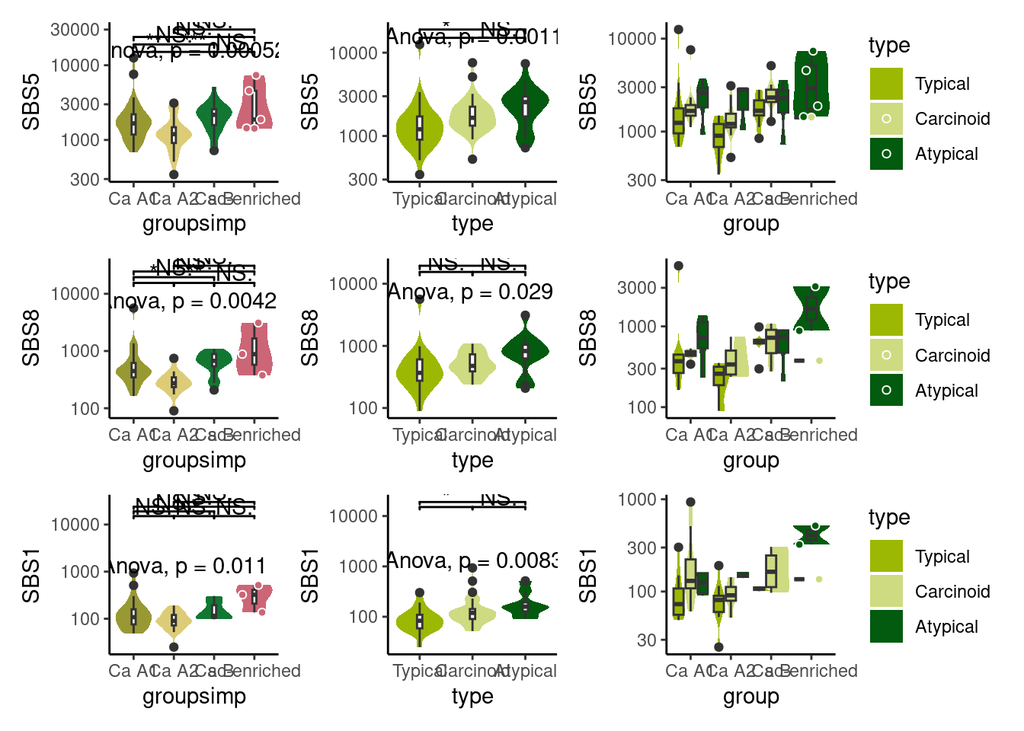

```r
sigs.groups.5p$groupsimp = factor(sigs.groups.5p$groupsimp,levels = c("Ca A1","Ca A2","Ca B","sc-enriched","LCNEC"))
sigs.groups.5p$type = factor(sigs.groups.5p$type,levels = c("Typical","Carcinoid","Atypical","LCNEC"))

ggSBS5 = ggplot(sigs.groups.5p %>% filter(groupsimp!="LCNEC",SBS5>0), aes(y=SBS5,x=groupsimp,fill=groupsimp)) +
  geom_violin(scale = "width",color=NA,show.legend = F)+ geom_boxplot(fill="white",width=0.1,show.legend = F) +
  geom_quasirandom(data = sigs.groups.5p %>% filter(groupsimp %in% c("sc-enriched")),col="white",shape=21,show.legend = F) +
  ggpubr::stat_compare_means(method = "anova") +
  geom_signif(comparisons = list(c("Ca A1", "Ca A2")), map_signif_level=TRUE,y_position = 4.1,test = "t.test")+
  geom_signif(comparisons = list(c("Ca A1", "Ca B")), map_signif_level=TRUE,y_position = 4.2,test = "t.test")+
  geom_signif(comparisons = list(c("Ca A1", "sc-enriched")), map_signif_level=TRUE,y_position = 4.3,test = "t.test")+
  geom_signif(comparisons = list(c("Ca A2", "Ca B")), map_signif_level=TRUE,y_position = 4.1,test = "t.test")+
  geom_signif(comparisons = list(c("Ca A2", "sc-enriched")), map_signif_level=TRUE,y_position = 4.4,test = "t.test")+
  geom_signif(comparisons = list(c("Ca B", "sc-enriched")), map_signif_level=TRUE,y_position = 4.1,test = "t.test")+
  theme_classic() + scale_fill_manual(values=c(arc4,type5) ) + scale_y_log10()

ggSBS8 = ggplot(sigs.groups.5p %>% filter(groupsimp!="LCNEC",SBS8>0), aes(y=SBS8,x=groupsimp,fill=groupsimp)) +
  geom_violin(scale = "width",color=NA,show.legend = F)+ geom_boxplot(fill="white",width=0.1,show.legend = F) +
  geom_quasirandom(data = sigs.groups.5p %>% filter(groupsimp %in% c("sc-enriched")),col="white",shape=21,show.legend = F) +
  ggpubr::stat_compare_means(method = "anova") +
  geom_signif(comparisons = list(c("Ca A1", "Ca A2")), map_signif_level=TRUE,y_position = 4.1,test = "t.test")+
  geom_signif(comparisons = list(c("Ca A1", "Ca B")), map_signif_level=TRUE,y_position = 4.2,test = "t.test")+
  geom_signif(comparisons = list(c("Ca A1", "sc-enriched")), map_signif_level=TRUE,y_position = 4.3,test = "t.test")+
  geom_signif(comparisons = list(c("Ca A2", "Ca B")), map_signif_level=TRUE,y_position = 4.1,test = "t.test")+
  geom_signif(comparisons = list(c("Ca A2", "sc-enriched")), map_signif_level=TRUE,y_position = 4.4,test = "t.test")+
  geom_signif(comparisons = list(c("Ca B", "sc-enriched")), map_signif_level=TRUE,y_position = 4.1,test = "t.test")+
  theme_classic() + scale_fill_manual(values=c(arc4,type5) ) + scale_y_log10()

ggSBS1 = ggplot(sigs.groups.5p %>% filter(groupsimp!="LCNEC",SBS1>0), aes(y=SBS1,x=groupsimp,fill=groupsimp)) +
  geom_violin(scale = "width",color=NA,show.legend = F)+ geom_boxplot(fill="white",width=0.1,show.legend = F) +
  geom_quasirandom(data = sigs.groups.5p %>% filter(groupsimp %in% c("sc-enriched")),col="white",shape=21,show.legend = F) +
  ggpubr::stat_compare_means(method = "anova") +
  geom_signif(comparisons = list(c("Ca A1", "Ca A2")), map_signif_level=TRUE,y_position = 4.1,test = "t.test")+
  geom_signif(comparisons = list(c("Ca A1", "Ca B")), map_signif_level=TRUE,y_position = 4.2,test = "t.test")+
  geom_signif(comparisons = list(c("Ca A1", "sc-enriched")), map_signif_level=TRUE,y_position = 4.3,test = "t.test")+
  geom_signif(comparisons = list(c("Ca A2", "Ca B")), map_signif_level=TRUE,y_position = 4.1,test = "t.test")+
  geom_signif(comparisons = list(c("Ca A2", "sc-enriched")), map_signif_level=TRUE,y_position = 4.4,test = "t.test")+
  geom_signif(comparisons = list(c("Ca B", "sc-enriched")), map_signif_level=TRUE,y_position = 4.1,test = "t.test")+
  theme_classic() + scale_fill_manual(values=c(arc4,type5) ) + scale_y_log10()

## by type
ggSBS5.ty = ggplot(sigs.groups.5p %>% filter(groupsimp!="LCNEC",SBS5>0), aes(y=SBS5,x=type,fill=type)) +
  geom_violin(scale = "width",color=NA,show.legend = F)+ geom_boxplot(fill="white",width=0.1,show.legend = F) +
  ggpubr::stat_compare_means(method = "anova") +
  geom_signif(comparisons = list(c("Typical", "Carcinoid")), map_signif_level=TRUE,y_position = 4.1,test = "t.test")+
  geom_signif(comparisons = list(c("Typical", "Atypical")), map_signif_level=TRUE,y_position = 4.2,test = "t.test")+
  geom_signif(comparisons = list(c("Carcinoid", "Atypical")), map_signif_level=TRUE,y_position = 4.1,test = "t.test")+
  theme_classic() + scale_fill_manual(values=c(arc4,type5) ) + scale_y_log10()

ggSBS8.ty = ggplot(sigs.groups.5p %>% filter(groupsimp!="LCNEC",SBS8>0), aes(y=SBS8,x=type,fill=type)) +
  geom_violin(scale = "width",color=NA,show.legend = F)+ geom_boxplot(fill="white",width=0.1,show.legend = F) +
  ggpubr::stat_compare_means(method = "anova") +
  geom_signif(comparisons = list(c("Typical", "Carcinoid")), map_signif_level=TRUE,y_position = 4.1,test = "t.test")+
  geom_signif(comparisons = list(c("Typical", "Atypical")), map_signif_level=TRUE,y_position = 4.2,test = "t.test")+
  geom_signif(comparisons = list(c("Carcinoid", "Atypical")), map_signif_level=TRUE,y_position = 4.1,test = "t.test")+
  theme_classic() + scale_fill_manual(values=c(arc4,type5) ) + scale_y_log10()

ggSBS1.ty = ggplot(sigs.groups.5p %>% filter(groupsimp!="LCNEC",SBS1>0), aes(y=SBS1,x=type,fill=type)) +
  geom_violin(scale = "width",color=NA,show.legend = F)+ geom_boxplot(fill="white",width=0.1,show.legend = F) +
  ggpubr::stat_compare_means(method = "anova") +
  geom_signif(comparisons = list(c("Typical", "Carcinoid")), map_signif_level=TRUE,y_position = 4.1,test = "t.test")+
  geom_signif(comparisons = list(c("Typical", "Atypical")), map_signif_level=TRUE,y_position = 4.2,test = "t.test")+
  geom_signif(comparisons = list(c("Carcinoid", "Atypical")), map_signif_level=TRUE,y_position = 4.1,test = "t.test")+
  theme_classic() + scale_fill_manual(values=c(arc4,type5) ) + scale_y_log10()

## by group and type
ggSBS5.gty = ggplot(sigs.groups.5p %>% filter(groupsimp!="LCNEC",SBS5>0), aes(y=SBS5,x=group,fill=type)) +
  geom_violin(scale="width",color=NA) + geom_boxplot(position = position_dodge(preserve = "single",width = 0.9),show.legend = F) +
  geom_quasirandom(data = sigs.groups.5p %>% filter(groupsimp %in% c("sc-enriched")),col="white",shape=21) +
  theme_classic() + scale_fill_manual(values=c(arc4,type5) ) + scale_y_log10()

ggSBS8.gty = ggplot(sigs.groups.5p %>% filter(groupsimp!="LCNEC",SBS8>0), aes(y=SBS8,x=group,fill=type)) +
  geom_violin(scale="width",color=NA) + geom_boxplot(position = position_dodge(preserve = "single",width = 0.9),show.legend = F) +
  geom_quasirandom(data = sigs.groups.5p %>% filter(groupsimp %in% c("sc-enriched")),col="white",shape=21) +
  theme_classic() + scale_fill_manual(values=c(arc4,type5) ) + scale_y_log10()

ggSBS1.gty = ggplot(sigs.groups.5p %>% filter(groupsimp!="LCNEC",SBS1>0), aes(y=SBS1,x=group,fill=type)) +
  geom_violin(scale="width",color=NA) + geom_boxplot(position = position_dodge(preserve = "single",width = 0.9),show.legend = F) +
  geom_quasirandom(data = sigs.groups.5p %>% filter(groupsimp %in% c("sc-enriched")),col="white",shape=21,show.legend = F) +
  theme_classic() + scale_fill_manual(values=c(arc4,type5) ) + scale_y_log10()


ggSBS5+ggSBS5.ty+ggSBS5.gty  +
  ggSBS8+ggSBS8.ty+ggSBS8.gty  +
  ggSBS1+ggSBS1.ty + ggSBS1.gty
```

### ID

#### presence / absence or burden in present

ID1 (Slippage during DNA replication) is less frequent in LCNEC

```r
table(sigs.groups.5p$ID1>0,sigs.groups.5p$groupsimp)
```

```
##
##         Ca A1 Ca A2 Ca B sc-enriched LCNEC
##   FALSE     5     3    0           0     5
##   TRUE     39    26   24           5     4
```

```r
fisher.test(table(sigs.groups.5p$ID1>0,sigs.groups.5p$groupsimp)) # less in LCNEC
```

```
##
##  Fisher's Exact Test for Count Data
##
## data:  table(sigs.groups.5p$ID1 > 0, sigs.groups.5p$groupsimp)
## p-value = 0.00254
## alternative hypothesis: two.sided
```

```r
fisher.test(table(sigs.groups.5p$ID1>0,sigs.groups.5p$groupsimp)[,-4]) # no effect
```

```
##
##  Fisher's Exact Test for Count Data
##
## data:  table(sigs.groups.5p$ID1 > 0, sigs.groups.5p$groupsimp)[, -4]
## p-value = 0.001145
## alternative hypothesis: two.sided
```

```r
table(sigs.groups.5p$ID1>0,sigs.groups.5p$type)
```

```
##
##         Typical Carcinoid Atypical LCNEC
##   FALSE       4         4        0     5
##   TRUE       34        40       20     4
```

```r
fisher.test(table(sigs.groups.5p$ID1>0,sigs.groups.5p$type)) # less in LCNEC
```

```
##
##  Fisher's Exact Test for Count Data
##
## data:  table(sigs.groups.5p$ID1 > 0, sigs.groups.5p$type)
## p-value = 0.001755
## alternative hypothesis: two.sided
```

```r
fisher.test(table(sigs.groups.5p$ID1>0,sigs.groups.5p$type)[,-3]) # no effect
```

```
##
##  Fisher's Exact Test for Count Data
##
## data:  table(sigs.groups.5p$ID1 > 0, sigs.groups.5p$type)[, -3]
## p-value = 0.005622
## alternative hypothesis: two.sided
```

ID2 (Slippage during DNA replication) is more frequent in Ca B, SC, and LCNEC, and in atypical carcinoids

```r
table(sigs.groups.5p$ID2>0,sigs.groups.5p$groupsimp) #less in A1 and A2
```

```
##
##         Ca A1 Ca A2 Ca B sc-enriched LCNEC
##   FALSE    34    23   10           2     5
##   TRUE     10     6   14           3     4
```

```r
fisher.test(table(sigs.groups.5p$ID2>0,sigs.groups.5p$groupsimp)) #
```

```
##
##  Fisher's Exact Test for Count Data
##
## data:  table(sigs.groups.5p$ID2 > 0, sigs.groups.5p$groupsimp)
## p-value = 0.008478
## alternative hypothesis: two.sided
```

```r
fisher.test(table(sigs.groups.5p$ID2>0,sigs.groups.5p$groupsimp)[,-4]) # no effect
```

```
##
##  Fisher's Exact Test for Count Data
##
## data:  table(sigs.groups.5p$ID2 > 0, sigs.groups.5p$groupsimp)[, -4]
## p-value = 0.008768
## alternative hypothesis: two.sided
```

```r
table(sigs.groups.5p$ID2>0,sigs.groups.5p$type) #less in typical
```

```
##
##         Typical Carcinoid Atypical LCNEC
##   FALSE      31        28       10     5
##   TRUE        7        16       10     4
```

```r
fisher.test(table(sigs.groups.5p$ID2>0,sigs.groups.5p$type))
```

```
##
##  Fisher's Exact Test for Count Data
##
## data:  table(sigs.groups.5p$ID2 > 0, sigs.groups.5p$type)
## p-value = 0.06137
## alternative hypothesis: two.sided
```

```r
fisher.test(table(sigs.groups.5p$ID2>0,sigs.groups.5p$type)[,-3])
```

```
##
##  Fisher's Exact Test for Count Data
##
## data:  table(sigs.groups.5p$ID2 > 0, sigs.groups.5p$type)[, -3]
## p-value = 0.1193
## alternative hypothesis: two.sided
```

```r
table(sigs.groups.5p$ID2[sigs.groups.5p$type=="Atypical"]>0,sigs.groups.5p$groupsimp[sigs.groups.5p$type=="Atypical"]) #never observed in A2 and in half A1 but in almost all B
```

```
##
##         Ca A1 Ca A2 Ca B sc-enriched LCNEC
##   FALSE     5     3    1           1     0
##   TRUE      4     0    3           3     0
```

```r
table(sigs.groups.5p$ID2[sigs.groups.5p$type=="Carcinoid"]>0,sigs.groups.5p$groupsimp[sigs.groups.5p$type=="Carcinoid"]) #In less than half A1 and A2 but in more than half of B
```

```
##
##         Ca A1 Ca A2 Ca B sc-enriched LCNEC
##   FALSE    13     9    5           1     0
##   TRUE      4     6    6           0     0
```

```r
table(sigs.groups.5p$ID2[sigs.groups.5p$type=="Typical"]>0,sigs.groups.5p$groupsimp[sigs.groups.5p$type=="Typical"]) #never observed in A2 and rare in A1 but in more than half of B
```

```
##
##         Ca A1 Ca A2 Ca B sc-enriched LCNEC
##   FALSE    16    11    4           0     0
##   TRUE      2     0    5           0     0
```

```r
fisher.test(table(sigs.groups.5p$ID2[sigs.groups.5p$type=="Atypical"]>0,sigs.groups.5p$groupsimp[sigs.groups.5p$type=="Atypical"])) #not signif
```

```
##
##  Fisher's Exact Test for Count Data
##
## data:  table(sigs.groups.5p$ID2[sigs.groups.5p$type == "Atypical"] > 0, sigs.groups.5p$groupsimp[sigs.groups.5p$type == "Atypical"])
## p-value = 0.2525
## alternative hypothesis: two.sided
```

```r
fisher.test(table(sigs.groups.5p$ID2[sigs.groups.5p$type=="Typical"]>0,sigs.groups.5p$groupsimp[sigs.groups.5p$type=="Typical"])) #signif
```

```
##
##  Fisher's Exact Test for Count Data
##
## data:  table(sigs.groups.5p$ID2[sigs.groups.5p$type == "Typical"] > 0, sigs.groups.5p$groupsimp[sigs.groups.5p$type == "Typical"])
## p-value = 0.004605
## alternative hypothesis: two.sided
```

```r
fisher.test(table(sigs.groups.5p$ID2[sigs.groups.5p$type=="Carcinoid"]>0,sigs.groups.5p$groupsimp[sigs.groups.5p$type=="Carcinoid"])) #not signif
```

```
##
##  Fisher's Exact Test for Count Data
##
## data:  table(sigs.groups.5p$ID2[sigs.groups.5p$type == "Carcinoid"] > 0, sigs.groups.5p$groupsimp[sigs.groups.5p$type == "Carcinoid"])
## p-value = 0.3606
## alternative hypothesis: two.sided
```

ID3 (associated but not exclusive of tobacco smoking), in all LCNEC samples and little bit more frequent in Ca B and SC

```r
table(sigs.groups.5p$ID3>0,sigs.groups.5p$groupsimp) # rare in A1 and A2, frequent in B and SC, in all LCNEC
```

```
##
##         Ca A1 Ca A2 Ca B sc-enriched LCNEC
##   FALSE    31    22   10           3     0
##   TRUE     13     7   14           2     9
```

```r
fisher.test(table(sigs.groups.5p$ID3>0,sigs.groups.5p$groupsimp)) # a bit more in LCNEC
```

```
##
##  Fisher's Exact Test for Count Data
##
## data:  table(sigs.groups.5p$ID3 > 0, sigs.groups.5p$groupsimp)
## p-value = 8.322e-05
## alternative hypothesis: two.sided
```

```r
fisher.test(table(sigs.groups.5p$ID3>0,sigs.groups.5p$groupsimp)[,-4])#borderline more in SC
```

```
##
##  Fisher's Exact Test for Count Data
##
## data:  table(sigs.groups.5p$ID3 > 0, sigs.groups.5p$groupsimp)[, -4]
## p-value = 3.8e-05
## alternative hypothesis: two.sided
```

```r
table(sigs.groups.5p$ID3>0,sigs.groups.5p$type) #more frequent in LCNEC and Typical
```

```
##
##         Typical Carcinoid Atypical LCNEC
##   FALSE      19        33       14     0
##   TRUE       19        11        6     9
```

```r
fisher.test(table(sigs.groups.5p$ID3>0,sigs.groups.5p$type)) # a bit more in LCNEC
```

```
##
##  Fisher's Exact Test for Count Data
##
## data:  table(sigs.groups.5p$ID3 > 0, sigs.groups.5p$type)
## p-value = 9.541e-05
## alternative hypothesis: two.sided
```

```r
fisher.test(table(sigs.groups.5p$ID3>0,sigs.groups.5p$type)[,-3])#borderline more in SC
```

```
##
##  Fisher's Exact Test for Count Data
##
## data:  table(sigs.groups.5p$ID3 > 0, sigs.groups.5p$type)[, -3]
## p-value = 3.586e-05
## alternative hypothesis: two.sided
```

ID5 (age associated) is not asssociated with a particular group or type

```r
table(sigs.groups.5p$ID5>0,sigs.groups.5p$groupsimp) # seem more frequent in A1
```

```
##
##         Ca A1 Ca A2 Ca B sc-enriched LCNEC
##   FALSE    16    12   15           3     6
##   TRUE     28    17    9           2     3
```

```r
fisher.test(table(sigs.groups.5p$ID5>0,sigs.groups.5p$groupsimp)) # not signif
```

```
##
##  Fisher's Exact Test for Count Data
##
## data:  table(sigs.groups.5p$ID5 > 0, sigs.groups.5p$groupsimp)
## p-value = 0.1694
## alternative hypothesis: two.sided
```

```r
fisher.test(table(sigs.groups.5p$ID5>0,sigs.groups.5p$groupsimp)[,-4]) # not signif
```

```
##
##  Fisher's Exact Test for Count Data
##
## data:  table(sigs.groups.5p$ID5 > 0, sigs.groups.5p$groupsimp)[, -4]
## p-value = 0.1108
## alternative hypothesis: two.sided
```

```r
table(sigs.groups.5p$ID5>0,sigs.groups.5p$type)
```

```
##
##         Typical Carcinoid Atypical LCNEC
##   FALSE      16        20       10     6
##   TRUE       22        24       10     3
```

```r
fisher.test(table(sigs.groups.5p$ID5>0,sigs.groups.5p$type)) # not signif
```

```
##
##  Fisher's Exact Test for Count Data
##
## data:  table(sigs.groups.5p$ID5 > 0, sigs.groups.5p$type)
## p-value = 0.5989
## alternative hypothesis: two.sided
```

```r
fisher.test(table(sigs.groups.5p$ID5>0,sigs.groups.5p$type)[,-3]) # not signif
```

```
##
##  Fisher's Exact Test for Count Data
##
## data:  table(sigs.groups.5p$ID5 > 0, sigs.groups.5p$type)[, -3]
## p-value = 0.4374
## alternative hypothesis: two.sided
```

ID8 (age or radiation), not associated with any group or type

```r
table(sigs.groups.5p$ID8>0,sigs.groups.5p$groupsimp)
```

```
##
##         Ca A1 Ca A2 Ca B sc-enriched LCNEC
##   FALSE    30    21   16           4     7
##   TRUE     14     8    8           1     2
```

```r
fisher.test(table(sigs.groups.5p$ID8>0,sigs.groups.5p$groupsimp)) # not signif
```

```
##
##  Fisher's Exact Test for Count Data
##
## data:  table(sigs.groups.5p$ID8 > 0, sigs.groups.5p$groupsimp)
## p-value = 0.9801
## alternative hypothesis: two.sided
```

```r
fisher.test(table(sigs.groups.5p$ID8>0,sigs.groups.5p$groupsimp)[,-4]) #once in A1 and SC, borderline signif
```

```
##
##  Fisher's Exact Test for Count Data
##
## data:  table(sigs.groups.5p$ID8 > 0, sigs.groups.5p$groupsimp)[, -4]
## p-value = 0.9458
## alternative hypothesis: two.sided
```

```r
table(sigs.groups.5p$ID8>0,sigs.groups.5p$type)
```

```
##
##         Typical Carcinoid Atypical LCNEC
##   FALSE      22        33       16     7
##   TRUE       16        11        4     2
```

```r
fisher.test(table(sigs.groups.5p$ID8>0,sigs.groups.5p$type)) # not signif
```

```
##
##  Fisher's Exact Test for Count Data
##
## data:  table(sigs.groups.5p$ID8 > 0, sigs.groups.5p$type)
## p-value = 0.252
## alternative hypothesis: two.sided
```

```r
fisher.test(table(sigs.groups.5p$ID8>0,sigs.groups.5p$type)[,-3]) # not signif
```

```
##
##  Fisher's Exact Test for Count Data
##
## data:  table(sigs.groups.5p$ID8 > 0, sigs.groups.5p$type)[, -3]
## p-value = 0.219
## alternative hypothesis: two.sided
```

ID9 (unknown etiology), slightly more frequent in Atypical carcinoids

```r
table(sigs.groups.5p$ID9>0,sigs.groups.5p$groupsimp) # seem less frequent in A2 and LCNEC
```

```
##
##         Ca A1 Ca A2 Ca B sc-enriched LCNEC
##   FALSE    22    19   10           2     8
##   TRUE     22    10   14           3     1
```

```r
fisher.test(table(sigs.groups.5p$ID9>0,sigs.groups.5p$groupsimp)) # not signif
```

```
##
##  Fisher's Exact Test for Count Data
##
## data:  table(sigs.groups.5p$ID9 > 0, sigs.groups.5p$groupsimp)
## p-value = 0.08163
## alternative hypothesis: two.sided
```

```r
fisher.test(table(sigs.groups.5p$ID9>0,sigs.groups.5p$groupsimp)[,-4]) #only reported in a A2 but not signif
```

```
##
##  Fisher's Exact Test for Count Data
##
## data:  table(sigs.groups.5p$ID9 > 0, sigs.groups.5p$groupsimp)[, -4]
## p-value = 0.05375
## alternative hypothesis: two.sided
```

```r
table(sigs.groups.5p$ID9>0,sigs.groups.5p$type) # seem less frequent in LCNEC than in Atypical carcinoids
```

```
##
##         Typical Carcinoid Atypical LCNEC
##   FALSE      26        19        8     8
##   TRUE       12        25       12     1
```

```r
fisher.test(table(sigs.groups.5p$ID9>0,sigs.groups.5p$type))
```

```
##
##  Fisher's Exact Test for Count Data
##
## data:  table(sigs.groups.5p$ID9 > 0, sigs.groups.5p$type)
## p-value = 0.009533
## alternative hypothesis: two.sided
```

```r
fisher.test(table(sigs.groups.5p$ID9>0,sigs.groups.5p$type)[,-3])
```

```
##
##  Fisher's Exact Test for Count Data
##
## data:  table(sigs.groups.5p$ID9 > 0, sigs.groups.5p$type)[, -3]
## p-value = 0.01154
## alternative hypothesis: two.sided
```

#### Differences in burden among samples where present

We first use linear regression to test for an effect of groups and type, ignoring signatures present in 3 or less samples. We find some differences among groups

```r
lm1_GTAS = lm(log10(ID1)~group+type+age+sex,data = sigs.groups.5p %>% filter(groupsimp!="LCNEC",ID1!=0)) # 94 samples
lm1_GTA  = lm(log10(ID1)~group+type+age,data = sigs.groups.5p %>% filter(groupsimp!="LCNEC",ID1!=0))
lm1_GT   = lm(log10(ID1)~group+type,data = sigs.groups.5p %>% filter(groupsimp!="LCNEC",ID1!=0))
lm1_G    = lm(log10(ID1)~group,data = sigs.groups.5p %>% filter(groupsimp!="LCNEC",ID1!=0))
anova(lm1_GTAS) # group and type signif
```

```
## Analysis of Variance Table
##
## Response: log10(ID1)
##           Df Sum Sq Mean Sq F value    Pr(>F)
## group      3 1.6197 0.53991  4.8125 0.0038069 **
## type       2 2.1330 1.06652  9.5064 0.0001862 ***
## age        1 0.0007 0.00070  0.0063 0.9370755
## sex        1 0.0468 0.04679  0.4171 0.5201270
## Residuals 86 9.6483 0.11219
## ---
## Signif. codes:  0 '***' 0.001 '**' 0.01 '*' 0.05 '.' 0.1 ' ' 1
```

```r
anova(lm1_GTAS,lm1_GTA) # not different
```

```
## Analysis of Variance Table
##
## Model 1: log10(ID1) ~ group + type + age + sex
## Model 2: log10(ID1) ~ group + type + age
##   Res.Df    RSS Df Sum of Sq      F Pr(>F)
## 1     86 9.6483
## 2     87 9.6951 -1  -0.04679 0.4171 0.5201
```

```r
anova(lm1_GTA,lm1_GT) # not different
```

```
## Analysis of Variance Table
##
## Model 1: log10(ID1) ~ group + type + age
## Model 2: log10(ID1) ~ group + type
##   Res.Df    RSS Df   Sum of Sq      F Pr(>F)
## 1     87 9.6951
## 2     88 9.6958 -1 -0.00070332 0.0063 0.9369
```

```r
anova(lm1_GT,lm1_G) # different
```

```
## Analysis of Variance Table
##
## Model 1: log10(ID1) ~ group + type
## Model 2: log10(ID1) ~ group
##   Res.Df     RSS Df Sum of Sq      F    Pr(>F)
## 1     88  9.6958
## 2     90 11.8289 -2    -2.133 9.6798 0.0001586 ***
## ---
## Signif. codes:  0 '***' 0.001 '**' 0.01 '*' 0.05 '.' 0.1 ' ' 1
```

```r
anova(lm1_GTAS,lm1_GT) # not different => best model is GT
```

```
## Analysis of Variance Table
##
## Model 1: log10(ID1) ~ group + type + age + sex
## Model 2: log10(ID1) ~ group + type
##   Res.Df    RSS Df Sum of Sq      F Pr(>F)
## 1     86 9.6483
## 2     88 9.6958 -2 -0.047493 0.2117 0.8097
```

```r
summary(lm1_GTAS)
```

```
##
## Call:
## lm(formula = log10(ID1) ~ group + type + age + sex, data = sigs.groups.5p %>%
##     filter(groupsimp != "LCNEC", ID1 != 0))
##
## Residuals:
##      Min       1Q   Median       3Q      Max
## -0.89890 -0.20798 -0.01618  0.18342  0.99756
##
## Coefficients:
##                   Estimate Std. Error t value Pr(>|t|)
## (Intercept)      1.0445035  0.1893995   5.515 3.61e-07 ***
## groupCa A2       0.0165803  0.0990115   0.167 0.867402
## groupCa B        0.0001289  0.0969831   0.001 0.998943
## groupsc-enriched 0.4240426  0.1679362   2.525 0.013404 *
## typeCarcinoid    0.2896293  0.0784555   3.692 0.000390 ***
## typeAtypical     0.3709036  0.1008940   3.676 0.000411 ***
## age              0.0004988  0.0027623   0.181 0.857126
## sexM             0.0520044  0.0805268   0.646 0.520127
## ---
## Signif. codes:  0 '***' 0.001 '**' 0.01 '*' 0.05 '.' 0.1 ' ' 1
##
## Residual standard error: 0.3349 on 86 degrees of freedom
## Multiple R-squared:  0.2826, Adjusted R-squared:  0.2242
## F-statistic: 4.839 on 7 and 86 DF,  p-value: 0.0001244
```

```r
summary(lm1_GT) #more in SC, less in typical
```

```
##
## Call:
## lm(formula = log10(ID1) ~ group + type, data = sigs.groups.5p %>%
##     filter(groupsimp != "LCNEC", ID1 != 0))
##
## Residuals:
##      Min       1Q   Median       3Q      Max
## -0.88816 -0.20651 -0.00118  0.19975  0.99114
##
## Coefficients:
##                  Estimate Std. Error t value Pr(>|t|)
## (Intercept)       1.08642    0.07076  15.353  < 2e-16 ***
## groupCa A2        0.01351    0.08468   0.160 0.873587
## groupCa B         0.02788    0.08631   0.323 0.747452
## groupsc-enriched  0.42896    0.16594   2.585 0.011385 *
## typeCarcinoid     0.28605    0.07755   3.688 0.000390 ***
## typeAtypical      0.37592    0.09969   3.771 0.000294 ***
## ---
## Signif. codes:  0 '***' 0.001 '**' 0.01 '*' 0.05 '.' 0.1 ' ' 1
##
## Residual standard error: 0.3319 on 88 degrees of freedom
## Multiple R-squared:  0.279,  Adjusted R-squared:  0.2381
## F-statistic: 6.812 on 5 and 88 DF,  p-value: 2.056e-05
```

```r
lm2_GTAS = lm(log10(ID2)~group+type+age+sex,data = sigs.groups.5p %>% filter(groupsimp!="LCNEC",ID2!=0)) # 33 samples
lm2_GTA  = lm(log10(ID2)~group+type+age,data = sigs.groups.5p %>% filter(groupsimp!="LCNEC",ID2!=0))
lm2_GA   = lm(log10(ID2)~group+age,data = sigs.groups.5p %>% filter(groupsimp!="LCNEC",ID2!=0))
lm2_G    = lm(log10(ID2)~group,data = sigs.groups.5p %>% filter(groupsimp!="LCNEC",ID2!=0))
anova(lm2_GTAS) # group and age signif
```

```
## Analysis of Variance Table
##
## Response: log10(ID2)
##           Df  Sum Sq Mean Sq F value   Pr(>F)
## group      3 1.03324 0.34441  5.1294 0.006673 **
## type       2 0.28782 0.14391  2.1433 0.138325
## age        1 0.35862 0.35862  5.3409 0.029362 *
## sex        1 0.09466 0.09466  1.4097 0.246265
## Residuals 25 1.67864 0.06715
## ---
## Signif. codes:  0 '***' 0.001 '**' 0.01 '*' 0.05 '.' 0.1 ' ' 1
```

```r
anova(lm2_GTAS,lm2_GTA) # not different
```

```
## Analysis of Variance Table
##
## Model 1: log10(ID2) ~ group + type + age + sex
## Model 2: log10(ID2) ~ group + type + age
##   Res.Df    RSS Df Sum of Sq      F Pr(>F)
## 1     25 1.6786
## 2     26 1.7733 -1 -0.094655 1.4097 0.2463
```

```r
anova(lm2_GTA,lm2_GA) # not different
```

```
## Analysis of Variance Table
##
## Model 1: log10(ID2) ~ group + type + age
## Model 2: log10(ID2) ~ group + age
##   Res.Df    RSS Df Sum of Sq      F Pr(>F)
## 1     26 1.7733
## 2     28 2.2156 -2  -0.44232 3.2427 0.0553 .
## ---
## Signif. codes:  0 '***' 0.001 '**' 0.01 '*' 0.05 '.' 0.1 ' ' 1
```

```r
anova(lm2_GA,lm2_G) # not different
```

```
## Analysis of Variance Table
##
## Model 1: log10(ID2) ~ group + age
## Model 2: log10(ID2) ~ group
##   Res.Df    RSS Df Sum of Sq      F Pr(>F)
## 1     28 2.2156
## 2     29 2.4197 -1  -0.20411 2.5795 0.1195
```

```r
anova(lm2_GTAS,lm2_GA) # not different => best model is GA
```

```
## Analysis of Variance Table
##
## Model 1: log10(ID2) ~ group + type + age + sex
## Model 2: log10(ID2) ~ group + age
##   Res.Df    RSS Df Sum of Sq      F  Pr(>F)
## 1     25 1.6786
## 2     28 2.2156 -3  -0.53698 2.6657 0.06964 .
## ---
## Signif. codes:  0 '***' 0.001 '**' 0.01 '*' 0.05 '.' 0.1 ' ' 1
```

```r
summary(lm2_GTAS)
```

```
##
## Call:
## lm(formula = log10(ID2) ~ group + type + age + sex, data = sigs.groups.5p %>%
##     filter(groupsimp != "LCNEC", ID2 != 0))
##
## Residuals:
##      Min       1Q   Median       3Q      Max
## -0.50767 -0.14121 -0.00616  0.11144  0.69438
##
## Coefficients:
##                   Estimate Std. Error t value Pr(>|t|)
## (Intercept)       1.740014   0.280162   6.211  1.7e-06 ***
## groupCa A2       -0.767077   0.183131  -4.189 0.000305 ***
## groupCa B        -0.030638   0.134566  -0.228 0.821747
## groupsc-enriched -0.120056   0.208217  -0.577 0.569373
## typeCarcinoid     0.305185   0.133417   2.287 0.030901 *
## typeAtypical      0.251611   0.146818   1.714 0.098948 .
## age              -0.009988   0.004400  -2.270 0.032083 *
## sexM             -0.136903   0.115305  -1.187 0.246265
## ---
## Signif. codes:  0 '***' 0.001 '**' 0.01 '*' 0.05 '.' 0.1 ' ' 1
##
## Residual standard error: 0.2591 on 25 degrees of freedom
## Multiple R-squared:  0.5139, Adjusted R-squared:  0.3777
## F-statistic: 3.775 on 7 and 25 DF,  p-value: 0.00631
```

```r
summary(lm2_GA) #less in A2, age not signif
```

```
##
## Call:
## lm(formula = log10(ID2) ~ group + age, data = sigs.groups.5p %>%
##     filter(groupsimp != "LCNEC", ID2 != 0))
##
## Residuals:
##      Min       1Q   Median       3Q      Max
## -0.47779 -0.21637 -0.05187  0.09482  0.78492
##
## Coefficients:
##                   Estimate Std. Error t value Pr(>|t|)
## (Intercept)       1.791157   0.299522   5.980 1.93e-06 ***
## groupCa A2       -0.662990   0.174690  -3.795 0.000726 ***
## groupCa B        -0.174713   0.118544  -1.474 0.151684
## groupsc-enriched -0.136892   0.193954  -0.706 0.486147
## age              -0.007433   0.004628  -1.606 0.119476
## ---
## Signif. codes:  0 '***' 0.001 '**' 0.01 '*' 0.05 '.' 0.1 ' ' 1
##
## Residual standard error: 0.2813 on 28 degrees of freedom
## Multiple R-squared:  0.3583, Adjusted R-squared:  0.2667
## F-statistic: 3.909 on 4 and 28 DF,  p-value: 0.01207
```

```r
lm3_GTAS = lm(log10(ID3)~group+type+age+sex,data = sigs.groups.5p %>% filter(groupsimp!="LCNEC",ID3!=0)) # 94 samples
lm3_GTA  = lm(log10(ID3)~group+type+age,data = sigs.groups.5p %>% filter(groupsimp!="LCNEC",ID3!=0))
lm3_TA   = lm(log10(ID3)~type+age,data = sigs.groups.5p %>% filter(groupsimp!="LCNEC",ID3!=0))
lm3_T    = lm(log10(ID3)~type,data = sigs.groups.5p %>% filter(groupsimp!="LCNEC",ID3!=0))
lm3_    = lm(log10(ID3)~1,data = sigs.groups.5p %>% filter(groupsimp!="LCNEC",ID3!=0))
anova(lm3_GTAS) # none signif
```

```
## Analysis of Variance Table
##
## Response: log10(ID3)
##           Df  Sum Sq  Mean Sq F value Pr(>F)
## group      3 0.05148 0.017160  0.2035 0.8931
## type       2 0.31030 0.155150  1.8401 0.1775
## age        1 0.05259 0.052594  0.6238 0.4363
## sex        1 0.13388 0.133877  1.5878 0.2180
## Residuals 28 2.36088 0.084317
```

```r
anova(lm3_GTAS,lm3_GTA) # not different
```

```
## Analysis of Variance Table
##
## Model 1: log10(ID3) ~ group + type + age + sex
## Model 2: log10(ID3) ~ group + type + age
##   Res.Df    RSS Df Sum of Sq      F Pr(>F)
## 1     28 2.3609
## 2     29 2.4947 -1  -0.13388 1.5878  0.218
```

```r
anova(lm3_GTA,lm3_TA) # not different
```

```
## Analysis of Variance Table
##
## Model 1: log10(ID3) ~ group + type + age
## Model 2: log10(ID3) ~ type + age
##   Res.Df    RSS Df Sum of Sq      F Pr(>F)
## 1     29 2.4947
## 2     32 2.5930 -3 -0.098274 0.3808 0.7676
```

```r
anova(lm3_TA,lm3_T) # not different
```

```
## Analysis of Variance Table
##
## Model 1: log10(ID3) ~ type + age
## Model 2: log10(ID3) ~ type
##   Res.Df    RSS Df Sum of Sq      F Pr(>F)
## 1     32 2.5930
## 2     33 2.6411 -1 -0.048107 0.5937 0.4467
```

```r
anova(lm3_GTAS,lm3_) # not different => best model is null
```

```
## Analysis of Variance Table
##
## Model 1: log10(ID3) ~ group + type + age + sex
## Model 2: log10(ID3) ~ 1
##   Res.Df    RSS Df Sum of Sq      F Pr(>F)
## 1     28 2.3609
## 2     35 2.9091 -7  -0.54825 0.9289 0.4999
```

```r
summary(lm3_GTAS)
```

```
##
## Call:
## lm(formula = log10(ID3) ~ group + type + age + sex, data = sigs.groups.5p %>%
##     filter(groupsimp != "LCNEC", ID3 != 0))
##
## Residuals:
##      Min       1Q   Median       3Q      Max
## -0.63172 -0.15584  0.00914  0.11883  0.85666
##
## Coefficients:
##                   Estimate Std. Error t value Pr(>|t|)
## (Intercept)       1.052540   0.378713   2.779  0.00962 **
## groupCa A2        0.027062   0.165393   0.164  0.87120
## groupCa B        -0.076825   0.129266  -0.594  0.55707
## groupsc-enriched -0.231578   0.227539  -1.018  0.31751
## typeCarcinoid     0.143028   0.116431   1.228  0.22951
## typeAtypical      0.155509   0.157335   0.988  0.33142
## age               0.005812   0.005304   1.096  0.28250
## sexM              0.143451   0.113844   1.260  0.21804
## ---
## Signif. codes:  0 '***' 0.001 '**' 0.01 '*' 0.05 '.' 0.1 ' ' 1
##
## Residual standard error: 0.2904 on 28 degrees of freedom
## Multiple R-squared:  0.1885, Adjusted R-squared:  -0.01443
## F-statistic: 0.9289 on 7 and 28 DF,  p-value: 0.4999
```

```r
summary(lm3_) #nothing signif
```

```
##
## Call:
## lm(formula = log10(ID3) ~ 1, data = sigs.groups.5p %>% filter(groupsimp !=
##     "LCNEC", ID3 != 0))
##
## Residuals:
##      Min       1Q   Median       3Q      Max
## -0.68021 -0.13180 -0.04107  0.16251  0.96324
##
## Coefficients:
##             Estimate Std. Error t value Pr(>|t|)
## (Intercept)  1.52531    0.04805   31.74   <2e-16 ***
## ---
## Signif. codes:  0 '***' 0.001 '**' 0.01 '*' 0.05 '.' 0.1 ' ' 1
##
## Residual standard error: 0.2883 on 35 degrees of freedom
```

```r
lm5_GTAS = lm(log10(ID5)~group+type+age+sex,data = sigs.groups.5p %>% filter(groupsimp!="LCNEC",ID5!=0))
lm5_GTA  = lm(log10(ID5)~group+type+age,data = sigs.groups.5p %>% filter(groupsimp!="LCNEC",ID5!=0))
lm5_GT   = lm(log10(ID5)~group+type,data = sigs.groups.5p %>% filter(groupsimp!="LCNEC",ID5!=0))
lm5_T    = lm(log10(ID5)~type,data = sigs.groups.5p %>% filter(groupsimp!="LCNEC",ID5!=0))
anova(lm5_GTAS) # type signif
```

```
## Analysis of Variance Table
##
## Response: log10(ID5)
##           Df  Sum Sq Mean Sq F value   Pr(>F)
## group      3 0.24561 0.08187  1.3588 0.266637
## type       2 0.80460 0.40230  6.6768 0.002765 **
## age        1 0.00170 0.00170  0.0282 0.867396
## sex        1 0.00000 0.00000  0.0000 0.998742
## Residuals 48 2.89219 0.06025
## ---
## Signif. codes:  0 '***' 0.001 '**' 0.01 '*' 0.05 '.' 0.1 ' ' 1
```

```r
anova(lm5_GTAS,lm5_GTA) # not different
```

```
## Analysis of Variance Table
##
## Model 1: log10(ID5) ~ group + type + age + sex
## Model 2: log10(ID5) ~ group + type + age
##   Res.Df    RSS Df   Sum of Sq  F Pr(>F)
## 1     48 2.8922
## 2     49 2.8922 -1 -1.5134e-07  0 0.9987
```

```r
anova(lm5_GTA,lm5_GT) # different
```

```
## Analysis of Variance Table
##
## Model 1: log10(ID5) ~ group + type + age
## Model 2: log10(ID5) ~ group + type
##   Res.Df    RSS Df  Sum of Sq      F Pr(>F)
## 1     49 2.8922
## 2     50 2.8939 -1 -0.0016978 0.0288  0.866
```

```r
anova(lm5_GT,lm5_T) # not signif
```

```
## Analysis of Variance Table
##
## Model 1: log10(ID5) ~ group + type
## Model 2: log10(ID5) ~ type
##   Res.Df    RSS Df Sum of Sq      F Pr(>F)
## 1     50 2.8939
## 2     53 3.1534 -3  -0.25946 1.4943 0.2274
```

```r
anova(lm5_GTAS,lm5_T) # not different => best model is T
```

```
## Analysis of Variance Table
##
## Model 1: log10(ID5) ~ group + type + age + sex
## Model 2: log10(ID5) ~ type
##   Res.Df    RSS Df Sum of Sq      F Pr(>F)
## 1     48 2.8922
## 2     53 3.1534 -5  -0.26116 0.8669 0.5103
```

```r
summary(lm5_GTAS)
```

```
##
## Call:
## lm(formula = log10(ID5) ~ group + type + age + sex, data = sigs.groups.5p %>%
##     filter(groupsimp != "LCNEC", ID5 != 0))
##
## Residuals:
##      Min       1Q   Median       3Q      Max
## -0.61382 -0.12962 -0.00279  0.10218  0.77620
##
## Coefficients:
##                    Estimate Std. Error t value Pr(>|t|)
## (Intercept)       1.5154335  0.2019747   7.503 1.25e-09 ***
## groupCa A2       -0.1408459  0.0958108  -1.470  0.14808
## groupCa B        -0.0077019  0.1011811  -0.076  0.93964
## groupsc-enriched -0.0725223  0.1848060  -0.392  0.69648
## typeCarcinoid     0.2150056  0.0745669   2.883  0.00587 **
## typeAtypical      0.3156644  0.0981605   3.216  0.00233 **
## age               0.0005155  0.0030706   0.168  0.86739
## sexM              0.0001172  0.0739606   0.002  0.99874
## ---
## Signif. codes:  0 '***' 0.001 '**' 0.01 '*' 0.05 '.' 0.1 ' ' 1
##
## Residual standard error: 0.2455 on 48 degrees of freedom
## Multiple R-squared:  0.2667, Adjusted R-squared:  0.1598
## F-statistic: 2.494 on 7 and 48 DF,  p-value: 0.02868
```

```r
summary(lm5_T) #less in typical
```

```
##
## Call:
## lm(formula = log10(ID5) ~ type, data = sigs.groups.5p %>% filter(groupsimp !=
##     "LCNEC", ID5 != 0))
##
## Residuals:
##      Min       1Q   Median       3Q      Max
## -0.70953 -0.13124  0.02106  0.10090  0.82396
##
## Coefficients:
##               Estimate Std. Error t value Pr(>|t|)
## (Intercept)    1.50645    0.05200  28.968  < 2e-16 ***
## typeCarcinoid  0.20308    0.07200   2.821  0.00673 **
## typeAtypical   0.30252    0.09303   3.252  0.00200 **
## ---
## Signif. codes:  0 '***' 0.001 '**' 0.01 '*' 0.05 '.' 0.1 ' ' 1
##
## Residual standard error: 0.2439 on 53 degrees of freedom
## Multiple R-squared:  0.2005, Adjusted R-squared:  0.1703
## F-statistic: 6.645 on 2 and 53 DF,  p-value: 0.00266
```

```r
lm8_GTAS = lm(log10(ID8)~group+type+age+sex,data = sigs.groups.5p %>% filter(groupsimp!="LCNEC",ID8!=0))
lm8_GTA  = lm(log10(ID8)~group+type+age,data = sigs.groups.5p %>% filter(groupsimp!="LCNEC",ID8!=0))
lm8_GT   = lm(log10(ID8)~group+type,data = sigs.groups.5p %>% filter(groupsimp!="LCNEC",ID8!=0))
lm8_GA   = lm(log10(ID8)~group+age,data = sigs.groups.5p %>% filter(groupsimp!="LCNEC",ID8!=0))
lm8_T    = lm(log10(ID8)~type,data = sigs.groups.5p %>% filter(groupsimp!="LCNEC",ID8!=0))
anova(lm8_GTAS) # type signif
```

```
## Analysis of Variance Table
##
## Response: log10(ID8)
##           Df  Sum Sq  Mean Sq F value  Pr(>F)
## group      3 0.07705 0.025682  0.5463 0.65557
## type       2 0.40793 0.203966  4.3390 0.02519 *
## age        1 0.10240 0.102397  2.1783 0.15353
## sex        1 0.08867 0.088672  1.8863 0.18286
## Residuals 23 1.08118 0.047008
## ---
## Signif. codes:  0 '***' 0.001 '**' 0.01 '*' 0.05 '.' 0.1 ' ' 1
```

```r
anova(lm8_GTAS,lm8_GTA) # not different
```

```
## Analysis of Variance Table
##
## Model 1: log10(ID8) ~ group + type + age + sex
## Model 2: log10(ID8) ~ group + type + age
##   Res.Df    RSS Df Sum of Sq      F Pr(>F)
## 1     23 1.0812
## 2     24 1.1699 -1 -0.088672 1.8863 0.1829
```

```r
anova(lm8_GTA,lm8_GT) # not different
```

```
## Analysis of Variance Table
##
## Model 1: log10(ID8) ~ group + type + age
## Model 2: log10(ID8) ~ group + type
##   Res.Df    RSS Df Sum of Sq      F Pr(>F)
## 1     24 1.1699
## 2     25 1.2723 -1   -0.1024 2.1007 0.1602
```

```r
anova(lm8_GT,lm8_T) # not different
```

```
## Analysis of Variance Table
##
## Model 1: log10(ID8) ~ group + type
## Model 2: log10(ID8) ~ type
##   Res.Df    RSS Df Sum of Sq      F Pr(>F)
## 1     25 1.2723
## 2     28 1.4075 -3  -0.13522 0.8857  0.462
```

```r
anova(lm8_GTAS,lm8_T) # not different => best model is T
```

```
## Analysis of Variance Table
##
## Model 1: log10(ID8) ~ group + type + age + sex
## Model 2: log10(ID8) ~ type
##   Res.Df    RSS Df Sum of Sq      F Pr(>F)
## 1     23 1.0812
## 2     28 1.4075 -5  -0.32628 1.3882 0.2654
```

```r
summary(lm8_GTAS)
```

```
##
## Call:
## lm(formula = log10(ID8) ~ group + type + age + sex, data = sigs.groups.5p %>%
##     filter(groupsimp != "LCNEC", ID8 != 0))
##
## Residuals:
##      Min       1Q   Median       3Q      Max
## -0.39878 -0.06788  0.00000  0.09397  0.48094
##
## Coefficients:
##                   Estimate Std. Error t value Pr(>|t|)
## (Intercept)       1.003827   0.241211   4.162 0.000376 ***
## groupCa A2        0.063036   0.124249   0.507 0.616748
## groupCa B         0.205521   0.117949   1.742 0.094787 .
## groupsc-enriched -0.199296   0.255285  -0.781 0.442951
## typeCarcinoid     0.112757   0.092197   1.223 0.233711
## typeAtypical      0.443123   0.143039   3.098 0.005073 **
## age               0.003288   0.003424   0.960 0.346839
## sexM             -0.135891   0.098942  -1.373 0.182858
## ---
## Signif. codes:  0 '***' 0.001 '**' 0.01 '*' 0.05 '.' 0.1 ' ' 1
##
## Residual standard error: 0.2168 on 23 degrees of freedom
## Multiple R-squared:  0.3847, Adjusted R-squared:  0.1975
## F-statistic: 2.055 on 7 and 23 DF,  p-value: 0.09111
```

```r
summary(lm8_T) #less in Typical
```

```
##
## Call:
## lm(formula = log10(ID8) ~ type, data = sigs.groups.5p %>% filter(groupsimp !=
##     "LCNEC", ID8 != 0))
##
## Residuals:
##      Min       1Q   Median       3Q      Max
## -0.50138 -0.10495  0.02403  0.12013  0.36785
##
## Coefficients:
##               Estimate Std. Error t value Pr(>|t|)
## (Intercept)    1.20035    0.05605  21.416   <2e-16 ***
## typeCarcinoid  0.14365    0.08781   1.636   0.1131
## typeAtypical   0.30709    0.12533   2.450   0.0208 *
## ---
## Signif. codes:  0 '***' 0.001 '**' 0.01 '*' 0.05 '.' 0.1 ' ' 1
##
## Residual standard error: 0.2242 on 28 degrees of freedom
## Multiple R-squared:  0.199,  Adjusted R-squared:  0.1418
## F-statistic: 3.479 on 2 and 28 DF,  p-value: 0.04472
```

```r
lm9_GTAS = lm(log10(ID9)~group+type+age+sex,data = sigs.groups.5p %>% filter(groupsimp!="LCNEC",ID9!=0))
lm9_GTA  = lm(log10(ID9)~group+type+age,data = sigs.groups.5p %>% filter(groupsimp!="LCNEC",ID9!=0))
lm9_GT   = lm(log10(ID9)~group+type,data = sigs.groups.5p %>% filter(groupsimp!="LCNEC",ID9!=0))
lm9_G    = lm(log10(ID9)~group,data = sigs.groups.5p %>% filter(groupsimp!="LCNEC",ID9!=0))
anova(lm9_GTAS) # group signif
```

```
## Analysis of Variance Table
##
## Response: log10(ID9)
##           Df  Sum Sq  Mean Sq F value  Pr(>F)
## group      3 0.70618 0.235394  3.2682 0.03072 *
## type       2 0.13345 0.066723  0.9264 0.40412
## age        1 0.00182 0.001824  0.0253 0.87434
## sex        1 0.10019 0.100189  1.3910 0.24503
## Residuals 41 2.95310 0.072027
## ---
## Signif. codes:  0 '***' 0.001 '**' 0.01 '*' 0.05 '.' 0.1 ' ' 1
```

```r
anova(lm9_GTAS,lm9_GTA) # not different
```

```
## Analysis of Variance Table
##
## Model 1: log10(ID9) ~ group + type + age + sex
## Model 2: log10(ID9) ~ group + type + age
##   Res.Df    RSS Df Sum of Sq     F Pr(>F)
## 1     41 2.9531
## 2     42 3.0533 -1  -0.10019 1.391  0.245
```

```r
anova(lm9_GTA,lm9_GT) # not different
```

```
## Analysis of Variance Table
##
## Model 1: log10(ID9) ~ group + type + age
## Model 2: log10(ID9) ~ group + type
##   Res.Df    RSS Df  Sum of Sq      F Pr(>F)
## 1     42 3.0533
## 2     43 3.0551 -1 -0.0018242 0.0251 0.8749
```

```r
anova(lm9_GT,lm9_G) # not different
```

```
## Analysis of Variance Table
##
## Model 1: log10(ID9) ~ group + type
## Model 2: log10(ID9) ~ group
##   Res.Df    RSS Df Sum of Sq      F Pr(>F)
## 1     43 3.0551
## 2     45 3.1886 -2  -0.13345 0.9391 0.3988
```

```r
anova(lm9_GTAS,lm9_G) # not different => best model is T
```

```
## Analysis of Variance Table
##
## Model 1: log10(ID9) ~ group + type + age + sex
## Model 2: log10(ID9) ~ group
##   Res.Df    RSS Df Sum of Sq      F Pr(>F)
## 1     41 2.9531
## 2     45 3.1886 -4  -0.23546 0.8173 0.5216
```

```r
summary(lm9_GTAS)
```

```
##
## Call:
## lm(formula = log10(ID9) ~ group + type + age + sex, data = sigs.groups.5p %>%
##     filter(groupsimp != "LCNEC", ID9 != 0))
##
## Residuals:
##      Min       1Q   Median       3Q      Max
## -0.78690 -0.10617  0.04856  0.17682  0.41833
##
## Coefficients:
##                    Estimate Std. Error t value Pr(>|t|)
## (Intercept)       1.540e+00  2.080e-01   7.402 4.49e-09 ***
## groupCa A2       -6.944e-02  1.172e-01  -0.592   0.5568
## groupCa B         1.184e-01  1.053e-01   1.125   0.2671
## groupsc-enriched  3.503e-01  1.831e-01   1.913   0.0627 .
## typeCarcinoid     1.881e-02  9.680e-02   0.194   0.8469
## typeAtypical      1.548e-01  1.198e-01   1.292   0.2037
## age              -7.253e-05  2.896e-03  -0.025   0.9801
## sexM             -1.129e-01  9.574e-02  -1.179   0.2450
## ---
## Signif. codes:  0 '***' 0.001 '**' 0.01 '*' 0.05 '.' 0.1 ' ' 1
##
## Residual standard error: 0.2684 on 41 degrees of freedom
## Multiple R-squared:  0.2418, Adjusted R-squared:  0.1123
## F-statistic: 1.868 on 7 and 41 DF,  p-value: 0.1002
```

```r
summary(lm9_G) #more in SC
```

```
##
## Call:
## lm(formula = log10(ID9) ~ group, data = sigs.groups.5p %>% filter(groupsimp !=
##     "LCNEC", ID9 != 0))
##
## Residuals:
##      Min       1Q   Median       3Q      Max
## -0.76079 -0.07955  0.03124  0.18369  0.43350
##
## Coefficients:
##                  Estimate Std. Error t value Pr(>|t|)
## (Intercept)       1.57082    0.05675  27.679   <2e-16 ***
## groupCa A2       -0.11106    0.10152  -1.094   0.2798
## groupCa B         0.05283    0.09101   0.580   0.5645
## groupsc-enriched  0.43255    0.16383   2.640   0.0113 *
## ---
## Signif. codes:  0 '***' 0.001 '**' 0.01 '*' 0.05 '.' 0.1 ' ' 1
##
## Residual standard error: 0.2662 on 45 degrees of freedom
## Multiple R-squared:  0.1813, Adjusted R-squared:  0.1267
## F-statistic: 3.322 on 3 and 45 DF,  p-value: 0.02799
```

```r
bind_rows( summary(lm1_GTAS) %>% tidy() %>% bind_cols(Model="ID1"),
           summary(lm2_GTAS) %>% tidy()%>% bind_cols(Model="ID2"),
           summary(lm3_GTAS) %>% tidy() %>% bind_cols(Model="ID3"),
           summary(lm5_GTAS) %>% tidy() %>% bind_cols(Model="ID5"),
           summary(lm8_GTAS) %>% tidy() %>% bind_cols(Model="ID8"),
           summary(lm9_GTAS) %>% tidy() %>% bind_cols(Model="ID9")
           ) %>% mutate(Signif=case_when(p.value<=0.001~"***",
                                         p.value<=0.01~"**",
                                         p.value<=0.05~"*",
                                         p.value<=0.1~".",
                                         TRUE~"")) %>% relocate(Model,.before=term) %>% write_tsv("TableS21_IDlin.tsv")
```

### CN

#### presence / absence or burden in present

CN1 (diploidy) is less frequent in LCNEC

```r
table(sigs.groups.5p$CN1>0,sigs.groups.5p$groupsimp)
```

```
##
##         Ca A1 Ca A2 Ca B sc-enriched LCNEC
##   FALSE     3     3    2           1     7
##   TRUE     41    26   22           4     2
```

```r
fisher.test(table(sigs.groups.5p$CN1>0,sigs.groups.5p$groupsimp)) # less in LCNEC
```

```
##
##  Fisher's Exact Test for Count Data
##
## data:  table(sigs.groups.5p$CN1 > 0, sigs.groups.5p$groupsimp)
## p-value = 6.084e-05
## alternative hypothesis: two.sided
```

```r
fisher.test(table(sigs.groups.5p$CN1>0,sigs.groups.5p$groupsimp)[,-4]) # no effect
```

```
##
##  Fisher's Exact Test for Count Data
##
## data:  table(sigs.groups.5p$CN1 > 0, sigs.groups.5p$groupsimp)[, -4]
## p-value = 2.548e-05
## alternative hypothesis: two.sided
```

```r
table(sigs.groups.5p$CN1>0,sigs.groups.5p$type)
```

```
##
##         Typical Carcinoid Atypical LCNEC
##   FALSE       1         5        3     7
##   TRUE       37        39       17     2
```

```r
fisher.test(table(sigs.groups.5p$CN1>0,sigs.groups.5p$type)) # less in LCNEC
```

```
##
##  Fisher's Exact Test for Count Data
##
## data:  table(sigs.groups.5p$CN1 > 0, sigs.groups.5p$type)
## p-value = 6.699e-06
## alternative hypothesis: two.sided
```

```r
fisher.test(table(sigs.groups.5p$CN1>0,sigs.groups.5p$type)[,-3]) # no effect
```

```
##
##  Fisher's Exact Test for Count Data
##
## data:  table(sigs.groups.5p$CN1 > 0, sigs.groups.5p$type)[, -3]
## p-value = 2.056e-06
## alternative hypothesis: two.sided
```

CN2 (tetraploidy) is more frequent in Ca B and SC and least present in A1

```r
table(sigs.groups.5p$CN2>0,sigs.groups.5p$groupsimp)
```

```
##
##         Ca A1 Ca A2 Ca B sc-enriched LCNEC
##   FALSE    40    20   14           3     7
##   TRUE      4     9   10           2     2
```

```r
fisher.test(table(sigs.groups.5p$CN2>0,sigs.groups.5p$groupsimp))
```

```
##
##  Fisher's Exact Test for Count Data
##
## data:  table(sigs.groups.5p$CN2 > 0, sigs.groups.5p$groupsimp)
## p-value = 0.01308
## alternative hypothesis: two.sided
```

```r
fisher.test(table(sigs.groups.5p$CN2>0,sigs.groups.5p$groupsimp)[,-4])
```

```
##
##  Fisher's Exact Test for Count Data
##
## data:  table(sigs.groups.5p$CN2 > 0, sigs.groups.5p$groupsimp)[, -4]
## p-value = 0.009979
## alternative hypothesis: two.sided
```

```r
table(sigs.groups.5p$CN2>0,sigs.groups.5p$type) #less in typical
```

```
##
##         Typical Carcinoid Atypical LCNEC
##   FALSE      32        32       13     7
##   TRUE        6        12        7     2
```

```r
fisher.test(table(sigs.groups.5p$CN2>0,sigs.groups.5p$type))
```

```
##
##  Fisher's Exact Test for Count Data
##
## data:  table(sigs.groups.5p$CN2 > 0, sigs.groups.5p$type)
## p-value = 0.392
## alternative hypothesis: two.sided
```

```r
fisher.test(table(sigs.groups.5p$CN2>0,sigs.groups.5p$type)[,-3])
```

```
##
##  Fisher's Exact Test for Count Data
##
## data:  table(sigs.groups.5p$CN2 > 0, sigs.groups.5p$type)[, -3]
## p-value = 0.4578
## alternative hypothesis: two.sided
```

CN9 (focal LOH), is more frequent in LCNEC

```r
table(sigs.groups.5p$CN9>0,sigs.groups.5p$groupsimp) # never in B, frequent in LCNEC
```

```
##
##         Ca A1 Ca A2 Ca B sc-enriched LCNEC
##   FALSE    41    26   24           4     5
##   TRUE      3     3    0           1     4
```

```r
fisher.test(table(sigs.groups.5p$CN9>0,sigs.groups.5p$groupsimp)) # a bit more in LCNEC
```

```
##
##  Fisher's Exact Test for Count Data
##
## data:  table(sigs.groups.5p$CN9 > 0, sigs.groups.5p$groupsimp)
## p-value = 0.006646
## alternative hypothesis: two.sided
```

```r
fisher.test(table(sigs.groups.5p$CN9>0,sigs.groups.5p$groupsimp)[,-4])#borderline more in SC
```

```
##
##  Fisher's Exact Test for Count Data
##
## data:  table(sigs.groups.5p$CN9 > 0, sigs.groups.5p$groupsimp)[, -4]
## p-value = 0.004984
## alternative hypothesis: two.sided
```

```r
table(sigs.groups.5p$CN9>0,sigs.groups.5p$type) #more frequent in LCNEC and Typical
```

```
##
##         Typical Carcinoid Atypical LCNEC
##   FALSE      36        40       19     5
##   TRUE        2         4        1     4
```

```r
fisher.test(table(sigs.groups.5p$CN9>0,sigs.groups.5p$type)) # a bit more in LCNEC
```

```
##
##  Fisher's Exact Test for Count Data
##
## data:  table(sigs.groups.5p$CN9 > 0, sigs.groups.5p$type)
## p-value = 0.01758
## alternative hypothesis: two.sided
```

```r
fisher.test(table(sigs.groups.5p$CN9>0,sigs.groups.5p$type)[,-3])#borderline more in SC
```

```
##
##  Fisher's Exact Test for Count Data
##
## data:  table(sigs.groups.5p$CN9 > 0, sigs.groups.5p$type)[, -3]
## p-value = 0.01155
## alternative hypothesis: two.sided
```

CN20 (unknown but may be copy number instability after whole-genome doubling) is more frequent in LCNEC

```r
table(sigs.groups.5p$CN20>0,sigs.groups.5p$groupsimp) # seem more frequent in A1
```

```
##
##         Ca A1 Ca A2 Ca B sc-enriched LCNEC
##   FALSE    42    28   24           5     2
##   TRUE      2     1    0           0     7
```

```r
fisher.test(table(sigs.groups.5p$CN20>0,sigs.groups.5p$groupsimp)) # not signif
```

```
##
##  Fisher's Exact Test for Count Data
##
## data:  table(sigs.groups.5p$CN20 > 0, sigs.groups.5p$groupsimp)
## p-value = 4.93e-07
## alternative hypothesis: two.sided
```

```r
fisher.test(table(sigs.groups.5p$CN20>0,sigs.groups.5p$groupsimp)[,-4]) # not signif
```

```
##
##  Fisher's Exact Test for Count Data
##
## data:  table(sigs.groups.5p$CN20 > 0, sigs.groups.5p$groupsimp)[, -4]
## p-value = 1.614e-07
## alternative hypothesis: two.sided
```

```r
table(sigs.groups.5p$CN20>0,sigs.groups.5p$type)
```

```
##
##         Typical Carcinoid Atypical LCNEC
##   FALSE      38        42       19     2
##   TRUE        0         2        1     7
```

```r
fisher.test(table(sigs.groups.5p$CN20>0,sigs.groups.5p$type)) # not signif
```

```
##
##  Fisher's Exact Test for Count Data
##
## data:  table(sigs.groups.5p$CN20 > 0, sigs.groups.5p$type)
## p-value = 6.224e-08
## alternative hypothesis: two.sided
```

```r
fisher.test(table(sigs.groups.5p$CN20>0,sigs.groups.5p$type)[,-3]) # not signif
```

```
##
##  Fisher's Exact Test for Count Data
##
## data:  table(sigs.groups.5p$CN20 > 0, sigs.groups.5p$type)[, -3]
## p-value = 7.668e-08
## alternative hypothesis: two.sided
```

CN21 (age or radiation), more frequent in LCNEC

```r
table(sigs.groups.5p$CN21>0,sigs.groups.5p$groupsimp)
```

```
##
##         Ca A1 Ca A2 Ca B sc-enriched LCNEC
##   FALSE    44    29   23           5     7
##   TRUE      0     0    1           0     2
```

```r
fisher.test(table(sigs.groups.5p$CN21>0,sigs.groups.5p$groupsimp)) # not signif
```

```
##
##  Fisher's Exact Test for Count Data
##
## data:  table(sigs.groups.5p$CN21 > 0, sigs.groups.5p$groupsimp)
## p-value = 0.009909
## alternative hypothesis: two.sided
```

```r
fisher.test(table(sigs.groups.5p$CN21>0,sigs.groups.5p$groupsimp)[,-4]) #once in A1 and SC, borderline signif
```

```
##
##  Fisher's Exact Test for Count Data
##
## data:  table(sigs.groups.5p$CN21 > 0, sigs.groups.5p$groupsimp)[, -4]
## p-value = 0.004914
## alternative hypothesis: two.sided
```

```r
table(sigs.groups.5p$CN21>0,sigs.groups.5p$type)
```

```
##
##         Typical Carcinoid Atypical LCNEC
##   FALSE      38        43       20     7
##   TRUE        0         1        0     2
```

```r
fisher.test(table(sigs.groups.5p$CN21>0,sigs.groups.5p$type)) # not signif
```

```
##
##  Fisher's Exact Test for Count Data
##
## data:  table(sigs.groups.5p$CN21 > 0, sigs.groups.5p$type)
## p-value = 0.02207
## alternative hypothesis: two.sided
```

```r
fisher.test(table(sigs.groups.5p$CN21>0,sigs.groups.5p$type)[,-3]) # not signif
```

```
##
##  Fisher's Exact Test for Count Data
##
## data:  table(sigs.groups.5p$CN21 > 0, sigs.groups.5p$type)[, -3]
## p-value = 0.02499
## alternative hypothesis: two.sided
```

#### Differences in burden among samples where present

We first use linear regression to test for an effect of groups and type, ignoring signatures present in 3 or less samples. We find some differences among groups

```r
lm1_GTAS = lm(log10(CN1)~group+type+age+sex,data = sigs.groups.5p %>% filter(groupsimp!="LCNEC",CN1!=0)) # 93 samples
lm1_GTA  = lm(log10(CN1)~group+type+age,data = sigs.groups.5p %>% filter(groupsimp!="LCNEC",CN1!=0))
lm1_GT   = lm(log10(CN1)~group+type,data = sigs.groups.5p %>% filter(groupsimp!="LCNEC",CN1!=0))
lm1_G    = lm(log10(CN1)~group,data = sigs.groups.5p %>% filter(groupsimp!="LCNEC",CN1!=0))
anova(lm1_GTAS) # group signif
```

```
## Analysis of Variance Table
##
## Response: log10(CN1)
##           Df  Sum Sq  Mean Sq F value  Pr(>F)
## group      3 0.15106 0.050354  3.0986 0.03103 *
## type       2 0.02814 0.014072  0.8659 0.42433
## age        1 0.03315 0.033145  2.0396 0.15692
## sex        1 0.03644 0.036442  2.2424 0.13797
## Residuals 85 1.38132 0.016251
## ---
## Signif. codes:  0 '***' 0.001 '**' 0.01 '*' 0.05 '.' 0.1 ' ' 1
```

```r
anova(lm1_GTAS,lm1_GTA) # not different
```

```
## Analysis of Variance Table
##
## Model 1: log10(CN1) ~ group + type + age + sex
## Model 2: log10(CN1) ~ group + type + age
##   Res.Df    RSS Df Sum of Sq      F Pr(>F)
## 1     85 1.3813
## 2     86 1.4178 -1 -0.036442 2.2424  0.138
```

```r
anova(lm1_GTA,lm1_GT) # not different
```

```
## Analysis of Variance Table
##
## Model 1: log10(CN1) ~ group + type + age
## Model 2: log10(CN1) ~ group + type
##   Res.Df    RSS Df Sum of Sq      F Pr(>F)
## 1     86 1.4178
## 2     87 1.4509 -1 -0.033145 2.0105 0.1598
```

```r
anova(lm1_GT,lm1_G) # different
```

```
## Analysis of Variance Table
##
## Model 1: log10(CN1) ~ group + type
## Model 2: log10(CN1) ~ group
##   Res.Df    RSS Df Sum of Sq      F Pr(>F)
## 1     87 1.4509
## 2     89 1.4790 -2 -0.028144 0.8438 0.4336
```

```r
anova(lm1_GTAS,lm1_G) # not different => best model is G
```

```
## Analysis of Variance Table
##
## Model 1: log10(CN1) ~ group + type + age + sex
## Model 2: log10(CN1) ~ group
##   Res.Df    RSS Df Sum of Sq      F Pr(>F)
## 1     85 1.3813
## 2     89 1.4790 -4 -0.097731 1.5035 0.2084
```

```r
summary(lm1_GTAS)
```

```
##
## Call:
## lm(formula = log10(CN1) ~ group + type + age + sex, data = sigs.groups.5p %>%
##     filter(groupsimp != "LCNEC", CN1 != 0))
##
## Residuals:
##      Min       1Q   Median       3Q      Max
## -0.75804 -0.07315  0.01735  0.06942  0.23094
##
## Coefficients:
##                   Estimate Std. Error t value Pr(>|t|)
## (Intercept)       1.355819   0.073171  18.529   <2e-16 ***
## groupCa A2       -0.005868   0.037828  -0.155   0.8771
## groupCa B        -0.075935   0.038255  -1.985   0.0504 .
## groupsc-enriched -0.003298   0.071067  -0.046   0.9631
## typeCarcinoid    -0.018022   0.029440  -0.612   0.5421
## typeAtypical      0.034899   0.039357   0.887   0.3777
## age               0.001348   0.001075   1.255   0.2130
## sexM             -0.046458   0.031024  -1.497   0.1380
## ---
## Signif. codes:  0 '***' 0.001 '**' 0.01 '*' 0.05 '.' 0.1 ' ' 1
##
## Residual standard error: 0.1275 on 85 degrees of freedom
## Multiple R-squared:  0.1526, Adjusted R-squared:  0.08284
## F-statistic: 2.187 on 7 and 85 DF,  p-value: 0.04325
```

```r
summary(lm1_GT) #less in B
```

```
##
## Call:
## lm(formula = log10(CN1) ~ group + type, data = sigs.groups.5p %>%
##     filter(groupsimp != "LCNEC", CN1 != 0))
##
## Residuals:
##      Min       1Q   Median       3Q      Max
## -0.81132 -0.03385  0.00505  0.06728  0.20463
##
## Coefficients:
##                  Estimate Std. Error t value Pr(>|t|)
## (Intercept)       1.43179    0.02551  56.134  < 2e-16 ***
## groupCa A2       -0.03822    0.03253  -1.175  0.24323
## groupCa B        -0.10113    0.03414  -2.962  0.00394 **
## groupsc-enriched -0.02674    0.07106  -0.376  0.70764
## typeCarcinoid    -0.01841    0.02977  -0.619  0.53786
## typeAtypical      0.03199    0.03982   0.804  0.42384
## ---
## Signif. codes:  0 '***' 0.001 '**' 0.01 '*' 0.05 '.' 0.1 ' ' 1
##
## Residual standard error: 0.1291 on 87 degrees of freedom
## Multiple R-squared:  0.1099, Adjusted R-squared:  0.05878
## F-statistic: 2.149 on 5 and 87 DF,  p-value: 0.06707
```

```r
lm2_GTAS = lm(log10(CN2)~group+type+age+sex,data = sigs.groups.5p %>% filter(groupsimp!="LCNEC",CN2!=0)) # 94 samples
lm2_GTA  = lm(log10(CN2)~group+type+age,data = sigs.groups.5p %>% filter(groupsimp!="LCNEC",CN2!=0))
lm2_GA   = lm(log10(CN2)~group+age,data = sigs.groups.5p %>% filter(groupsimp!="LCNEC",CN2!=0))
lm2_G    = lm(log10(CN2)~group,data = sigs.groups.5p %>% filter(groupsimp!="LCNEC",CN2!=0))
lm2_    = lm(log10(CN2)~1,data = sigs.groups.5p %>% filter(groupsimp!="LCNEC",CN2!=0))
anova(lm2_GTAS) # none signif
```

```
## Analysis of Variance Table
##
## Response: log10(CN2)
##           Df  Sum Sq  Mean Sq F value Pr(>F)
## group      3 0.51061 0.170204  1.8537 0.1758
## type       2 0.05721 0.028606  0.3115 0.7364
## age        1 0.17776 0.177762  1.9360 0.1820
## sex        1 0.02362 0.023616  0.2572 0.6186
## Residuals 17 1.56091 0.091818
```

```r
anova(lm2_GTAS,lm2_GTA) # not different
```

```
## Analysis of Variance Table
##
## Model 1: log10(CN2) ~ group + type + age + sex
## Model 2: log10(CN2) ~ group + type + age
##   Res.Df    RSS Df Sum of Sq      F Pr(>F)
## 1     17 1.5609
## 2     18 1.5845 -1 -0.023616 0.2572 0.6186
```

```r
anova(lm2_GTA,lm2_GA) # not different
```

```
## Analysis of Variance Table
##
## Model 1: log10(CN2) ~ group + type + age
## Model 2: log10(CN2) ~ group + age
##   Res.Df    RSS Df Sum of Sq      F Pr(>F)
## 1     18 1.5845
## 2     20 1.5946 -2 -0.010092 0.0573 0.9445
```

```r
anova(lm2_GA,lm2_G) # not different
```

```
## Analysis of Variance Table
##
## Model 1: log10(CN2) ~ group + age
## Model 2: log10(CN2) ~ group
##   Res.Df    RSS Df Sum of Sq      F Pr(>F)
## 1     20 1.5946
## 2     21 1.8195 -1  -0.22488 2.8205 0.1086
```

```r
anova(lm2_GTAS,lm2_) # not different => best model is null
```

```
## Analysis of Variance Table
##
## Model 1: log10(CN2) ~ group + type + age + sex
## Model 2: log10(CN2) ~ 1
##   Res.Df    RSS Df Sum of Sq      F Pr(>F)
## 1     17 1.5609
## 2     24 2.3301 -7   -0.7692 1.1968  0.356
```

```r
summary(lm2_GTAS)  # less in B?
```

```
##
## Call:
## lm(formula = log10(CN2) ~ group + type + age + sex, data = sigs.groups.5p %>%
##     filter(groupsimp != "LCNEC", CN2 != 0))
##
## Residuals:
##      Min       1Q   Median       3Q      Max
## -0.36650 -0.22128 -0.03141  0.14703  0.61729
##
## Coefficients:
##                   Estimate Std. Error t value Pr(>|t|)
## (Intercept)       1.156512   0.275334   4.200 0.000601 ***
## groupCa A2       -0.233837   0.204572  -1.143 0.268859
## groupCa B        -0.465989   0.202337  -2.303 0.034179 *
## groupsc-enriched -0.287370   0.289201  -0.994 0.334319
## typeCarcinoid     0.032629   0.169064   0.193 0.849247
## typeAtypical      0.039902   0.205420   0.194 0.848287
## age               0.006762   0.004583   1.476 0.158328
## sexM             -0.076885   0.151601  -0.507 0.618565
## ---
## Signif. codes:  0 '***' 0.001 '**' 0.01 '*' 0.05 '.' 0.1 ' ' 1
##
## Residual standard error: 0.303 on 17 degrees of freedom
## Multiple R-squared:  0.3301, Adjusted R-squared:  0.05428
## F-statistic: 1.197 on 7 and 17 DF,  p-value: 0.356
```

```r
summary(lm2_)
```

```
##
## Call:
## lm(formula = log10(CN2) ~ 1, data = sigs.groups.5p %>% filter(groupsimp !=
##     "LCNEC", CN2 != 0))
##
## Residuals:
##      Min       1Q   Median       3Q      Max
## -0.42431 -0.24822 -0.05633  0.19548  0.73204
##
## Coefficients:
##             Estimate Std. Error t value Pr(>|t|)
## (Intercept)  1.20246    0.06232    19.3 4.03e-16 ***
## ---
## Signif. codes:  0 '***' 0.001 '**' 0.01 '*' 0.05 '.' 0.1 ' ' 1
##
## Residual standard error: 0.3116 on 24 degrees of freedom
```

```r
lm9_GTAS = lm(log10(CN9)~group+type+age+sex,data = sigs.groups.5p %>% filter(groupsimp!="LCNEC",CN9!=0)) # not enough samples to fit model (7)
lm9_GTA  = lm(log10(CN9)~group+type+age,data = sigs.groups.5p %>% filter(groupsimp!="LCNEC",CN9!=0))
lm9_TA   = lm(log10(CN9)~type+age,data = sigs.groups.5p %>% filter(groupsimp!="LCNEC",CN9!=0))
lm9_T    = lm(log10(CN9)~type,data = sigs.groups.5p %>% filter(groupsimp!="LCNEC",CN9!=0))
lm9_    = lm(log10(CN9)~1,data = sigs.groups.5p %>% filter(groupsimp!="LCNEC",CN9!=0))
anova(lm9_GTA) # none signif
```

```
## Analysis of Variance Table
##
## Response: log10(CN9)
##           Df   Sum Sq Mean Sq F value Pr(>F)
## group      2 0.066361 0.03318  6.1788 0.2736
## type       2 0.203118 0.10156 18.9121 0.1605
## age        1 0.037590 0.03759  7.0000 0.2301
## Residuals  1 0.005370 0.00537
```

```r
anova(lm9_GTA,lm9_TA) # not different
```

```
## Analysis of Variance Table
##
## Model 1: log10(CN9) ~ group + type + age
## Model 2: log10(CN9) ~ type + age
##   Res.Df     RSS Df Sum of Sq      F Pr(>F)
## 1      1 0.00537
## 2      3 0.10613 -2  -0.10076 9.3818 0.2249
```

```r
anova(lm9_TA,lm9_T) # not different
```

```
## Analysis of Variance Table
##
## Model 1: log10(CN9) ~ type + age
## Model 2: log10(CN9) ~ type
##   Res.Df     RSS Df Sum of Sq      F Pr(>F)
## 1      3 0.10613
## 2      4 0.16167 -1 -0.055536 1.5698  0.299
```

```r
anova(lm9_GTA,lm9_) # not different => best model is null
```

```
## Analysis of Variance Table
##
## Model 1: log10(CN9) ~ group + type + age
## Model 2: log10(CN9) ~ 1
##   Res.Df     RSS Df Sum of Sq      F Pr(>F)
## 1      1 0.00537
## 2      6 0.31244 -5  -0.30707 11.436 0.2207
```

```r
summary(lm9_GTA)
```

```
##
## Call:
## lm(formula = log10(CN9) ~ group + type + age, data = sigs.groups.5p %>%
##     filter(groupsimp != "LCNEC", CN9 != 0))
##
## Residuals:
##          1          2          3          4          5          6          7
##  1.385e-02 -4.770e-18  4.155e-02  1.385e-02 -1.385e-02 -5.539e-02  1.301e-18
##
## Coefficients:
##                   Estimate Std. Error t value Pr(>|t|)
## (Intercept)       0.063608   0.347539   0.183    0.885
## groupCa A2        0.787038   0.189646   4.150    0.151
## groupsc-enriched  0.095936   0.088434   1.085    0.474
## typeCarcinoid     0.171875   0.099865   1.721    0.335
## typeAtypical     -0.131232   0.097680  -1.343    0.407
## age               0.016157   0.006107   2.646    0.230
##
## Residual standard error: 0.07328 on 1 degrees of freedom
## Multiple R-squared:  0.9828, Adjusted R-squared:  0.8969
## F-statistic: 11.44 on 5 and 1 DF,  p-value: 0.2207
```

```r
summary(lm9_) #nothing signif
```

```
##
## Call:
## lm(formula = log10(CN9) ~ 1, data = sigs.groups.5p %>% filter(groupsimp !=
##     "LCNEC", CN9 != 0))
##
## Residuals:
##      Min       1Q   Median       3Q      Max
## -0.24121 -0.13028 -0.04164  0.05019  0.44304
##
## Coefficients:
##             Estimate Std. Error t value Pr(>|t|)
## (Intercept)  1.32039    0.08625   15.31 4.91e-06 ***
## ---
## Signif. codes:  0 '***' 0.001 '**' 0.01 '*' 0.05 '.' 0.1 ' ' 1
##
## Residual standard error: 0.2282 on 6 degrees of freedom
```

```r
bind_rows( summary(lm1_GTAS) %>% tidy() %>% bind_cols(Model="CN1"),
           summary(lm2_GTAS) %>% tidy()%>% bind_cols(Model="CN2"),
           summary(lm9_GTAS) %>% tidy() %>% bind_cols(Model="CN9")) %>% mutate(Signif=case_when(p.value<=0.001~"***",
                                         p.value<=0.01~"**",
                                         p.value<=0.05~"*",
                                         p.value<=0.1~".",
                                         TRUE~"")) %>% relocate(Model,.before=term) %>%  write_tsv("TableS21_CNlin.tsv")
```

### SV

#### presence / absence or burden in present

RefSig2 (non-clustered (simple) translocations) is most frequent in LCNEC and least in Typical

```r
table(sigs.groups.5p$RefSigR2>0,sigs.groups.5p$groupsimp)
```

```
##
##         Ca A1 Ca A2 Ca B sc-enriched LCNEC
##   FALSE     6     5    4           2     0
##   TRUE     38    24   20           3     9
```

```r
fisher.test(table(sigs.groups.5p$RefSigR2>0,sigs.groups.5p$groupsimp))
```

```
##
##  Fisher's Exact Test for Count Data
##
## data:  table(sigs.groups.5p$RefSigR2 > 0, sigs.groups.5p$groupsimp)
## p-value = 0.3688
## alternative hypothesis: two.sided
```

```r
fisher.test(table(sigs.groups.5p$RefSigR2>0,sigs.groups.5p$groupsimp)[,-4])
```

```
##
##  Fisher's Exact Test for Count Data
##
## data:  table(sigs.groups.5p$RefSigR2 > 0, sigs.groups.5p$groupsimp)[, -4]
## p-value = 0.6672
## alternative hypothesis: two.sided
```

```r
table(sigs.groups.5p$RefSigR2>0,sigs.groups.5p$type)
```

```
##
##         Typical Carcinoid Atypical LCNEC
##   FALSE      10         2        5     0
##   TRUE       28        42       15     9
```

```r
fisher.test(table(sigs.groups.5p$RefSigR2>0,sigs.groups.5p$type))
```

```
##
##  Fisher's Exact Test for Count Data
##
## data:  table(sigs.groups.5p$RefSigR2 > 0, sigs.groups.5p$type)
## p-value = 0.0102
## alternative hypothesis: two.sided
```

```r
fisher.test(table(sigs.groups.5p$RefSigR2>0,sigs.groups.5p$type)[,-3])
```

```
##
##  Fisher's Exact Test for Count Data
##
## data:  table(sigs.groups.5p$RefSigR2 > 0, sigs.groups.5p$type)[, -3]
## p-value = 0.008943
## alternative hypothesis: two.sided
```

RefSig4 (non-clustered (simple) translocations) is most frequent in LCNEC

```r
table(sigs.groups.5p$RefSigR4>0,sigs.groups.5p$groupsimp)
```

```
##
##         Ca A1 Ca A2 Ca B sc-enriched LCNEC
##   FALSE    34    25   23           3     4
##   TRUE     10     4    1           2     5
```

```r
fisher.test(table(sigs.groups.5p$RefSigR4>0,sigs.groups.5p$groupsimp))
```

```
##
##  Fisher's Exact Test for Count Data
##
## data:  table(sigs.groups.5p$RefSigR4 > 0, sigs.groups.5p$groupsimp)
## p-value = 0.009121
## alternative hypothesis: two.sided
```

```r
fisher.test(table(sigs.groups.5p$RefSigR4>0,sigs.groups.5p$groupsimp)[,-4])
```

```
##
##  Fisher's Exact Test for Count Data
##
## data:  table(sigs.groups.5p$RefSigR4 > 0, sigs.groups.5p$groupsimp)[, -4]
## p-value = 0.008932
## alternative hypothesis: two.sided
```

```r
table(sigs.groups.5p$RefSigR4>0,sigs.groups.5p$type)
```

```
##
##         Typical Carcinoid Atypical LCNEC
##   FALSE      32        38       15     4
##   TRUE        6         6        5     5
```

```r
fisher.test(table(sigs.groups.5p$RefSigR4>0,sigs.groups.5p$type))
```

```
##
##  Fisher's Exact Test for Count Data
##
## data:  table(sigs.groups.5p$RefSigR4 > 0, sigs.groups.5p$type)
## p-value = 0.0409
## alternative hypothesis: two.sided
```

```r
fisher.test(table(sigs.groups.5p$RefSigR4>0,sigs.groups.5p$type)[,-3])
```

```
##
##  Fisher's Exact Test for Count Data
##
## data:  table(sigs.groups.5p$RefSigR4 > 0, sigs.groups.5p$type)[, -3]
## p-value = 0.01999
## alternative hypothesis: two.sided
```

RefSigR5 (very short (<1Kb) non-clustered deletions), more frequent in LCNEC

```r
table(sigs.groups.5p$RefSigR5>0,sigs.groups.5p$groupsimp)
```

```
##
##         Ca A1 Ca A2 Ca B sc-enriched LCNEC
##   FALSE    42    26   22           5     2
##   TRUE      2     3    2           0     7
```

```r
fisher.test(table(sigs.groups.5p$RefSigR5>0,sigs.groups.5p$groupsimp))
```

```
##
##  Fisher's Exact Test for Count Data
##
## data:  table(sigs.groups.5p$RefSigR5 > 0, sigs.groups.5p$groupsimp)
## p-value = 2.033e-05
## alternative hypothesis: two.sided
```

```r
fisher.test(table(sigs.groups.5p$RefSigR5>0,sigs.groups.5p$groupsimp)[,-4])
```

```
##
##  Fisher's Exact Test for Count Data
##
## data:  table(sigs.groups.5p$RefSigR5 > 0, sigs.groups.5p$groupsimp)[, -4]
## p-value = 7.214e-06
## alternative hypothesis: two.sided
```

```r
table(sigs.groups.5p$RefSigR5>0,sigs.groups.5p$type)
```

```
##
##         Typical Carcinoid Atypical LCNEC
##   FALSE      34        41       20     2
##   TRUE        4         3        0     7
```

```r
fisher.test(table(sigs.groups.5p$RefSigR5>0,sigs.groups.5p$type))
```

```
##
##  Fisher's Exact Test for Count Data
##
## data:  table(sigs.groups.5p$RefSigR5 > 0, sigs.groups.5p$type)
## p-value = 3.22e-06
## alternative hypothesis: two.sided
```

```r
fisher.test(table(sigs.groups.5p$RefSigR5>0,sigs.groups.5p$type)[,-3])
```

```
##
##  Fisher's Exact Test for Count Data
##
## data:  table(sigs.groups.5p$RefSigR5 > 0, sigs.groups.5p$type)[, -3]
## p-value = 1.386e-05
## alternative hypothesis: two.sided
```

RefSigR6a Very large complex rearrangements, slightly more frequent in atypical carcinoids

```r
table(sigs.groups.5p$RefSigR6a>0,sigs.groups.5p$groupsimp)
```

```
##
##         Ca A1 Ca A2 Ca B sc-enriched LCNEC
##   FALSE    37    27   23           5     7
##   TRUE      7     2    1           0     2
```

```r
fisher.test(table(sigs.groups.5p$RefSigR6a>0,sigs.groups.5p$groupsimp))
```

```
##
##  Fisher's Exact Test for Count Data
##
## data:  table(sigs.groups.5p$RefSigR6a > 0, sigs.groups.5p$groupsimp)
## p-value = 0.3528
## alternative hypothesis: two.sided
```

```r
fisher.test(table(sigs.groups.5p$RefSigR6a>0,sigs.groups.5p$groupsimp)[,-4])
```

```
##
##  Fisher's Exact Test for Count Data
##
## data:  table(sigs.groups.5p$RefSigR6a > 0, sigs.groups.5p$groupsimp)[, -4]
## p-value = 0.2618
## alternative hypothesis: two.sided
```

```r
table(sigs.groups.5p$RefSigR6a>0,sigs.groups.5p$type)
```

```
##
##         Typical Carcinoid Atypical LCNEC
##   FALSE      35        42       15     7
##   TRUE        3         2        5     2
```

```r
fisher.test(table(sigs.groups.5p$RefSigR6a>0,sigs.groups.5p$type))
```

```
##
##  Fisher's Exact Test for Count Data
##
## data:  table(sigs.groups.5p$RefSigR6a > 0, sigs.groups.5p$type)
## p-value = 0.04452
## alternative hypothesis: two.sided
```

```r
fisher.test(table(sigs.groups.5p$RefSigR6a>0,sigs.groups.5p$type)[,-3])
```

```
##
##  Fisher's Exact Test for Count Data
##
## data:  table(sigs.groups.5p$RefSigR6a > 0, sigs.groups.5p$type)[, -3]
## p-value = 0.1894
## alternative hypothesis: two.sided
```

RefSigR6b medium and large complex rearrangements, more in LCNEC and Atypical carcinoids

```r
table(sigs.groups.5p$RefSigR6b>0,sigs.groups.5p$groupsimp)
```

```
##
##         Ca A1 Ca A2 Ca B sc-enriched LCNEC
##   FALSE    41    26   23           4     5
##   TRUE      3     3    1           1     4
```

```r
fisher.test(table(sigs.groups.5p$RefSigR6b>0,sigs.groups.5p$groupsimp))
```

```
##
##  Fisher's Exact Test for Count Data
##
## data:  table(sigs.groups.5p$RefSigR6b > 0, sigs.groups.5p$groupsimp)
## p-value = 0.02407
## alternative hypothesis: two.sided
```

```r
fisher.test(table(sigs.groups.5p$RefSigR6b>0,sigs.groups.5p$groupsimp)[,-4])
```

```
##
##  Fisher's Exact Test for Count Data
##
## data:  table(sigs.groups.5p$RefSigR6b > 0, sigs.groups.5p$groupsimp)[, -4]
## p-value = 0.01752
## alternative hypothesis: two.sided
```

```r
table(sigs.groups.5p$RefSigR6b>0,sigs.groups.5p$type)
```

```
##
##         Typical Carcinoid Atypical LCNEC
##   FALSE      36        43       15     5
##   TRUE        2         1        5     4
```

```r
fisher.test(table(sigs.groups.5p$RefSigR6b>0,sigs.groups.5p$type))
```

```
##
##  Fisher's Exact Test for Count Data
##
## data:  table(sigs.groups.5p$RefSigR6b > 0, sigs.groups.5p$type)
## p-value = 0.0003487
## alternative hypothesis: two.sided
```

```r
fisher.test(table(sigs.groups.5p$RefSigR6b>0,sigs.groups.5p$type)[,-3])
```

```
##
##  Fisher's Exact Test for Count Data
##
## data:  table(sigs.groups.5p$RefSigR6b > 0, sigs.groups.5p$type)[, -3]
## p-value = 0.0008716
## alternative hypothesis: two.sided
```

RefSigR11 Non-clustered inversions

```r
table(sigs.groups.5p$RefSigR11>0,sigs.groups.5p$groupsimp)
```

```
##
##         Ca A1 Ca A2 Ca B sc-enriched LCNEC
##   FALSE    43    27   22           5     7
##   TRUE      1     2    2           0     2
```

```r
fisher.test(table(sigs.groups.5p$RefSigR11>0,sigs.groups.5p$groupsimp))
```

```
##
##  Fisher's Exact Test for Count Data
##
## data:  table(sigs.groups.5p$RefSigR11 > 0, sigs.groups.5p$groupsimp)
## p-value = 0.2029
## alternative hypothesis: two.sided
```

```r
fisher.test(table(sigs.groups.5p$RefSigR11>0,sigs.groups.5p$groupsimp)[,-4])
```

```
##
##  Fisher's Exact Test for Count Data
##
## data:  table(sigs.groups.5p$RefSigR11 > 0, sigs.groups.5p$groupsimp)[, -4]
## p-value = 0.1193
## alternative hypothesis: two.sided
```

```r
table(sigs.groups.5p$RefSigR11>0,sigs.groups.5p$type)
```

```
##
##         Typical Carcinoid Atypical LCNEC
##   FALSE      36        41       20     7
##   TRUE        2         3        0     2
```

```r
fisher.test(table(sigs.groups.5p$RefSigR11>0,sigs.groups.5p$type))
```

```
##
##  Fisher's Exact Test for Count Data
##
## data:  table(sigs.groups.5p$RefSigR11 > 0, sigs.groups.5p$type)
## p-value = 0.1715
## alternative hypothesis: two.sided
```

```r
fisher.test(table(sigs.groups.5p$RefSigR11>0,sigs.groups.5p$type)[,-3])
```

```
##
##  Fisher's Exact Test for Count Data
##
## data:  table(sigs.groups.5p$RefSigR11 > 0, sigs.groups.5p$type)[, -3]
## p-value = 0.2309
## alternative hypothesis: two.sided
```

RefSigR13 Inversions

```r
table(sigs.groups.5p$RefSigR13>0,sigs.groups.5p$groupsimp)
```

```
##
##         Ca A1 Ca A2 Ca B sc-enriched LCNEC
##   FALSE    43    27   22           5     9
##   TRUE      1     2    2           0     0
```

```r
fisher.test(table(sigs.groups.5p$RefSigR13>0,sigs.groups.5p$groupsimp))
```

```
##
##  Fisher's Exact Test for Count Data
##
## data:  table(sigs.groups.5p$RefSigR13 > 0, sigs.groups.5p$groupsimp)
## p-value = 0.7089
## alternative hypothesis: two.sided
```

```r
fisher.test(table(sigs.groups.5p$RefSigR13>0,sigs.groups.5p$groupsimp)[,-4])
```

```
##
##  Fisher's Exact Test for Count Data
##
## data:  table(sigs.groups.5p$RefSigR13 > 0, sigs.groups.5p$groupsimp)[, -4]
## p-value = 0.6318
## alternative hypothesis: two.sided
```

```r
table(sigs.groups.5p$RefSigR13>0,sigs.groups.5p$type)
```

```
##
##         Typical Carcinoid Atypical LCNEC
##   FALSE      34        44       19     9
##   TRUE        4         0        1     0
```

```r
fisher.test(table(sigs.groups.5p$RefSigR13>0,sigs.groups.5p$type))
```

```
##
##  Fisher's Exact Test for Count Data
##
## data:  table(sigs.groups.5p$RefSigR13 > 0, sigs.groups.5p$type)
## p-value = 0.1245
## alternative hypothesis: two.sided
```

```r
fisher.test(table(sigs.groups.5p$RefSigR13>0,sigs.groups.5p$type)[,-3])
```

```
##
##  Fisher's Exact Test for Count Data
##
## data:  table(sigs.groups.5p$RefSigR13 > 0, sigs.groups.5p$type)[, -3]
## p-value = 0.07498
## alternative hypothesis: two.sided
```

RefSigR15 non-clustered deletions and inversions

```r
table(sigs.groups.5p$RefSigR15>0,sigs.groups.5p$groupsimp)
```

```
##
##         Ca A1 Ca A2 Ca B sc-enriched LCNEC
##   FALSE    41    28   23           4     7
##   TRUE      3     1    1           1     2
```

```r
fisher.test(table(sigs.groups.5p$RefSigR15>0,sigs.groups.5p$groupsimp)) # less in LCNEC
```

```
##
##  Fisher's Exact Test for Count Data
##
## data:  table(sigs.groups.5p$RefSigR15 > 0, sigs.groups.5p$groupsimp)
## p-value = 0.2106
## alternative hypothesis: two.sided
```

```r
fisher.test(table(sigs.groups.5p$RefSigR15>0,sigs.groups.5p$groupsimp)[,-4]) # no effect
```

```
##
##  Fisher's Exact Test for Count Data
##
## data:  table(sigs.groups.5p$RefSigR15 > 0, sigs.groups.5p$groupsimp)[, -4]
## p-value = 0.3176
## alternative hypothesis: two.sided
```

```r
table(sigs.groups.5p$RefSigR15>0,sigs.groups.5p$type)
```

```
##
##         Typical Carcinoid Atypical LCNEC
##   FALSE      34        43       19     7
##   TRUE        4         1        1     2
```

```r
fisher.test(table(sigs.groups.5p$RefSigR15>0,sigs.groups.5p$type)) # less in LCNEC
```

```
##
##  Fisher's Exact Test for Count Data
##
## data:  table(sigs.groups.5p$RefSigR15 > 0, sigs.groups.5p$type)
## p-value = 0.09775
## alternative hypothesis: two.sided
```

```r
fisher.test(table(sigs.groups.5p$RefSigR15>0,sigs.groups.5p$type)[,-3]) # no effect
```

```
##
##  Fisher's Exact Test for Count Data
##
## data:  table(sigs.groups.5p$RefSigR15 > 0, sigs.groups.5p$type)[, -3]
## p-value = 0.0583
## alternative hypothesis: two.sided
```

#### Differences in burden among samples where present

We first use linear regression to test for an effect of groups and type, ignoring signatures present in 3 or less samples. We find some differences among groups R2 differs between groups and types

```r
lm2_GTAS = lm(log10(RefSigR2)~group+type+age+sex,data = sigs.groups.5p %>% filter(groupsimp!="LCNEC",RefSigR2!=0)) # 85 samples
lm2_GTA  = lm(log10(RefSigR2)~group+type+age,data = sigs.groups.5p %>% filter(groupsimp!="LCNEC",RefSigR2!=0))
lm2_GT   = lm(log10(RefSigR2)~group+type,data = sigs.groups.5p %>% filter(groupsimp!="LCNEC",RefSigR2!=0))
lm2_G    = lm(log10(RefSigR2)~group,data = sigs.groups.5p %>% filter(groupsimp!="LCNEC",RefSigR2!=0))
anova(lm2_GTAS) # group, type and age signif
```

```
## Analysis of Variance Table
##
## Response: log10(RefSigR2)
##           Df  Sum Sq Mean Sq F value   Pr(>F)
## group      3  1.7629 0.58764  4.0593 0.009848 **
## type       2  1.4918 0.74591  5.1527 0.007940 **
## age        1  0.6990 0.69896  4.8284 0.031002 *
## sex        1  0.2312 0.23120  1.5971 0.210122
## Residuals 77 11.1467 0.14476
## ---
## Signif. codes:  0 '***' 0.001 '**' 0.01 '*' 0.05 '.' 0.1 ' ' 1
```

```r
anova(lm2_GTAS,lm2_GTA) # not different
```

```
## Analysis of Variance Table
##
## Model 1: log10(RefSigR2) ~ group + type + age + sex
## Model 2: log10(RefSigR2) ~ group + type + age
##   Res.Df    RSS Df Sum of Sq      F Pr(>F)
## 1     77 11.147
## 2     78 11.378 -1   -0.2312 1.5971 0.2101
```

```r
anova(lm2_GTA,lm2_GT) # different
```

```
## Analysis of Variance Table
##
## Model 1: log10(RefSigR2) ~ group + type + age
## Model 2: log10(RefSigR2) ~ group + type
##   Res.Df    RSS Df Sum of Sq      F  Pr(>F)
## 1     78 11.378
## 2     79 12.077 -1  -0.69896 4.7917 0.03159 *
## ---
## Signif. codes:  0 '***' 0.001 '**' 0.01 '*' 0.05 '.' 0.1 ' ' 1
```

```r
summary(lm2_GTAS)
```

```
##
## Call:
## lm(formula = log10(RefSigR2) ~ group + type + age + sex, data = sigs.groups.5p %>%
##     filter(groupsimp != "LCNEC", RefSigR2 != 0))
##
## Residuals:
##     Min      1Q  Median      3Q     Max
## -0.9345 -0.2584  0.0240  0.3054  0.6882
##
## Coefficients:
##                    Estimate Std. Error t value Pr(>|t|)
## (Intercept)       1.3651271  0.2495383   5.471 5.38e-07 ***
## groupCa A2       -0.4581360  0.1194066  -3.837 0.000254 ***
## groupCa B        -0.3164305  0.1166849  -2.712 0.008249 **
## groupsc-enriched  0.0004241  0.2368110   0.002 0.998576
## typeCarcinoid     0.2282849  0.0952095   2.398 0.018920 *
## typeAtypical      0.3538855  0.1259108   2.811 0.006267 **
## age              -0.0071159  0.0036139  -1.969 0.052550 .
## sexM              0.1200144  0.0949647   1.264 0.210122
## ---
## Signif. codes:  0 '***' 0.001 '**' 0.01 '*' 0.05 '.' 0.1 ' ' 1
##
## Residual standard error: 0.3805 on 77 degrees of freedom
## Multiple R-squared:  0.273,  Adjusted R-squared:  0.2069
## F-statistic:  4.13 on 7 and 77 DF,  p-value: 0.0006675
```

```r
summary(lm2_GTA) #less in A2, B, and Typical, decrease with age at diagnosis
```

```
##
## Call:
## lm(formula = log10(RefSigR2) ~ group + type + age, data = sigs.groups.5p %>%
##     filter(groupsimp != "LCNEC", RefSigR2 != 0))
##
## Residuals:
##     Min      1Q  Median      3Q     Max
## -0.8912 -0.2747  0.0381  0.2855  0.7696
##
## Coefficients:
##                   Estimate Std. Error t value Pr(>|t|)
## (Intercept)       1.438863   0.243548   5.908 8.59e-08 ***
## groupCa A2       -0.448688   0.119628  -3.751 0.000337 ***
## groupCa B        -0.254381   0.106257  -2.394 0.019066 *
## groupsc-enriched  0.014010   0.237471   0.059 0.953107
## typeCarcinoid     0.216333   0.095101   2.275 0.025666 *
## typeAtypical      0.364972   0.126085   2.895 0.004921 **
## age              -0.007840   0.003582  -2.189 0.031588 *
## ---
## Signif. codes:  0 '***' 0.001 '**' 0.01 '*' 0.05 '.' 0.1 ' ' 1
##
## Residual standard error: 0.3819 on 78 degrees of freedom
## Multiple R-squared:  0.2579, Adjusted R-squared:  0.2008
## F-statistic: 4.517 on 6 and 78 DF,  p-value: 0.0005589
```

R4, not much differences, slight signal for less in typical

```r
lm4_GTAS = lm(log10(RefSigR4)~group+type+age+sex,data = sigs.groups.5p %>% filter(groupsimp!="LCNEC",RefSigR4!=0)) # 94 samples
lm4_GTA  = lm(log10(RefSigR4)~group+type+age,data = sigs.groups.5p %>% filter(groupsimp!="LCNEC",RefSigR4!=0))
lm4_TA   = lm(log10(RefSigR4)~type+age,data = sigs.groups.5p %>% filter(groupsimp!="LCNEC",RefSigR4!=0))
lm4_T    = lm(log10(RefSigR4)~type,data = sigs.groups.5p %>% filter(groupsimp!="LCNEC",RefSigR4!=0))
anova(lm4_GTAS) # nothing signif, type and age borderline
```

```
## Analysis of Variance Table
##
## Response: log10(RefSigR4)
##           Df  Sum Sq Mean Sq F value  Pr(>F)
## group      3 1.05871 0.35290  1.5373 0.27087
## type       2 1.53487 0.76743  3.3431 0.08208 .
## age        1 0.86246 0.86246  3.7571 0.08454 .
## sex        1 0.04049 0.04049  0.1764 0.68436
## Residuals  9 2.06600 0.22956
## ---
## Signif. codes:  0 '***' 0.001 '**' 0.01 '*' 0.05 '.' 0.1 ' ' 1
```

```r
anova(lm4_GTAS,lm4_GTA) # not different
```

```
## Analysis of Variance Table
##
## Model 1: log10(RefSigR4) ~ group + type + age + sex
## Model 2: log10(RefSigR4) ~ group + type + age
##   Res.Df    RSS Df Sum of Sq      F Pr(>F)
## 1      9 2.0660
## 2     10 2.1065 -1 -0.040486 0.1764 0.6844
```

```r
anova(lm4_GTA,lm4_TA) # not different
```

```
## Analysis of Variance Table
##
## Model 1: log10(RefSigR4) ~ group + type + age
## Model 2: log10(RefSigR4) ~ type + age
##   Res.Df    RSS Df Sum of Sq      F Pr(>F)
## 1     10 2.1065
## 2     13 3.2204 -3   -1.1139 1.7627 0.2176
```

```r
anova(lm4_TA,lm4_T) # not different
```

```
## Analysis of Variance Table
##
## Model 1: log10(RefSigR4) ~ type + age
## Model 2: log10(RefSigR4) ~ type
##   Res.Df    RSS Df Sum of Sq    F Pr(>F)
## 1     13 3.2204
## 2     14 3.4508 -1  -0.23039 0.93 0.3525
```

```r
summary(lm4_GTAS)
```

```
##
## Call:
## lm(formula = log10(RefSigR4) ~ group + type + age + sex, data = sigs.groups.5p %>%
##     filter(groupsimp != "LCNEC", RefSigR4 != 0))
##
## Residuals:
##      Min       1Q   Median       3Q      Max
## -0.71089 -0.24236  0.02788  0.27926  0.44927
##
## Coefficients:
##                   Estimate Std. Error t value Pr(>|t|)
## (Intercept)       2.275205   0.650711   3.496  0.00676 **
## groupCa A2       -0.610974   0.326784  -1.870  0.09435 .
## groupCa B         0.456426   0.623069   0.733  0.48248
## groupsc-enriched  0.193906   0.449013   0.432  0.67601
## typeCarcinoid     0.609541   0.307522   1.982  0.07879 .
## typeAtypical      0.639536   0.380101   1.683  0.12676
## age              -0.019414   0.009892  -1.963  0.08130 .
## sexM             -0.149261   0.355416  -0.420  0.68436
## ---
## Signif. codes:  0 '***' 0.001 '**' 0.01 '*' 0.05 '.' 0.1 ' ' 1
##
## Residual standard error: 0.4791 on 9 degrees of freedom
## Multiple R-squared:  0.6286, Adjusted R-squared:  0.3397
## F-statistic: 2.176 on 7 and 9 DF,  p-value: 0.1375
```

```r
summary(lm4_TA) #less typical
```

```
##
## Call:
## lm(formula = log10(RefSigR4) ~ type + age, data = sigs.groups.5p %>%
##     filter(groupsimp != "LCNEC", RefSigR4 != 0))
##
## Residuals:
##      Min       1Q   Median       3Q      Max
## -0.94207 -0.24284 -0.04921  0.29389  0.81549
##
## Coefficients:
##                Estimate Std. Error t value Pr(>|t|)
## (Intercept)    1.540416   0.528013   2.917   0.0120 *
## typeCarcinoid  0.444546   0.288712   1.540   0.1476
## typeAtypical   0.790180   0.314119   2.516   0.0258 *
## age           -0.008080   0.008379  -0.964   0.3525
## ---
## Signif. codes:  0 '***' 0.001 '**' 0.01 '*' 0.05 '.' 0.1 ' ' 1
##
## Residual standard error: 0.4977 on 13 degrees of freedom
## Multiple R-squared:  0.421,  Adjusted R-squared:  0.2874
## F-statistic: 3.151 on 3 and 13 DF,  p-value: 0.06134
```

```r
summary(lm4_T) #less typical
```

```
##
## Call:
## lm(formula = log10(RefSigR4) ~ type, data = sigs.groups.5p %>%
##     filter(groupsimp != "LCNEC", RefSigR4 != 0))
##
## Residuals:
##      Min       1Q   Median       3Q      Max
## -0.79986 -0.22533 -0.03218  0.23060  0.99002
##
## Coefficients:
##               Estimate Std. Error t value Pr(>|t|)
## (Intercept)     1.0704     0.2027   5.281 0.000116 ***
## typeCarcinoid   0.4715     0.2866   1.645 0.122259
## typeAtypical    0.8756     0.3006   2.912 0.011360 *
## ---
## Signif. codes:  0 '***' 0.001 '**' 0.01 '*' 0.05 '.' 0.1 ' ' 1
##
## Residual standard error: 0.4965 on 14 degrees of freedom
## Multiple R-squared:  0.3796, Adjusted R-squared:  0.291
## F-statistic: 4.284 on 2 and 14 DF,  p-value: 0.03536
```

R5, not much differences

```r
lm5_GTAS = lm(log10(RefSigR5)~group+type+age+sex,data = sigs.groups.5p %>% filter(groupsimp!="LCNEC",RefSigR5!=0)) # 94 samples
lm5_GTA  = lm(log10(RefSigR5)~group+type+age,data = sigs.groups.5p %>% filter(groupsimp!="LCNEC",RefSigR5!=0))
lm5_TA   = lm(log10(RefSigR5)~type+age,data = sigs.groups.5p %>% filter(groupsimp!="LCNEC",RefSigR5!=0))
lm5_T    = lm(log10(RefSigR5)~type,data = sigs.groups.5p %>% filter(groupsimp!="LCNEC",RefSigR5!=0))
anova(lm5_GTAS) # nothing signif, type and age borderline
```

```
## Analysis of Variance Table
##
## Response: log10(RefSigR5)
##           Df  Sum Sq Mean Sq F value Pr(>F)
## group      2 0.00185 0.00093  0.0017 0.9983
## type       1 0.01271 0.01271  0.0234 0.9033
## age        1 0.18576 0.18576  0.3423 0.6630
## sex        1 0.20987 0.20987  0.3868 0.6458
## Residuals  1 0.54261 0.54261
```

```r
anova(lm5_GTAS,lm5_GTA) # not different
```

```
## Analysis of Variance Table
##
## Model 1: log10(RefSigR5) ~ group + type + age + sex
## Model 2: log10(RefSigR5) ~ group + type + age
##   Res.Df     RSS Df Sum of Sq      F Pr(>F)
## 1      1 0.54261
## 2      2 0.75249 -1  -0.20987 0.3868 0.6458
```

```r
anova(lm5_GTA,lm5_TA) # not different
```

```
## Analysis of Variance Table
##
## Model 1: log10(RefSigR5) ~ group + type + age
## Model 2: log10(RefSigR5) ~ type + age
##   Res.Df     RSS Df Sum of Sq      F Pr(>F)
## 1      2 0.75249
## 2      4 0.87146 -2  -0.11898 0.1581 0.8635
```

```r
anova(lm5_TA,lm5_T) # not different
```

```
## Analysis of Variance Table
##
## Model 1: log10(RefSigR5) ~ type + age
## Model 2: log10(RefSigR5) ~ type
##   Res.Df     RSS Df Sum of Sq      F Pr(>F)
## 1      4 0.87146
## 2      5 0.94882 -1 -0.077358 0.3551 0.5833
```

```r
summary(lm5_GTAS)
```

```
##
## Call:
## lm(formula = log10(RefSigR5) ~ group + type + age + sex, data = sigs.groups.5p %>%
##     filter(groupsimp != "LCNEC", RefSigR5 != 0))
##
## Residuals:
##          1          2          3          4          5          6          7
## -2.776e-17 -2.772e-01  2.772e-01 -2.149e-17 -7.700e-17  4.410e-01 -4.410e-01
##
## Coefficients:
##               Estimate Std. Error t value Pr(>|t|)
## (Intercept)    1.44148    1.95819   0.736    0.596
## groupCa A2     0.23500    0.91093   0.258    0.839
## groupCa B      0.14595    1.36723   0.107    0.932
## typeCarcinoid -0.66081    1.22697  -0.539    0.685
## age           -0.01584    0.02520  -0.629    0.643
## sexM           0.64958    1.04448   0.622    0.646
##
## Residual standard error: 0.7366 on 1 degrees of freedom
## Multiple R-squared:  0.4305, Adjusted R-squared:  -2.417
## F-statistic: 0.1512 on 5 and 1 DF,  p-value: 0.9501
```

```r
summary(lm5_TA) #less typical
```

```
##
## Call:
## lm(formula = log10(RefSigR5) ~ type + age, data = sigs.groups.5p %>%
##     filter(groupsimp != "LCNEC", RefSigR5 != 0))
##
## Residuals:
##        1        2        3        4        5        6        7
## -0.21931 -0.02018  0.23949  0.32969 -0.29463  0.51609 -0.55114
##
## Coefficients:
##                Estimate Std. Error t value Pr(>|t|)
## (Intercept)    1.129831   0.905258   1.248    0.280
## typeCarcinoid -0.181153   0.420536  -0.431    0.689
## age           -0.007419   0.012451  -0.596    0.583
##
## Residual standard error: 0.4668 on 4 degrees of freedom
## Multiple R-squared:  0.08537,    Adjusted R-squared:  -0.3719
## F-statistic: 0.1867 on 2 and 4 DF,  p-value: 0.8365
```

```r
summary(lm5_T) #less typical
```

```
##
## Call:
## lm(formula = log10(RefSigR5) ~ type, data = sigs.groups.5p %>%
##     filter(groupsimp != "LCNEC", RefSigR5 != 0))
##
## Residuals:
##        1        2        3        4        5        6        7
## -0.08329  0.04165  0.04165  0.29445 -0.30761  0.62181 -0.60864
##
## Coefficients:
##               Estimate Std. Error t value Pr(>|t|)
## (Intercept)    0.60864    0.21781   2.794   0.0382 *
## typeCarcinoid -0.04823    0.33271  -0.145   0.8904
## ---
## Signif. codes:  0 '***' 0.001 '**' 0.01 '*' 0.05 '.' 0.1 ' ' 1
##
## Residual standard error: 0.4356 on 5 degrees of freedom
## Multiple R-squared:  0.004185,   Adjusted R-squared:  -0.195
## F-statistic: 0.02101 on 1 and 5 DF,  p-value: 0.8904
```

R6a, not much differences, slight signal for less in typical

```r
lm6a_GTAS = lm(log10(RefSigR6a)~group+type+age+sex,data = sigs.groups.5p %>% filter(groupsimp!="LCNEC",RefSigR6a!=0)) # 94 samples
lm6a_GTA  = lm(log10(RefSigR6a)~group+type+age,data = sigs.groups.5p %>% filter(groupsimp!="LCNEC",RefSigR6a!=0))
lm6a_GT   = lm(log10(RefSigR6a)~group+type,data = sigs.groups.5p %>% filter(groupsimp!="LCNEC",RefSigR6a!=0))
lm6a_T    = lm(log10(RefSigR6a)~type,data = sigs.groups.5p %>% filter(groupsimp!="LCNEC",RefSigR6a!=0))
anova(lm6a_GTAS) # type significant, group borderline
```

```
## Analysis of Variance Table
##
## Response: log10(RefSigR6a)
##           Df  Sum Sq  Mean Sq F value  Pr(>F)
## group      2 0.32169 0.160847  6.9806 0.07439 .
## type       2 0.50107 0.250536 10.8730 0.04221 *
## age        1 0.12712 0.127123  5.5170 0.10041
## sex        1 0.00593 0.005933  0.2575 0.64681
## Residuals  3 0.06913 0.023042
## ---
## Signif. codes:  0 '***' 0.001 '**' 0.01 '*' 0.05 '.' 0.1 ' ' 1
```

```r
anova(lm6a_GTAS,lm6a_GTA) # not different
```

```
## Analysis of Variance Table
##
## Model 1: log10(RefSigR6a) ~ group + type + age + sex
## Model 2: log10(RefSigR6a) ~ group + type + age
##   Res.Df      RSS Df  Sum of Sq      F Pr(>F)
## 1      3 0.069126
## 2      4 0.075059 -1 -0.0059327 0.2575 0.6468
```

```r
anova(lm6a_GTA,lm6a_GT) # not different
```

```
## Analysis of Variance Table
##
## Model 1: log10(RefSigR6a) ~ group + type + age
## Model 2: log10(RefSigR6a) ~ group + type
##   Res.Df      RSS Df Sum of Sq      F  Pr(>F)
## 1      4 0.075059
## 2      5 0.202182 -1  -0.12712 6.7745 0.05987 .
## ---
## Signif. codes:  0 '***' 0.001 '**' 0.01 '*' 0.05 '.' 0.1 ' ' 1
```

```r
anova(lm6a_GT,lm6a_T) # not different
```

```
## Analysis of Variance Table
##
## Model 1: log10(RefSigR6a) ~ group + type
## Model 2: log10(RefSigR6a) ~ type
##   Res.Df     RSS Df  Sum of Sq      F Pr(>F)
## 1      5 0.20218
## 2      7 0.20747 -2 -0.0052908 0.0654 0.9375
```

```r
summary(lm6a_GTAS)
```

```
##
## Call:
## lm(formula = log10(RefSigR6a) ~ group + type + age + sex, data = sigs.groups.5p %>%
##     filter(groupsimp != "LCNEC", RefSigR6a != 0))
##
## Residuals:
##          1          2          3          4          5          6          7
##  8.896e-03  1.193e-01 -8.896e-03 -1.549e-01  5.339e-02 -8.896e-03 -1.178e-01
##          8          9         10
##  2.168e-18  1.178e-01 -8.896e-03
##
## Coefficients:
##                Estimate Std. Error t value Pr(>|t|)
## (Intercept)    1.576226   0.297641   5.296   0.0131 *
## groupCa A2    -0.116217   0.157030  -0.740   0.5129
## groupCa B      0.053790   0.230962   0.233   0.8308
## typeCarcinoid  0.763514   0.176676   4.322   0.0228 *
## typeAtypical   0.434855   0.131591   3.305   0.0456 *
## age           -0.009917   0.004705  -2.108   0.1257
## sexM          -0.072418   0.142719  -0.507   0.6468
## ---
## Signif. codes:  0 '***' 0.001 '**' 0.01 '*' 0.05 '.' 0.1 ' ' 1
##
## Residual standard error: 0.1518 on 3 degrees of freedom
## Multiple R-squared:  0.9326, Adjusted R-squared:  0.7977
## F-statistic: 6.914 on 6 and 3 DF,  p-value: 0.07058
```

```r
summary(lm6a_GT)
```

```
##
## Call:
## lm(formula = log10(RefSigR6a) ~ group + type, data = sigs.groups.5p %>%
##     filter(groupsimp != "LCNEC", RefSigR6a != 0))
##
## Residuals:
##          1          2          3          4          5          6          7
##  4.360e-02  3.493e-01 -4.360e-02 -3.388e-02 -3.388e-02 -4.360e-02 -8.805e-02
##          8          9         10
## -5.204e-18  8.805e-02 -2.380e-01
##
## Coefficients:
##               Estimate Std. Error t value Pr(>|t|)
## (Intercept)    0.99114    0.14219   6.970 0.000935 ***
## groupCa A2     0.00972    0.17637   0.055 0.958184
## groupCa B     -0.08805    0.24628  -0.357 0.735313
## typeCarcinoid  0.76846    0.21957   3.500 0.017288 *
## typeAtypical   0.42295    0.17190   2.460 0.057197 .
## ---
## Signif. codes:  0 '***' 0.001 '**' 0.01 '*' 0.05 '.' 0.1 ' ' 1
##
## Residual standard error: 0.2011 on 5 degrees of freedom
## Multiple R-squared:  0.8027, Adjusted R-squared:  0.6449
## F-statistic: 5.087 on 4 and 5 DF,  p-value: 0.05197
```

```r
summary(lm6a_T) #less typical
```

```
##
## Call:
## lm(formula = log10(RefSigR6a) ~ type, data = sigs.groups.5p %>%
##     filter(groupsimp != "LCNEC", RefSigR6a != 0))
##
## Residuals:
##      Min       1Q   Median       3Q      Max
## -0.23994 -0.05614 -0.03582  0.02739  0.34740
##
## Coefficients:
##               Estimate Std. Error t value Pr(>|t|)
## (Intercept)     0.9618     0.0994   9.676 2.66e-05 ***
## typeCarcinoid   0.8027     0.1572   5.107  0.00139 **
## typeAtypical    0.4542     0.1257   3.613  0.00859 **
## ---
## Signif. codes:  0 '***' 0.001 '**' 0.01 '*' 0.05 '.' 0.1 ' ' 1
##
## Residual standard error: 0.1722 on 7 degrees of freedom
## Multiple R-squared:  0.7976, Adjusted R-squared:  0.7397
## F-statistic: 13.79 on 2 and 7 DF,  p-value: 0.003732
```

R6b, very few samples, no significant differences but trend of less variants in typical carcinoids consistent with presence/absence tests

```r
lm6b_GTAS = lm(log10(RefSigR6b)~group+type+age+sex,data = sigs.groups.5p %>% filter(groupsimp!="LCNEC",RefSigR6b!=0)) # 94 samples
lm6b_GTA  = lm(log10(RefSigR6b)~group+type+age,data = sigs.groups.5p %>% filter(groupsimp!="LCNEC",RefSigR6b!=0))
lm6b_TA   = lm(log10(RefSigR6b)~type+age,data = sigs.groups.5p %>% filter(groupsimp!="LCNEC",RefSigR6b!=0))
lm6b_T    = lm(log10(RefSigR6b)~type,data = sigs.groups.5p %>% filter(groupsimp!="LCNEC",RefSigR6b!=0))
anova(lm6b_GTAS) # nothing signif, type and age borderline
```

```
## Analysis of Variance Table
##
## Response: log10(RefSigR6b)
##           Df  Sum Sq  Mean Sq F value Pr(>F)
## group      3 0.47247 0.157490  14.277 0.1916
## type       2 0.40653 0.203265  18.427 0.1625
## age        1 0.11512 0.115115  10.436 0.1911
## Residuals  1 0.01103 0.011031
```

```r
anova(lm6b_GTAS,lm6b_GTA) # different
```

```
## Analysis of Variance Table
##
## Model 1: log10(RefSigR6b) ~ group + type + age + sex
## Model 2: log10(RefSigR6b) ~ group + type + age
##   Res.Df      RSS Df Sum of Sq F Pr(>F)
## 1      1 0.011031
## 2      1 0.011031  0         0
```

```r
anova(lm6b_GTA,lm6b_TA) # not different
```

```
## Analysis of Variance Table
##
## Model 1: log10(RefSigR6b) ~ group + type + age
## Model 2: log10(RefSigR6b) ~ type + age
##   Res.Df     RSS Df Sum of Sq      F Pr(>F)
## 1      1 0.01103
## 2      4 0.45949 -3  -0.44846 13.552 0.1965
```

```r
anova(lm6b_TA,lm6b_T) # not different
```

```
## Analysis of Variance Table
##
## Model 1: log10(RefSigR6b) ~ type + age
## Model 2: log10(RefSigR6b) ~ type
##   Res.Df     RSS Df Sum of Sq      F Pr(>F)
## 1      4 0.45949
## 2      5 0.47643 -1 -0.016949 0.1475 0.7204
```

```r
summary(lm6b_GTAS)
```

```
##
## Call:
## lm(formula = log10(RefSigR6b) ~ group + type + age + sex, data = sigs.groups.5p %>%
##     filter(groupsimp != "LCNEC", RefSigR6b != 0))
##
## Residuals:
##          1          2          3          4          5          6          7
##  1.050e-02  8.674e-18 -8.674e-19  6.505e-18 -2.168e-18  7.352e-02 -7.352e-02
##          8
## -1.050e-02
##
## Coefficients: (1 not defined because of singularities)
##                   Estimate Std. Error t value Pr(>|t|)
## (Intercept)      -0.878705   0.506110  -1.736    0.333
## groupCa A2        0.550225   0.237418   2.318    0.259
## groupCa B        -0.853458   0.152601  -5.593    0.113
## groupsc-enriched -0.375818   0.156409  -2.403    0.251
## typeCarcinoid     0.773019   0.182451   4.237    0.148
## typeAtypical      0.836501   0.129818   6.444    0.098 .
## age               0.022619   0.007002   3.230    0.191
## sexM                    NA         NA      NA       NA
## ---
## Signif. codes:  0 '***' 0.001 '**' 0.01 '*' 0.05 '.' 0.1 ' ' 1
##
## Residual standard error: 0.105 on 1 degrees of freedom
## Multiple R-squared:  0.989,  Adjusted R-squared:  0.9232
## F-statistic: 15.02 on 6 and 1 DF,  p-value: 0.195
```

```r
summary(lm6b_TA)
```

```
##
## Call:
## lm(formula = log10(RefSigR6b) ~ type + age, data = sigs.groups.5p %>%
##     filter(groupsimp != "LCNEC", RefSigR6b != 0))
##
## Residuals:
##          1          2          3          4          5          6          7
##  3.529e-01  6.531e-02 -2.776e-17  2.594e-01 -4.643e-01  3.458e-02 -3.458e-02
##          8
## -2.133e-01
##
## Coefficients:
##                Estimate Std. Error t value Pr(>|t|)
## (Intercept)    0.977435   0.666459   1.467    0.216
## typeCarcinoid  0.635303   0.474796   1.338    0.252
## typeAtypical   0.512196   0.300690   1.703    0.164
## age           -0.003341   0.008698  -0.384    0.720
##
## Residual standard error: 0.3389 on 4 degrees of freedom
## Multiple R-squared:  0.5429, Adjusted R-squared:    0.2
## F-statistic: 1.583 on 3 and 4 DF,  p-value: 0.3258
```

```r
summary(lm6b_T) #trend of less typical
```

```
##
## Call:
## lm(formula = log10(RefSigR6b) ~ type, data = sigs.groups.5p %>%
##     filter(groupsimp != "LCNEC", RefSigR6b != 0))
##
## Residuals:
##        1        2        3        4        5        6        7        8
##  0.38292  0.01185  0.00000  0.22934 -0.51103  0.03959 -0.03959 -0.11309
##
## Coefficients:
##               Estimate Std. Error t value Pr(>|t|)
## (Intercept)     0.7386     0.2183   3.384   0.0196 *
## typeCarcinoid   0.7238     0.3781   1.915   0.1137
## typeAtypical    0.5506     0.2583   2.132   0.0862 .
## ---
## Signif. codes:  0 '***' 0.001 '**' 0.01 '*' 0.05 '.' 0.1 ' ' 1
##
## Residual standard error: 0.3087 on 5 degrees of freedom
## Multiple R-squared:  0.526,  Adjusted R-squared:  0.3364
## F-statistic: 2.774 on 2 and 5 DF,  p-value: 0.1547
```

In R11, R13, and R15, too few samples to adjust models. Only keep R2 and R4 for reporting because they have more than 10 samples.

We write the results in a table:

```r
bind_rows( summary(lm2_GTAS) %>% tidy() %>% bind_cols(Model="R2"),
           summary(lm4_GTAS) %>% tidy()%>% bind_cols(Model="R4")
           ) %>% mutate(Signif=case_when(p.value<=0.001~"***",
                                         p.value<=0.01~"**",
                                         p.value<=0.05~"*",
                                         p.value<=0.1~".",
                                         TRUE~"")) %>% relocate(Model,.before=term) %>%  write_tsv("TableS21_SVlin.tsv")
```

## Fig. S11C: Mutations as a function of age

```r
sigs.groups$small_variant_burden = rowSums(sigs.groups[,3:19])
sigs.groups$CN_burden = rowSums(sigs.groups[,20:24])
sigs.groups$SV_burden = rowSums(sigs.groups[,25:32])
sigs.groups = left_join(sigs.groups,tibble(Samples=var_cli$sample_id,type=var_cli$type,age=var_cli$age_cont,sex=var_cli$sex_inferred,groupsimp = var_cli$group))
sigs.groups$group = factor(sigs.groups$group, levels = c("Ca A1","Ca A2","Ca B","sc-enriched","LCNEC"))
sigs.groups$type = factor(sigs.groups$type, levels = c("Typical","Carcinoid","Atypical","LCNEC"))
```

We compare a few models to find the most appropriate one. We choose a log-transformed model.

```r
# linear or log model?
lmAlin  = lm( small_variant_burden ~ age, data=sigs.groups %>% filter(group!="LCNEC"))
lmA  = lm( log10(small_variant_burden) ~ age, data=sigs.groups %>% filter(group!="LCNEC"))
anova( lmA ) # TMB associated with age
```

```
## Analysis of Variance Table
##
## Response: log10(small_variant_burden)
##            Df Sum Sq Mean Sq F value    Pr(>F)
## age         1 1.1367 1.13666  18.084 4.762e-05 ***
## Residuals 100 6.2855 0.06286
## ---
## Signif. codes:  0 '***' 0.001 '**' 0.01 '*' 0.05 '.' 0.1 ' ' 1
```

```r
anova( lmAlin  ) # TMB associated with age
```

```
## Analysis of Variance Table
##
## Response: small_variant_burden
##            Df    Sum Sq  Mean Sq F value  Pr(>F)
## age         1  36555420 36555420   6.845 0.01027 *
## Residuals 100 534043360  5340434
## ---
## Signif. codes:  0 '***' 0.001 '**' 0.01 '*' 0.05 '.' 0.1 ' ' 1
```

```r
AIC(lmA)
```

```
## [1] 11.2175
```

```r
AIC(lmAlin) # lesser R2 and AIC in log model
```

```
## [1] 1873.507
```

```r
# intercept or not?
lmA0  = lm( log10(small_variant_burden) ~ age-1, data=sigs.groups %>% filter(group!="LCNEC"))
anova( lmA0  )
```

```
## Analysis of Variance Table
##
## Response: log10(small_variant_burden)
##            Df  Sum Sq Mean Sq F value    Pr(>F)
## age         1 1075.86 1075.86  1697.5 < 2.2e-16 ***
## Residuals 101   64.01    0.63
## ---
## Signif. codes:  0 '***' 0.001 '**' 0.01 '*' 0.05 '.' 0.1 ' ' 1
```

```r
anova(lmA0,lmA)
```

```
## Analysis of Variance Table
##
## Model 1: log10(small_variant_burden) ~ age - 1
## Model 2: log10(small_variant_burden) ~ age
##   Res.Df    RSS Df Sum of Sq      F    Pr(>F)
## 1    101 64.011
## 2    100  6.286  1    57.725 918.39 < 2.2e-16 ***
## ---
## Signif. codes:  0 '***' 0.001 '**' 0.01 '*' 0.05 '.' 0.1 ' ' 1
```

```r
AIC(lmA0) # more, keep intercept
```

```
## [1] 245.9396
```

```r
#find appropriate variables
lmAT  = lm( log10(small_variant_burden) ~ age+type, data=sigs.groups %>% filter(group!="LCNEC"))
lmAG  = lm( log10(small_variant_burden) ~ age+group, data=sigs.groups %>% filter(group!="LCNEC"))
lmAGT = lm( log10(small_variant_burden) ~ age+type+group, data=sigs.groups %>% filter(group!="LCNEC"))
lmAGTS = lm( log10(small_variant_burden) ~ age+type+group+sex, data=sigs.groups %>% filter(group!="LCNEC"))

anova( lmAG  ) # all signif
```

```
## Analysis of Variance Table
##
## Response: log10(small_variant_burden)
##           Df Sum Sq Mean Sq F value   Pr(>F)
## age        1 1.1367 1.13666 19.8458 2.25e-05 ***
## group      3 0.7299 0.24330  4.2479 0.007267 **
## Residuals 97 5.5556 0.05727
## ---
## Signif. codes:  0 '***' 0.001 '**' 0.01 '*' 0.05 '.' 0.1 ' ' 1
```

```r
anova( lmAGT  ) # all signif
```

```
## Analysis of Variance Table
##
## Response: log10(small_variant_burden)
##           Df Sum Sq Mean Sq F value    Pr(>F)
## age        1 1.1367 1.13666 22.0913  8.78e-06 ***
## type       2 0.9444 0.47221  9.1776 0.0002269 ***
## group      3 0.4531 0.15103  2.9353 0.0373168 *
## Residuals 95 4.8880 0.05145
## ---
## Signif. codes:  0 '***' 0.001 '**' 0.01 '*' 0.05 '.' 0.1 ' ' 1
```

```r
anova( lmAGTS  ) # sex not signif
```

```
## Analysis of Variance Table
##
## Response: log10(small_variant_burden)
##           Df Sum Sq Mean Sq F value    Pr(>F)
## age        1 1.1367 1.13666 21.8793 9.711e-06 ***
## type       2 0.9444 0.47221  9.0895 0.0002461 ***
## group      3 0.4531 0.15103  2.9071 0.0387087 *
## sex        1 0.0046 0.00457  0.0880 0.7674286
## Residuals 94 4.8834 0.05195
## ---
## Signif. codes:  0 '***' 0.001 '**' 0.01 '*' 0.05 '.' 0.1 ' ' 1
```

```r
anova(lmAG,lmAGT) # signif, keep type
```

```
## Analysis of Variance Table
##
## Model 1: log10(small_variant_burden) ~ age + group
## Model 2: log10(small_variant_burden) ~ age + type + group
##   Res.Df    RSS Df Sum of Sq      F   Pr(>F)
## 1     97 5.5556
## 2     95 4.8880  2   0.66762 6.4877 0.002285 **
## ---
## Signif. codes:  0 '***' 0.001 '**' 0.01 '*' 0.05 '.' 0.1 ' ' 1
```

```r
anova(lmAT,lmAGT) # signif, keep group
```

```
## Analysis of Variance Table
##
## Model 1: log10(small_variant_burden) ~ age + type
## Model 2: log10(small_variant_burden) ~ age + type + group
##   Res.Df    RSS Df Sum of Sq      F  Pr(>F)
## 1     98 5.3411
## 2     95 4.8880  3   0.45308 2.9353 0.03732 *
## ---
## Signif. codes:  0 '***' 0.001 '**' 0.01 '*' 0.05 '.' 0.1 ' ' 1
```

```r
anova(lmAGT,lmAGTS) # no difference, do not keep sex
```

```
## Analysis of Variance Table
##
## Model 1: log10(small_variant_burden) ~ age + type + group
## Model 2: log10(small_variant_burden) ~ age + type + group + sex
##   Res.Df    RSS Df Sum of Sq     F Pr(>F)
## 1     95 4.8880
## 2     94 4.8834  1 0.0045702 0.088 0.7674
```

```r
# interaction or nestedness?
lmATi  = lm( log10(small_variant_burden) ~ age*type, data=sigs.groups %>% filter(group!="LCNEC"))
lmAGi  = lm( log10(small_variant_burden) ~ age*group, data=sigs.groups %>% filter(group!="LCNEC"))
lmAGTi = lm( log10(small_variant_burden) ~ age+group*type, data=sigs.groups %>% filter(group!="LCNEC"))
lmAGTn = lm( log10(small_variant_burden) ~ age+group/type, data=sigs.groups %>% filter(group!="LCNEC"))
lmAGTn2 = lm( log10(small_variant_burden) ~ age+group%in%type, data=sigs.groups %>% filter(group!="LCNEC"))

anova(lmATi) # no interaction
```

```
## Analysis of Variance Table
##
## Response: log10(small_variant_burden)
##           Df Sum Sq Mean Sq F value    Pr(>F)
## age        1 1.1367 1.13666 20.7987 1.506e-05 ***
## type       2 0.9444 0.47221  8.6406 0.0003544 ***
## age:type   2 0.0946 0.04732  0.8658 0.4239678
## Residuals 96 5.2465 0.05465
## ---
## Signif. codes:  0 '***' 0.001 '**' 0.01 '*' 0.05 '.' 0.1 ' ' 1
```

```r
anova(lmAGi) # no interaction
```

```
## Analysis of Variance Table
##
## Response: log10(small_variant_burden)
##           Df Sum Sq Mean Sq F value    Pr(>F)
## age        1 1.1367 1.13666 20.4397 1.792e-05 ***
## group      3 0.7299 0.24330  4.3751  0.006274 **
## age:group  3 0.3283 0.10942  1.9676  0.124153
## Residuals 94 5.2274 0.05561
## ---
## Signif. codes:  0 '***' 0.001 '**' 0.01 '*' 0.05 '.' 0.1 ' ' 1
```

```r
anova(lmAGTi) # interaction not signif
```

```
## Analysis of Variance Table
##
## Response: log10(small_variant_burden)
##            Df Sum Sq Mean Sq F value   Pr(>F)
## age         1 1.1367 1.13666 22.2401 8.75e-06 ***
## group       3 0.7299 0.24330  4.7604 0.003979 **
## type        2 0.6676 0.33381  6.5314 0.002246 **
## group:type  5 0.2882 0.05765  1.1279 0.351411
## Residuals  90 4.5998 0.05111
## ---
## Signif. codes:  0 '***' 0.001 '**' 0.01 '*' 0.05 '.' 0.1 ' ' 1
```

```r
anova(lmAGTn) # type signif among groups
```

```
## Analysis of Variance Table
##
## Response: log10(small_variant_burden)
##            Df Sum Sq Mean Sq F value   Pr(>F)
## age         1 1.1367 1.13666 22.2401 8.75e-06 ***
## group       3 0.7299 0.24330  4.7604 0.003979 **
## group:type  7 0.9558 0.13655  2.6717 0.014697 *
## Residuals  90 4.5998 0.05111
## ---
## Signif. codes:  0 '***' 0.001 '**' 0.01 '*' 0.05 '.' 0.1 ' ' 1
```

```r
anova(lmAGTn2) # type signif among groups
```

```
## Analysis of Variance Table
##
## Response: log10(small_variant_burden)
##            Df Sum Sq Mean Sq F value   Pr(>F)
## age         1 1.1367 1.13666 22.2401 8.75e-06 ***
## group:type 10 1.6857 0.16857  3.2983 0.001112 **
## Residuals  90 4.5998 0.05111
## ---
## Signif. codes:  0 '***' 0.001 '**' 0.01 '*' 0.05 '.' 0.1 ' ' 1
```

```r
anova(lmAT,lmATi)
```

```
## Analysis of Variance Table
##
## Model 1: log10(small_variant_burden) ~ age + type
## Model 2: log10(small_variant_burden) ~ age * type
##   Res.Df    RSS Df Sum of Sq      F Pr(>F)
## 1     98 5.3411
## 2     96 5.2465  2  0.094634 0.8658  0.424
```

```r
anova(lmAGT,lmAGTi) # no improvement from interaction group by type
```

```
## Analysis of Variance Table
##
## Model 1: log10(small_variant_burden) ~ age + type + group
## Model 2: log10(small_variant_burden) ~ age + group * type
##   Res.Df    RSS Df Sum of Sq      F Pr(>F)
## 1     95 4.8880
## 2     90 4.5998  5   0.28823 1.1279 0.3514
```

```r
anova(lmAGT,lmAGTn) # no improvement from nestedness
```

```
## Analysis of Variance Table
##
## Model 1: log10(small_variant_burden) ~ age + type + group
## Model 2: log10(small_variant_burden) ~ age + group/type
##   Res.Df    RSS Df Sum of Sq      F Pr(>F)
## 1     95 4.8880
## 2     90 4.5998  5   0.28823 1.1279 0.3514
```

```r
AIC(lmAGT) #lowest AIC
```

```
## [1] -4.43181
```

```r
AIC(lmAGTi)
```

```
## [1] -0.6310065
```

```r
AIC(lmAGTn)
```

```
## [1] -0.6310065
```

```r
AIC(lmAGTn2)
```

```
## [1] -0.6310065
```

```r
# parameter estimates from best models
summary(lmAGTS) # increase with age, lower in Typical
```

```
##
## Call:
## lm(formula = log10(small_variant_burden) ~ age + type + group +
##     sex, data = sigs.groups %>% filter(group != "LCNEC"))
##
## Residuals:
##      Min       1Q   Median       3Q      Max
## -0.60134 -0.16475 -0.00388  0.09636  0.95360
##
## Coefficients:
##                   Estimate Std. Error t value Pr(>|t|)
## (Intercept)       2.952009   0.124038  23.799  < 2e-16 ***
## age               0.004724   0.001819   2.598  0.01089 *
## typeCarcinoid     0.138249   0.050760   2.724  0.00770 **
## typeAtypical      0.216753   0.067165   3.227  0.00172 **
## groupCa A2       -0.093988   0.064618  -1.455  0.14913
## groupCa B         0.084323   0.063936   1.319  0.19042
## groupsc-enriched  0.167888   0.114089   1.472  0.14448
## sexM              0.015355   0.051769   0.297  0.76743
## ---
## Signif. codes:  0 '***' 0.001 '**' 0.01 '*' 0.05 '.' 0.1 ' ' 1
##
## Residual standard error: 0.2279 on 94 degrees of freedom
## Multiple R-squared:  0.342,  Adjusted R-squared:  0.2931
## F-statistic: 6.981 on 7 and 94 DF,  p-value: 1.078e-06
```

Plots:

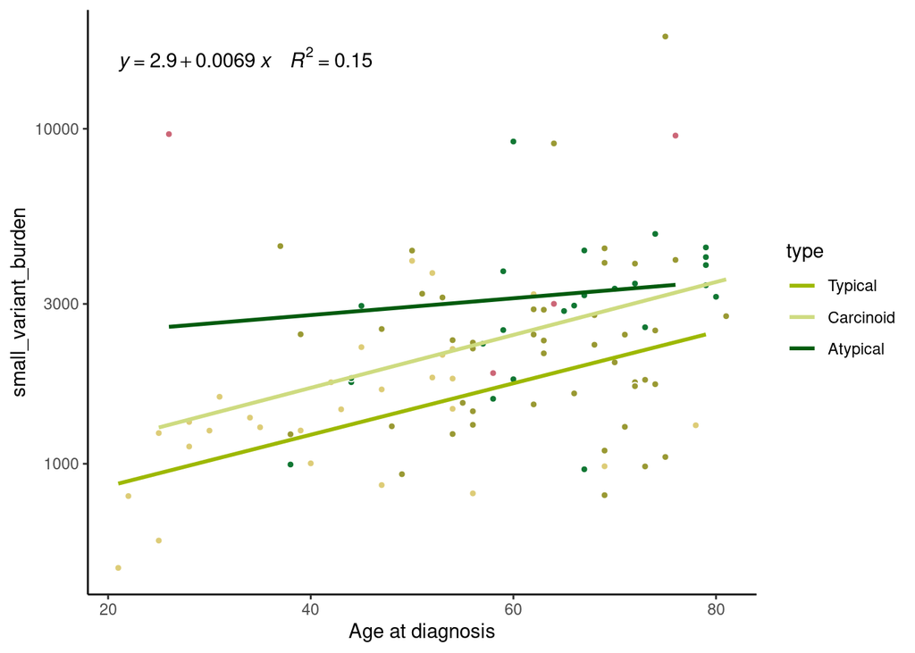

```r
ggSMB = ggplot(sigs.groups %>% filter(group!="LCNEC"), aes(y=small_variant_burden,x=age)) +
  geom_point(mapping = aes(fill=group),color="white",show.legend = F,shape=21)+
  geom_smooth(aes(col=type),method = "lm",se = F)+
  ggpubr::stat_regline_equation(mapping = aes(label =  paste(..eq.label.., ..rr.label.., sep = "~~~~")), data = sigs.groups %>% filter(group!="LCNEC")) +
  theme_classic() + scale_color_manual(values=c(arc4,type5) ) + scale_fill_manual(values=c(arc4,type5) )  + xlab("Age at diagnosis")+ scale_y_log10()  #+ facet_wrap(.~groupsimp)

ggSMB
```

```r
ggsave(ggSMB , filename="FigS10C_burden.svg",height=2.5,width=3.8)
```

Same with CNVs and SVs. We add 1 to the SV burden to stay within the permissible range of the logarithm function. We write the results in a file

```r
lmAGTS_CNV = lm( log10(CN_burden) ~ group+type+age+sex, data=sigs.groups %>% filter(group!="LCNEC"))
lmAGTS_SV = lm( log10(SV_burden+1) ~ group+type+age+sex, data=sigs.groups %>% filter(group!="LCNEC"))

anova(lmAGTS_CNV)
```

```
## Analysis of Variance Table
##
## Response: log10(CN_burden)
##           Df Sum Sq  Mean Sq F value Pr(>F)
## group      3 0.1548 0.051605  1.4578 0.2311
## type       2 0.1621 0.081063  2.2899 0.1069
## age        1 0.0067 0.006654  0.1880 0.6656
## sex        1 0.0080 0.007963  0.2250 0.6364
## Residuals 94 3.3276 0.035400
```

```r
anova(lmAGTS_SV) # type and group are significant
```

```
## Analysis of Variance Table
##
## Response: log10(SV_burden + 1)
##           Df  Sum Sq Mean Sq F value    Pr(>F)
## group      3  3.6811 1.22704  5.3597 0.0018857 **
## type       2  3.6043 1.80215  7.8718 0.0006905 ***
## age        1  0.7495 0.74946  3.2736 0.0735974 .
## sex        1  0.0091 0.00909  0.0397 0.8425031
## Residuals 94 21.5200 0.22894
## ---
## Signif. codes:  0 '***' 0.001 '**' 0.01 '*' 0.05 '.' 0.1 ' ' 1
```

```r
summary(lmAGTS_CNV)
```

```
##
## Call:
## lm(formula = log10(CN_burden) ~ group + type + age + sex, data = sigs.groups %>%
##     filter(group != "LCNEC"))
##
## Residuals:
##      Min       1Q   Median       3Q      Max
## -0.20642 -0.09949 -0.04042  0.03846  1.38460
##
## Coefficients:
##                    Estimate Std. Error t value Pr(>|t|)
## (Intercept)       1.5186154  0.1023910  14.832   <2e-16 ***
## groupCa A2       -0.0534464  0.0533406  -1.002   0.3189
## groupCa B        -0.0834520  0.0527780  -1.581   0.1172
## groupsc-enriched -0.0011962  0.0941780  -0.013   0.9899
## typeCarcinoid     0.0826766  0.0419010   1.973   0.0514 .
## typeAtypical      0.0843520  0.0554436   1.521   0.1315
## age              -0.0007254  0.0015012  -0.483   0.6301
## sexM             -0.0202686  0.0427343  -0.474   0.6364
## ---
## Signif. codes:  0 '***' 0.001 '**' 0.01 '*' 0.05 '.' 0.1 ' ' 1
##
## Residual standard error: 0.1882 on 94 degrees of freedom
## Multiple R-squared:  0.09061,    Adjusted R-squared:  0.02289
## F-statistic: 1.338 on 7 and 94 DF,  p-value: 0.2412
```

```r
summary(lmAGTS_SV)
```

```
##
## Call:
## lm(formula = log10(SV_burden + 1) ~ group + type + age + sex,
##     data = sigs.groups %>% filter(group != "LCNEC"))
##
## Residuals:
##     Min      1Q  Median      3Q     Max
## -1.2329 -0.3503  0.0127  0.2912  1.1585
##
## Coefficients:
##                   Estimate Std. Error t value Pr(>|t|)
## (Intercept)       1.497292   0.260384   5.750  1.1e-07 ***
## groupCa A2       -0.445242   0.135647  -3.282 0.001446 **
## groupCa B        -0.339089   0.134216  -2.526 0.013194 *
## groupsc-enriched -0.064297   0.239498  -0.268 0.788930
## typeCarcinoid     0.286431   0.106556   2.688 0.008501 **
## typeAtypical      0.525680   0.140995   3.728 0.000329 ***
## age              -0.006949   0.003818  -1.820 0.071902 .
## sexM             -0.021653   0.108675  -0.199 0.842503
## ---
## Signif. codes:  0 '***' 0.001 '**' 0.01 '*' 0.05 '.' 0.1 ' ' 1
##
## Residual standard error: 0.4785 on 94 degrees of freedom
## Multiple R-squared:  0.2721, Adjusted R-squared:  0.2179
## F-statistic: 5.019 on 7 and 94 DF,  p-value: 7.309e-05
```

```r
bind_rows( summary(lmAGTS) %>% tidy() %>% bind_cols(Model="small variants"),
           summary(lmAGTS_CNV) %>% tidy() %>% bind_cols(Model="CNV"),
           summary(lmAGTS_SV) %>% tidy()%>% bind_cols(Model="SV") ) %>% mutate(Signif=case_when(p.value<=0.001~"***",
                                         p.value<=0.01~"**",
                                         p.value<=0.05~"*",
                                         p.value<=0.1~".",
                                         TRUE~"")) %>% relocate(Model,.before=term) %>%  write_tsv("TableS21_burdens_lin.tsv")
```

## Extended data figure E: Drivers - per signatures

```r
MutProbs = read_tsv("/data/lungNENomics/work/alcalan/WGS/small_variants/somatic/release2_intersectmnps_15042023/mutational_signatures/lungNENomics/SBS96/Suggested_Solution/COSMIC_SBS96_Decomposed_Solution/Activities/De_Novo_MutationType_Probabilities.txt")
Signatures = read_tsv("/data/lungNENomics/work/alcalan/WGS/small_variants/somatic/release2_intersectmnps_15042023/mutational_signatures/lungNENomics/SBS96/Suggested_Solution/COSMIC_SBS96_Decomposed_Solution/Signatures/COSMIC_SBS96_Signatures.txt")
SignaturesID = read_tsv("/data/lungNENomics/work/alcalan/WGS/small_variants/somatic/release2_intersectmnps_15042023/mutational_signatures/lungNENomics/ID83/Suggested_Solution/COSMIC_ID83_Decomposed_Solution/Signatures/COSMIC_ID83_Signatures.txt")
snv_drivers_filename = load("/data/lungNENomics/work/Descriptive_manuscript_data/WGS_data/dataset_snv_dmg_lungNENomicsCombined.RData")
drivergenes = read_tsv("/data/lungNENomics/work/Descriptive_manuscript_data/WGS_data/drivers_final.tsv") %>% filter(!SYMBOL%in%c("MUC16","FAM47C","FAT4")) # we remove the 3 genes that did not pass the expression filter
snv_drivers = dataset_SNV_dmg %>% filter(Gene.refGene %in% drivergenes$SYMBOL)

#colnames(snv_drivers)[c(3:4,6:7)]=c("chr","pos","ref","alt")
#snv_drivers.SBS = snv_drivers %>% filter( ref!="-",alt!="-")
#snv_drivers.SBS$pos = as.numeric(snv_drivers.SBS$pos)
#snv_drivers.SBS = GenomeTrackSig:::getTrinuc(snv_drivers.SBS,BSgenome.Hsapiens.UCSC.hg38::BSgenome.Hsapiens.UCSC.hg38)
#snv_drivers.SBS$MutationType = paste0(substr(snv_drivers.SBS$mutType,1,1),"[",substr(snv_drivers.SBS$mutType,2,2),">",
#                                      snv_drivers.SBS$alt,"]",substr(snv_drivers.SBS$mutType,3,3) )

#snv_drivers.ID = snv_drivers %>% filter( ref=="-" | alt=="-")
#snv_drivers.ID$pos = as.numeric(snv_drivers.ID$pos)

library(SigProfilerMatrixGeneratorR)
library(reticulate)
use_python("/home/alcalan/miniforge3/bin/python") # put path to python with SigProfilerMatrixGenerator installed
py_config()
```

```
## python:         /home/alcalan/miniforge3/bin/python
## libpython:      /home/alcalan/miniforge3/lib/libpython3.12.so
## pythonhome:     /home/alcalan/miniforge3:/home/alcalan/miniforge3
## version:        3.12.7 | packaged by conda-forge | (main, Oct  4 2024, 16:05:46) [GCC 13.3.0]
## numpy:          /home/alcalan/miniforge3/lib/python3.12/site-packages/numpy
## numpy_version:  2.0.2
##
## NOTE: Python version was forced by use_python() function
```

```r
install('GRCh38', rsync=FALSE, bash=TRUE)
```

```
## Tool       | Installed
## -----------------------
## curl       | True
## wget       | True
## rsync      | True
## All reference files have been created.
## To proceed with matrix_generation, please provide the path to your vcf files and an appropriate output path.
## Installation complete.
```

```r
# write in correct format
snv_drivers.formatted = snv_drivers %>% mutate(Project="lungNENomics_drivers",ID=".",Genome="GRCh38") %>%
  rename(Sample="sample_id",mut_type="Variant_Type",chrom="Chromosome",pos_start="Start_Position",pos_end="End_Position",
         ref="Reference_Allele",alt="Tumor_Seq_Allele2") %>%  dplyr::select(Project,Sample,ID,Genome,mut_type,chrom,pos_start,pos_end,ref,alt) %>% mutate(Type="SOMATIC")
## make all sample names unique, so we get one driver per output column
snv_drivers.formatted$Sample = paste(snv_drivers.formatted$Sample,1:nrow(snv_drivers.formatted),sep="_")

dir.create("snv_drivers4SP")
```

```r
write_tsv(file = "snv_drivers4SP/snv_drivers.formatted.txt",snv_drivers.formatted)

matrices <- SigProfilerMatrixGeneratorR("drivers", "GRCh38", "snv_drivers4SP/", plot=T, exome=F, bed_file=NULL, chrom_based=F,
                                        tsb_stat=FALSE, seqInfo=FALSE, cushion=100)
```

```
## Starting matrix generation for SNVs and DINUCs...Completed! Elapsed time: 196.31 seconds.
## Starting matrix generation for INDELs...Completed! Elapsed time: 43.11 seconds.
## Matrices generated for 45 samples with 0 errors. Total of 32 SNVs, 0 DINUCs, and 13 INDELs were successfully analyzed.
```

```r
#snv_drivers.ID$MutationType = paste0(substr(snv_drivers.ID$mutType,1,1),"[",substr(snv_drivers.ID$mutType,2,2),">",
#                                      snv_drivers.ID$alt,"]",substr(snv_drivers.ID$mutType,3,3) )


Probs.all = c() # compute probability that the mutation came from one of the signatures, taking into account its activity in the sample and the number of mutations of the same type generated by each signature
for(i in 1:ncol(matrices[[4]])){ #for each driver
  if(sum( matrices[[4]][,i] )==1){# SBS
    SBS.spectrum = sigs.groups.5p[,1:13]%>% filter(Samples==  str_remove(colnames(matrices[[4]])[i],"_[0-9]+$") ) #get signature attribution of sample
    SBS.spectrum[,3:13] = SBS.spectrum[,3:13]/sum(SBS.spectrum[,3:13]) # transform to relative attribution
    Probs = SBS.spectrum[,-(1:2)]*(Signatures %>% filter(MutationType==rownames(matrices[[4]])[matrices[[4]][,i]>0]))[,-1] #find expected number of mutations of the type of the driver given the relative attributions of the sample and the profile of the signatures
    Probs = Probs/sum(Probs) # normalize to 1 to transform into a prob
    Probs.all = bind_rows(Probs.all,Probs) # add to list
  }else{#ID
    ID.spectrum = sigs.groups.5p[,c(1:2,14:19)]%>% filter(Samples==  str_remove(colnames(matrices[[4]])[i],"_[0-9]+$") ) #get signature attribution of sample
    ID.spectrum[,3:8] = ID.spectrum[,3:8]/sum(ID.spectrum[,3:8]) # transform to relative attribution
    Probs = ID.spectrum[,-(1:2)]*(SignaturesID %>% filter(MutationType==rownames(matrices$ID)[matrices$ID[,i]>0]))[,-1] #find expected number of mutations of the type of the driver given the relative attributions of the sample and the profile of the signatures
    Probs = Probs/sum(Probs) # normalize to 1 to transform into a prob
    Probs.all = bind_rows(Probs.all,Probs) # add to list
    }
}

# check that driver IDs correspond
all( colnames(matrices[[4]])==colnames(matrices$ID) )
```

```
## [1] TRUE
```

```r
snv_drivers2 = Probs.all
snv_drivers2[is.na(snv_drivers2)] = 0
snv_drivers2$sample_id = str_remove(colnames(matrices[[4]]),"_[0-9]+$")
snv_drivers2$driver_id = as.numeric(str_remove(str_extract(colnames(matrices[[4]]),"_[0-9]+$"),"_"))
snv_drivers2 = snv_drivers2 %>% arrange(driver_id)
snv_drivers2 = left_join( bind_cols(snv_drivers2,snv_drivers.formatted ), var_cli %>% dplyr::select(sample_id,group,age_cat,sex_inferred,type))
```

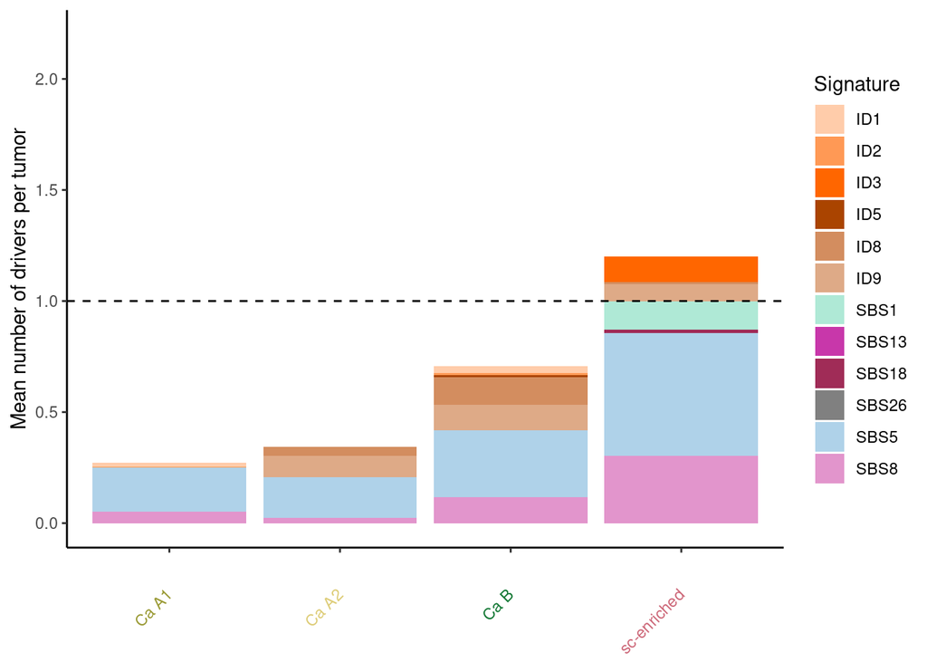

```r
snv_drivers2.long = snv_drivers2 %>% pivot_longer(cols = ID1:SBS90,names_to = "Signature",values_to = "TMB")
# normalize by sample size for each group
snv_drivers2.long$TMB[snv_drivers2.long$group=="Ca A1"] =snv_drivers2.long$TMB[snv_drivers2.long$group=="Ca A1"]/44
snv_drivers2.long$TMB[snv_drivers2.long$group=="Ca A2"] =snv_drivers2.long$TMB[snv_drivers2.long$group=="Ca A2"]/29
snv_drivers2.long$TMB[snv_drivers2.long$group=="Ca B"] =snv_drivers2.long$TMB[snv_drivers2.long$group=="Ca B"]/24
snv_drivers2.long$TMB[snv_drivers2.long$group=="sc-enriched"] =snv_drivers2.long$TMB[snv_drivers2.long$group=="sc-enriched"]/5


EDFig2e = ggplot( snv_drivers2.long , aes(x=group,y=TMB,fill=Signature)) +
  geom_bar(stat="identity") + theme_classic() + ylim(c(0,2.2)) + scale_fill_manual(values=c(SBScols,IDcols) ) +
  geom_hline(yintercept = 1,linetype="dashed")+
  theme(axis.text.x = element_text(angle = 45, vjust = 0.5, hjust=1,colour =arc4[(c("Ca A1","Ca A2","Ca B","sc-enriched"))] ) ) +
  xlab("") + ylab("Mean number of drivers per tumor")
EDFig2e
```

```r
ggsave(EDFig2e,filename = "EDFig2e_drivers_mutsig.svg",height = 2.5,width=3)

# are some genes more often created by given sig? nope
summary( glm(snv_drivers$Gene.refGene=="MEN1"~snv_drivers2$SBS1,family = binomial(link='logit')) )
```

```
##
## Call:
## glm(formula = snv_drivers$Gene.refGene == "MEN1" ~ snv_drivers2$SBS1,
##     family = binomial(link = "logit"))
##
## Coefficients:
##                   Estimate Std. Error z value Pr(>|z|)
## (Intercept)        -1.0390     0.3759  -2.764  0.00572 **
## snv_drivers2$SBS1 -26.3116    68.4519  -0.384  0.70070
## ---
## Signif. codes:  0 '***' 0.001 '**' 0.01 '*' 0.05 '.' 0.1 ' ' 1
##
## (Dispersion parameter for binomial family taken to be 1)
##
##     Null deviance: 50.053  on 44  degrees of freedom
## Residual deviance: 49.325  on 43  degrees of freedom
## AIC: 53.325
##
## Number of Fisher Scoring iterations: 8
```

```r
summary( glm(snv_drivers$Gene.refGene=="MEN1"~snv_drivers2$SBS5,family = binomial(link='logit')) )
```

```
##
## Call:
## glm(formula = snv_drivers$Gene.refGene == "MEN1" ~ snv_drivers2$SBS5,
##     family = binomial(link = "logit"))
##
## Coefficients:
##                   Estimate Std. Error z value Pr(>|z|)
## (Intercept)        -0.8633     0.5300  -1.629    0.103
## snv_drivers2$SBS5  -0.5219     0.8247  -0.633    0.527
##
## (Dispersion parameter for binomial family taken to be 1)
##
##     Null deviance: 50.053  on 44  degrees of freedom
## Residual deviance: 49.650  on 43  degrees of freedom
## AIC: 53.65
##
## Number of Fisher Scoring iterations: 4
```

```r
summary( glm(snv_drivers$Gene.refGene=="MEN1"~snv_drivers2$SBS8,family = binomial(link='logit')) )
```

```
##
## Call:
## glm(formula = snv_drivers$Gene.refGene == "MEN1" ~ snv_drivers2$SBS8,
##     family = binomial(link = "logit"))
##
## Coefficients:
##                   Estimate Std. Error z value Pr(>|z|)
## (Intercept)        -0.8962     0.3873  -2.314   0.0207 *
## snv_drivers2$SBS8  -1.8176     1.6899  -1.076   0.2821
## ---
## Signif. codes:  0 '***' 0.001 '**' 0.01 '*' 0.05 '.' 0.1 ' ' 1
##
## (Dispersion parameter for binomial family taken to be 1)
##
##     Null deviance: 50.053  on 44  degrees of freedom
## Residual deviance: 48.609  on 43  degrees of freedom
## AIC: 52.609
##
## Number of Fisher Scoring iterations: 4
```

```r
summary( glm(snv_drivers$Gene.refGene=="MEN1"~snv_drivers2$ID1,family = binomial(link='logit')) )
```

```
##
## Call:
## glm(formula = snv_drivers$Gene.refGene == "MEN1" ~ snv_drivers2$ID1,
##     family = binomial(link = "logit"))
##
## Coefficients:
##                  Estimate Std. Error z value Pr(>|z|)
## (Intercept)       -1.0616     0.3589  -2.957   0.0031 **
## snv_drivers2$ID1 -39.8843   535.0547  -0.075   0.9406
## ---
## Signif. codes:  0 '***' 0.001 '**' 0.01 '*' 0.05 '.' 0.1 ' ' 1
##
## (Dispersion parameter for binomial family taken to be 1)
##
##     Null deviance: 50.053  on 44  degrees of freedom
## Residual deviance: 48.897  on 43  degrees of freedom
## AIC: 52.897
##
## Number of Fisher Scoring iterations: 12
```

```r
summary( glm(snv_drivers$Gene.refGene=="MEN1"~snv_drivers2$ID3,family = binomial(link='logit')) )
```

```
##
## Call:
## glm(formula = snv_drivers$Gene.refGene == "MEN1" ~ snv_drivers2$ID3,
##     family = binomial(link = "logit"))
##
## Coefficients:
##                  Estimate Std. Error z value Pr(>|z|)
## (Intercept)       -1.2651     0.3719  -3.402 0.000669 ***
## snv_drivers2$ID3  84.5492   161.2891   0.524 0.600133
## ---
## Signif. codes:  0 '***' 0.001 '**' 0.01 '*' 0.05 '.' 0.1 ' ' 1
##
## (Dispersion parameter for binomial family taken to be 1)
##
##     Null deviance: 50.053  on 44  degrees of freedom
## Residual deviance: 46.908  on 43  degrees of freedom
## AIC: 50.908
##
## Number of Fisher Scoring iterations: 9
```

```r
summary( glm(snv_drivers$Gene.refGene=="MEN1"~snv_drivers2$ID8,family = binomial(link='logit')) )
```

```
##
## Call:
## glm(formula = snv_drivers$Gene.refGene == "MEN1" ~ snv_drivers2$ID8,
##     family = binomial(link = "logit"))
##
## Coefficients:
##                  Estimate Std. Error z value Pr(>|z|)
## (Intercept)       -1.2723     0.3791  -3.356  0.00079 ***
## snv_drivers2$ID8   1.2681     1.0872   1.166  0.24345
## ---
## Signif. codes:  0 '***' 0.001 '**' 0.01 '*' 0.05 '.' 0.1 ' ' 1
##
## (Dispersion parameter for binomial family taken to be 1)
##
##     Null deviance: 50.053  on 44  degrees of freedom
## Residual deviance: 48.749  on 43  degrees of freedom
## AIC: 52.749
##
## Number of Fisher Scoring iterations: 4
```

```r
summary( glm(snv_drivers$Gene.refGene=="MEN1"~snv_drivers2$ID9,family = binomial(link='logit')) )
```

```
##
## Call:
## glm(formula = snv_drivers$Gene.refGene == "MEN1" ~ snv_drivers2$ID9,
##     family = binomial(link = "logit"))
##
## Coefficients:
##                  Estimate Std. Error z value Pr(>|z|)
## (Intercept)       -1.2734     0.3901  -3.264   0.0011 **
## snv_drivers2$ID9   0.9238     0.9687   0.954   0.3402
## ---
## Signif. codes:  0 '***' 0.001 '**' 0.01 '*' 0.05 '.' 0.1 ' ' 1
##
## (Dispersion parameter for binomial family taken to be 1)
##
##     Null deviance: 50.053  on 44  degrees of freedom
## Residual deviance: 49.187  on 43  degrees of freedom
## AIC: 53.187
##
## Number of Fisher Scoring iterations: 4
```

```r
summary( glm(snv_drivers$Gene.refGene=="EIF1AX"~snv_drivers2$SBS1,family = binomial(link='logit')) )
```

```
##
## Call:
## glm(formula = snv_drivers$Gene.refGene == "EIF1AX" ~ snv_drivers2$SBS1,
##     family = binomial(link = "logit"))
##
## Coefficients:
##                   Estimate Std. Error z value Pr(>|z|)
## (Intercept)        -1.8437     0.4425  -4.167 3.09e-05 ***
## snv_drivers2$SBS1  -2.9124    10.2493  -0.284    0.776
## ---
## Signif. codes:  0 '***' 0.001 '**' 0.01 '*' 0.05 '.' 0.1 ' ' 1
##
## (Dispersion parameter for binomial family taken to be 1)
##
##     Null deviance: 35.341  on 44  degrees of freedom
## Residual deviance: 35.193  on 43  degrees of freedom
## AIC: 39.193
##
## Number of Fisher Scoring iterations: 6
```

```r
summary( glm(snv_drivers$Gene.refGene=="EIF1AX"~snv_drivers2$SBS5,family = binomial(link='logit')) )
```

```
##
## Call:
## glm(formula = snv_drivers$Gene.refGene == "EIF1AX" ~ snv_drivers2$SBS5,
##     family = binomial(link = "logit"))
##
## Coefficients:
##                   Estimate Std. Error z value Pr(>|z|)
## (Intercept)        -2.6682     0.9222  -2.893  0.00381 **
## snv_drivers2$SBS5   1.2968     1.1656   1.113  0.26592
## ---
## Signif. codes:  0 '***' 0.001 '**' 0.01 '*' 0.05 '.' 0.1 ' ' 1
##
## (Dispersion parameter for binomial family taken to be 1)
##
##     Null deviance: 35.341  on 44  degrees of freedom
## Residual deviance: 33.961  on 43  degrees of freedom
## AIC: 37.961
##
## Number of Fisher Scoring iterations: 5
```

```r
summary( glm(snv_drivers$Gene.refGene=="EIF1AX"~snv_drivers2$SBS8,family = binomial(link='logit')) )
```

```
##
## Call:
## glm(formula = snv_drivers$Gene.refGene == "EIF1AX" ~ snv_drivers2$SBS8,
##     family = binomial(link = "logit"))
##
## Coefficients:
##                   Estimate Std. Error z value Pr(>|z|)
## (Intercept)        -2.1942     0.5692  -3.855 0.000116 ***
## snv_drivers2$SBS8   1.5656     1.4094   1.111 0.266647
## ---
## Signif. codes:  0 '***' 0.001 '**' 0.01 '*' 0.05 '.' 0.1 ' ' 1
##
## (Dispersion parameter for binomial family taken to be 1)
##
##     Null deviance: 35.341  on 44  degrees of freedom
## Residual deviance: 34.186  on 43  degrees of freedom
## AIC: 38.186
##
## Number of Fisher Scoring iterations: 4
```

```r
summary( glm(snv_drivers$Gene.refGene=="EIF1AX"~snv_drivers2$ID1,family = binomial(link='logit')) )
```

```
##
## Call:
## glm(formula = snv_drivers$Gene.refGene == "EIF1AX" ~ snv_drivers2$ID1,
##     family = binomial(link = "logit"))
##
## Coefficients:
##                    Estimate Std. Error z value Pr(>|z|)
## (Intercept)      -1.674e+00  4.449e-01  -3.763 0.000168 ***
## snv_drivers2$ID1 -2.572e+06  1.516e+07  -0.170 0.865259
## ---
## Signif. codes:  0 '***' 0.001 '**' 0.01 '*' 0.05 '.' 0.1 ' ' 1
##
## (Dispersion parameter for binomial family taken to be 1)
##
##     Null deviance: 35.341  on 44  degrees of freedom
## Residual deviance: 33.149  on 43  degrees of freedom
## AIC: 37.149
##
## Number of Fisher Scoring iterations: 25
```

```r
summary( glm(snv_drivers$Gene.refGene=="EIF1AX"~snv_drivers2$ID3,family = binomial(link='logit')) )
```

```
##
## Call:
## glm(formula = snv_drivers$Gene.refGene == "EIF1AX" ~ snv_drivers2$ID3,
##     family = binomial(link = "logit"))
##
## Coefficients:
##                    Estimate Std. Error z value Pr(>|z|)
## (Intercept)          -1.792      0.441  -4.063 4.84e-05 ***
## snv_drivers2$ID3  -2097.546 327084.885  -0.006    0.995
## ---
## Signif. codes:  0 '***' 0.001 '**' 0.01 '*' 0.05 '.' 0.1 ' ' 1
##
## (Dispersion parameter for binomial family taken to be 1)
##
##     Null deviance: 35.341  on 44  degrees of freedom
## Residual deviance: 34.450  on 43  degrees of freedom
## AIC: 38.45
##
## Number of Fisher Scoring iterations: 21
```

```r
summary( glm(snv_drivers$Gene.refGene=="EIF1AX"~snv_drivers2$ID8,family = binomial(link='logit')) )
```

```
##
## Call:
## glm(formula = snv_drivers$Gene.refGene == "EIF1AX" ~ snv_drivers2$ID8,
##     family = binomial(link = "logit"))
##
## Coefficients:
##                    Estimate Std. Error z value Pr(>|z|)
## (Intercept)         -1.7047     0.4438  -3.841 0.000122 ***
## snv_drivers2$ID8  -299.8354 54203.8278  -0.006 0.995586
## ---
## Signif. codes:  0 '***' 0.001 '**' 0.01 '*' 0.05 '.' 0.1 ' ' 1
##
## (Dispersion parameter for binomial family taken to be 1)
##
##     Null deviance: 35.341  on 44  degrees of freedom
## Residual deviance: 33.487  on 43  degrees of freedom
## AIC: 37.487
##
## Number of Fisher Scoring iterations: 21
```

```r
summary( glm(snv_drivers$Gene.refGene=="EIF1AX"~snv_drivers2$ID9,family = binomial(link='logit')) )
```

```
##
## Call:
## glm(formula = snv_drivers$Gene.refGene == "EIF1AX" ~ snv_drivers2$ID9,
##     family = binomial(link = "logit"))
##
## Coefficients:
##                    Estimate Std. Error z value Pr(>|z|)
## (Intercept)      -1.575e+00  4.485e-01  -3.513 0.000443 ***
## snv_drivers2$ID9 -7.689e+03  1.127e+06  -0.007 0.994554
## ---
## Signif. codes:  0 '***' 0.001 '**' 0.01 '*' 0.05 '.' 0.1 ' ' 1
##
## (Dispersion parameter for binomial family taken to be 1)
##
##     Null deviance: 35.341  on 44  degrees of freedom
## Residual deviance: 32.070  on 43  degrees of freedom
## AIC: 36.07
##
## Number of Fisher Scoring iterations: 25
```

```r
summary( glm(snv_drivers$Gene.refGene=="ATM"~snv_drivers2$SBS1,family = binomial(link='logit')) )
```

```
##
## Call:
## glm(formula = snv_drivers$Gene.refGene == "ATM" ~ snv_drivers2$SBS1,
##     family = binomial(link = "logit"))
##
## Coefficients:
##                   Estimate Std. Error z value Pr(>|z|)
## (Intercept)        -2.3247     0.5268  -4.413 1.02e-05 ***
## snv_drivers2$SBS1  10.2953    12.2549   0.840    0.401
## ---
## Signif. codes:  0 '***' 0.001 '**' 0.01 '*' 0.05 '.' 0.1 ' ' 1
##
## (Dispersion parameter for binomial family taken to be 1)
##
##     Null deviance: 31.395  on 44  degrees of freedom
## Residual deviance: 27.055  on 43  degrees of freedom
## AIC: 31.055
##
## Number of Fisher Scoring iterations: 6
```

```r
summary( glm(snv_drivers$Gene.refGene=="ATM"~snv_drivers2$SBS5,family = binomial(link='logit')) )
```

```
##
## Call:
## glm(formula = snv_drivers$Gene.refGene == "ATM" ~ snv_drivers2$SBS5,
##     family = binomial(link = "logit"))
##
## Coefficients:
##                   Estimate Std. Error z value Pr(>|z|)
## (Intercept)        -2.1822     0.7889  -2.766  0.00567 **
## snv_drivers2$SBS5   0.1886     1.1300   0.167  0.86741
## ---
## Signif. codes:  0 '***' 0.001 '**' 0.01 '*' 0.05 '.' 0.1 ' ' 1
##
## (Dispersion parameter for binomial family taken to be 1)
##
##     Null deviance: 31.395  on 44  degrees of freedom
## Residual deviance: 31.367  on 43  degrees of freedom
## AIC: 35.367
##
## Number of Fisher Scoring iterations: 4
```

```r
summary( glm(snv_drivers$Gene.refGene=="ATM"~snv_drivers2$SBS8,family = binomial(link='logit')) )
```

```
##
## Call:
## glm(formula = snv_drivers$Gene.refGene == "ATM" ~ snv_drivers2$SBS8,
##     family = binomial(link = "logit"))
##
## Coefficients:
##                   Estimate Std. Error z value Pr(>|z|)
## (Intercept)        -2.5049     0.6436  -3.892 9.93e-05 ***
## snv_drivers2$SBS8   1.9225     1.4895   1.291    0.197
## ---
## Signif. codes:  0 '***' 0.001 '**' 0.01 '*' 0.05 '.' 0.1 ' ' 1
##
## (Dispersion parameter for binomial family taken to be 1)
##
##     Null deviance: 31.395  on 44  degrees of freedom
## Residual deviance: 29.836  on 43  degrees of freedom
## AIC: 33.836
##
## Number of Fisher Scoring iterations: 5
```

```r
summary( glm(snv_drivers$Gene.refGene=="ATM"~snv_drivers2$ID1,family = binomial(link='logit')) )
```

```
##
## Call:
## glm(formula = snv_drivers$Gene.refGene == "ATM" ~ snv_drivers2$ID1,
##     family = binomial(link = "logit"))
##
## Coefficients:
##                    Estimate Std. Error z value Pr(>|z|)
## (Intercept)      -1.887e+00  4.799e-01  -3.932 8.42e-05 ***
## snv_drivers2$ID1 -2.530e+06  1.597e+07  -0.158    0.874
## ---
## Signif. codes:  0 '***' 0.001 '**' 0.01 '*' 0.05 '.' 0.1 ' ' 1
##
## (Dispersion parameter for binomial family taken to be 1)
##
##     Null deviance: 31.395  on 44  degrees of freedom
## Residual deviance: 29.593  on 43  degrees of freedom
## AIC: 33.593
##
## Number of Fisher Scoring iterations: 25
```

```r
summary( glm(snv_drivers$Gene.refGene=="ATM"~snv_drivers2$ID3,family = binomial(link='logit')) )
```

```
##
## Call:
## glm(formula = snv_drivers$Gene.refGene == "ATM" ~ snv_drivers2$ID3,
##     family = binomial(link = "logit"))
##
## Coefficients:
##                    Estimate Std. Error z value Pr(>|z|)
## (Intercept)      -2.002e+00  4.765e-01  -4.201 2.66e-05 ***
## snv_drivers2$ID3 -2.066e+03  3.248e+05  -0.006    0.995
## ---
## Signif. codes:  0 '***' 0.001 '**' 0.01 '*' 0.05 '.' 0.1 ' ' 1
##
## (Dispersion parameter for binomial family taken to be 1)
##
##     Null deviance: 31.395  on 44  degrees of freedom
## Residual deviance: 30.662  on 43  degrees of freedom
## AIC: 34.662
##
## Number of Fisher Scoring iterations: 21
```

```r
summary( glm(snv_drivers$Gene.refGene=="ATM"~snv_drivers2$ID8,family = binomial(link='logit')) )
```

```
##
## Call:
## glm(formula = snv_drivers$Gene.refGene == "ATM" ~ snv_drivers2$ID8,
##     family = binomial(link = "logit"))
##
## Coefficients:
##                   Estimate Std. Error z value Pr(>|z|)
## (Intercept)         -1.917      0.479  -4.002 6.28e-05 ***
## snv_drivers2$ID8  -295.512  54044.634  -0.005    0.996
## ---
## Signif. codes:  0 '***' 0.001 '**' 0.01 '*' 0.05 '.' 0.1 ' ' 1
##
## (Dispersion parameter for binomial family taken to be 1)
##
##     Null deviance: 31.395  on 44  degrees of freedom
## Residual deviance: 29.871  on 43  degrees of freedom
## AIC: 33.871
##
## Number of Fisher Scoring iterations: 21
```

```r
summary( glm(snv_drivers$Gene.refGene=="ATM"~snv_drivers2$ID9,family = binomial(link='logit')) )
```

```
##
## Call:
## glm(formula = snv_drivers$Gene.refGene == "ATM" ~ snv_drivers2$ID9,
##     family = binomial(link = "logit"))
##
## Coefficients:
##                    Estimate Std. Error z value Pr(>|z|)
## (Intercept)      -1.792e+00  4.830e-01  -3.709 0.000208 ***
## snv_drivers2$ID9 -7.636e+03  1.193e+06  -0.006 0.994893
## ---
## Signif. codes:  0 '***' 0.001 '**' 0.01 '*' 0.05 '.' 0.1 ' ' 1
##
## (Dispersion parameter for binomial family taken to be 1)
##
##     Null deviance: 31.395  on 44  degrees of freedom
## Residual deviance: 28.708  on 43  degrees of freedom
## AIC: 32.708
##
## Number of Fisher Scoring iterations: 25
```

```r
summary( glm(snv_drivers$Gene.refGene=="BRAF"~snv_drivers2$SBS1,family = binomial(link='logit')) )
```

```
##
## Call:
## glm(formula = snv_drivers$Gene.refGene == "BRAF" ~ snv_drivers2$SBS1,
##     family = binomial(link = "logit"))
##
## Coefficients:
##                   Estimate Std. Error z value Pr(>|z|)
## (Intercept)        -2.9084     0.7584  -3.835 0.000126 ***
## snv_drivers2$SBS1 -86.5415   233.7163  -0.370 0.711171
## ---
## Signif. codes:  0 '***' 0.001 '**' 0.01 '*' 0.05 '.' 0.1 ' ' 1
##
## (Dispersion parameter for binomial family taken to be 1)
##
##     Null deviance: 16.364  on 44  degrees of freedom
## Residual deviance: 16.056  on 43  degrees of freedom
## AIC: 20.056
##
## Number of Fisher Scoring iterations: 10
```

```r
summary( glm(snv_drivers$Gene.refGene=="BRAF"~snv_drivers2$SBS5,family = binomial(link='logit')) )
```

```
##
## Call:
## glm(formula = snv_drivers$Gene.refGene == "BRAF" ~ snv_drivers2$SBS5,
##     family = binomial(link = "logit"))
##
## Coefficients:
##                   Estimate Std. Error z value Pr(>|z|)
## (Intercept)        -3.2995     1.2716  -2.595  0.00946 **
## snv_drivers2$SBS5   0.4099     1.7504   0.234  0.81486
## ---
## Signif. codes:  0 '***' 0.001 '**' 0.01 '*' 0.05 '.' 0.1 ' ' 1
##
## (Dispersion parameter for binomial family taken to be 1)
##
##     Null deviance: 16.364  on 44  degrees of freedom
## Residual deviance: 16.308  on 43  degrees of freedom
## AIC: 20.308
##
## Number of Fisher Scoring iterations: 6
```

```r
summary( glm(snv_drivers$Gene.refGene=="BRAF"~snv_drivers2$SBS8,family = binomial(link='logit')) )
```

```
##
## Call:
## glm(formula = snv_drivers$Gene.refGene == "BRAF" ~ snv_drivers2$SBS8,
##     family = binomial(link = "logit"))
##
## Coefficients:
##                   Estimate Std. Error z value Pr(>|z|)
## (Intercept)         -3.606      1.051  -3.430 0.000605 ***
## snv_drivers2$SBS8    2.171      2.185   0.993 0.320556
## ---
## Signif. codes:  0 '***' 0.001 '**' 0.01 '*' 0.05 '.' 0.1 ' ' 1
##
## (Dispersion parameter for binomial family taken to be 1)
##
##     Null deviance: 16.364  on 44  degrees of freedom
## Residual deviance: 15.443  on 43  degrees of freedom
## AIC: 19.443
##
## Number of Fisher Scoring iterations: 6
```

```r
summary( glm(snv_drivers$Gene.refGene=="BRAF"~snv_drivers2$ID1,family = binomial(link='logit')) )
```

```
##
## Call:
## glm(formula = snv_drivers$Gene.refGene == "BRAF" ~ snv_drivers2$ID1,
##     family = binomial(link = "logit"))
##
## Coefficients:
##                    Estimate Std. Error z value Pr(>|z|)
## (Intercept)      -2.890e+00  7.265e-01  -3.979 6.93e-05 ***
## snv_drivers2$ID1 -2.108e+06  1.526e+07  -0.138     0.89
## ---
## Signif. codes:  0 '***' 0.001 '**' 0.01 '*' 0.05 '.' 0.1 ' ' 1
##
## (Dispersion parameter for binomial family taken to be 1)
##
##     Null deviance: 16.364  on 44  degrees of freedom
## Residual deviance: 15.671  on 43  degrees of freedom
## AIC: 19.671
##
## Number of Fisher Scoring iterations: 25
```

```r
summary( glm(snv_drivers$Gene.refGene=="BRAF"~snv_drivers2$ID3,family = binomial(link='logit')) )
```

```
##
## Call:
## glm(formula = snv_drivers$Gene.refGene == "BRAF" ~ snv_drivers2$ID3,
##     family = binomial(link = "logit"))
##
## Coefficients:
##                    Estimate Std. Error z value Pr(>|z|)
## (Intercept)      -2.996e+00  7.246e-01  -4.135 3.56e-05 ***
## snv_drivers2$ID3 -2.064e+03  5.312e+05  -0.004    0.997
## ---
## Signif. codes:  0 '***' 0.001 '**' 0.01 '*' 0.05 '.' 0.1 ' ' 1
##
## (Dispersion parameter for binomial family taken to be 1)
##
##     Null deviance: 16.364  on 44  degrees of freedom
## Residual deviance: 16.081  on 43  degrees of freedom
## AIC: 20.081
##
## Number of Fisher Scoring iterations: 22
```

```r
summary( glm(snv_drivers$Gene.refGene=="BRAF"~snv_drivers2$ID8,family = binomial(link='logit')) )
```

```
##
## Call:
## glm(formula = snv_drivers$Gene.refGene == "BRAF" ~ snv_drivers2$ID8,
##     family = binomial(link = "logit"))
##
## Coefficients:
##                   Estimate Std. Error z value Pr(>|z|)
## (Intercept)         -2.918      0.726  -4.019 5.84e-05 ***
## snv_drivers2$ID8  -295.675  89510.841  -0.003    0.997
## ---
## Signif. codes:  0 '***' 0.001 '**' 0.01 '*' 0.05 '.' 0.1 ' ' 1
##
## (Dispersion parameter for binomial family taken to be 1)
##
##     Null deviance: 16.364  on 44  degrees of freedom
## Residual deviance: 15.777  on 43  degrees of freedom
## AIC: 19.777
##
## Number of Fisher Scoring iterations: 22
```

```r
summary( glm(snv_drivers$Gene.refGene=="BRAF"~snv_drivers2$ID9,family = binomial(link='logit')) )
```

```
##
## Call:
## glm(formula = snv_drivers$Gene.refGene == "BRAF" ~ snv_drivers2$ID9,
##     family = binomial(link = "logit"))
##
## Coefficients:
##                    Estimate Std. Error z value Pr(>|z|)
## (Intercept)      -2.803e+00  7.282e-01  -3.850 0.000118 ***
## snv_drivers2$ID9 -7.067e+03  1.141e+06  -0.006 0.995058
## ---
## Signif. codes:  0 '***' 0.001 '**' 0.01 '*' 0.05 '.' 0.1 ' ' 1
##
## (Dispersion parameter for binomial family taken to be 1)
##
##     Null deviance: 16.364  on 44  degrees of freedom
## Residual deviance: 15.332  on 43  degrees of freedom
## AIC: 19.332
##
## Number of Fisher Scoring iterations: 25
```

# Fig. S10B: Relative signature attributions

We first plot relative proportions per molecular group and per type of alteration (Fig. S10B)

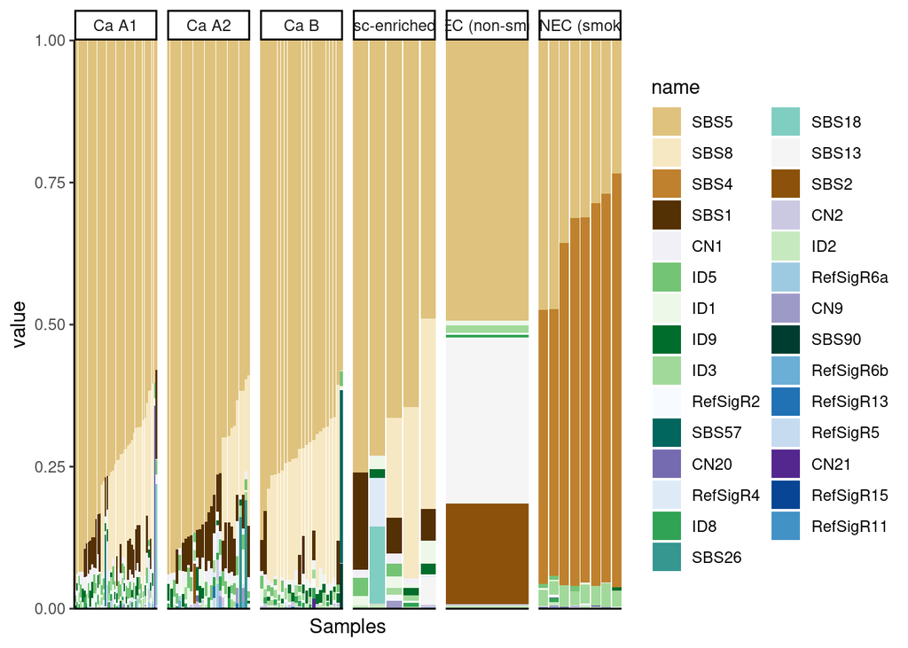

```r
SBS.5p.prop = sigs.groups.5p[,-c(which(colSums(sigs.groups.5p[,3:32])==0)+2)][,c(1:2,3:12)] #10 signatures, 111 samples
SBS.5p.prop[,-c(1:2)] = sweep(SBS.5p.prop[,-c(1:2)],1,rowSums(SBS.5p.prop[,-c(1:2)]),"/")
SBS.5p.prop[,-c(1:2)][is.na(SBS.5p.prop[,-c(1:2)])] = 0
## arrange by hand
SBS.5p.prop.long = SBS.5p.prop %>% filter(rowSums(SBS.5p.prop[,-c(1,2)])>0) %>% pivot_longer(-c(Samples,group))
sigorder = SBS.5p.prop.long %>% group_by(name) %>% summarize(meanact=mean(value)) %>% arrange(-meanact) %>% pull(name)
sampleorder = SBS.5p.prop %>% arrange(!!!rlang::syms(sigorder)) %>% pull(Samples) %>% rev()
SBS.5p.prop.long = SBS.5p.prop.long %>% mutate(Samples=factor(Samples,levels=sampleorder),name=factor(name,levels=sigorder))

gg_SBS_samples = ggplot(SBS.5p.prop.long ,aes(x=Samples,y=value,fill = name)) + geom_bar(stat = "identity")+
  facet_grid(.~group,scales = "free_x")+ theme_classic()+ coord_cartesian(expand = F) +
  theme(axis.text.x = element_blank(),axis.ticks.x = element_blank(),axis.title.x = element_blank())+
  scale_fill_brewer(palette = "Paired") + scale_color_brewer(palette = "Paired")

## IDs
ID.5p.prop = sigs.groups.5p[,-c(which(colSums(sigs.groups.5p[,3:32])==0)+2)][,c(1:2,13:18)]  #6 signatures
ID.5p.prop[,-c(1:2)] = sweep(ID.5p.prop[,-c(1:2)],1,rowSums(ID.5p.prop[,-c(1:2)]),"/")
ID.5p.prop[,-c(1:2)][is.na(ID.5p.prop[,-c(1:2)])] = 0
## arrange by hand
ID.5p.prop.long = ID.5p.prop %>% filter(rowSums(ID.5p.prop[,-c(1,2)])>0) %>% pivot_longer(-c(Samples,group))
sigorder = ID.5p.prop.long %>% group_by(name) %>% summarize(meanact=mean(value)) %>% arrange(-meanact) %>% pull(name)
sampleorder = ID.5p.prop %>% arrange(!!!rlang::syms(sigorder)) %>% pull(Samples) %>% rev()
ID.5p.prop.long = ID.5p.prop.long %>% mutate(Samples=factor(Samples,levels=sampleorder),name=factor(name,levels=sigorder))

gg_ID_samples = ggplot(ID.5p.prop.long ,aes(x=Samples,y=value,fill = name)) + geom_bar(stat = "identity")+
  facet_grid(.~group,scales = "free_x")+ theme_classic()+ coord_cartesian(expand = F) +
  theme(axis.text.x = element_blank(),axis.ticks.x = element_blank(),axis.title.x = element_blank())+
  scale_fill_brewer(palette = "Paired") + scale_color_brewer(palette = "Paired")

## CNs
CN.5p.prop = sigs.groups.5p[,-c(which(colSums(sigs.groups.5p[,3:32])==0)+2)][,c(1:2,19:23)] #5 signatures
CN.5p.prop[,-c(1:2)] = sweep(CN.5p.prop[,-c(1:2)],1,rowSums(CN.5p.prop[,-c(1:2)]),"/")
CN.5p.prop[,-c(1:2)][is.na(CN.5p.prop[,-c(1:2)])] = 0
## arrange by hand
CN.5p.prop.long = CN.5p.prop %>% filter(rowSums(CN.5p.prop[,-c(1,2)])>0) %>% pivot_longer(-c(Samples,group))
sigorder = CN.5p.prop.long %>% group_by(name) %>% summarize(meanact=mean(value)) %>% arrange(-meanact) %>% pull(name)
sampleorder = CN.5p.prop %>% arrange(!!!rlang::syms(sigorder)) %>% pull(Samples) %>% rev()
CN.5p.prop.long = CN.5p.prop.long %>% mutate(Samples=factor(Samples,levels=sampleorder),name=factor(name,levels=sigorder))

gg_CN_samples = ggplot(CN.5p.prop.long ,aes(x=Samples,y=value,fill = name)) + geom_bar(stat = "identity")+
  facet_grid(.~group,scales = "free_x")+ theme_classic()+ coord_cartesian(expand = F) +
  theme(axis.text.x = element_blank(),axis.ticks.x = element_blank(),axis.title.x = element_blank())+
  scale_fill_brewer(palette = "Paired") + scale_color_brewer(palette = "Paired")

## SVs
SV.5p.prop = sigs.groups.5p[,-c(which(colSums(sigs.groups.5p[,3:32])==0)+2)][,c(1:2,24:31)] #8 signatures
SV.5p.prop[,-c(1:2)] = sweep(SV.5p.prop[,-c(1:2)],1,rowSums(SV.5p.prop[,-c(1:2)]),"/")
SV.5p.prop[,-c(1:2)][is.na(SV.5p.prop[,-c(1:2)])] = 0
## arrange by hand
SV.5p.prop.long = SV.5p.prop %>% filter(rowSums(SV.5p.prop[,-c(1,2)])>0) %>% pivot_longer(-c(Samples,group))
sigorder = SV.5p.prop.long %>% group_by(name) %>% summarize(meanact=mean(value)) %>% arrange(-meanact) %>% pull(name)
sampleorder = SV.5p.prop %>% arrange(!!!rlang::syms(sigorder)) %>% pull(Samples) %>% rev()
SV.5p.prop.long = SV.5p.prop.long %>% mutate(Samples=factor(Samples,levels=sampleorder),name=factor(name,levels=sigorder))

gg_SV_samples = ggplot(SV.5p.prop.long ,aes(x=Samples,y=value,fill = name)) + geom_bar(stat = "identity")+
  facet_grid(.~group,scales = "free_x")+ theme_classic()+ coord_cartesian(expand = F) +
  theme(axis.text.x = element_blank(),axis.ticks.x = element_blank())+
  scale_fill_brewer(palette = "Paired") + scale_color_brewer(palette = "Paired")

## global
global.5p.prop = sigs.groups.5p[,-c(which(colSums(sigs.groups.5p[,3:32])==0)+2)][,c(1:2,3:31)] #29 signatures
global.5p.prop[,-c(1:2)] = sweep(global.5p.prop[,-c(1:2)],1,rowSums(global.5p.prop[,-c(1:2)]),"/")
global.5p.prop[,-c(1:2)][is.na(global.5p.prop[,-c(1:2)])] = 0
## arrange by hand
global.5p.prop.long = global.5p.prop %>% filter(rowSums(global.5p.prop[,-c(1,2)])>0) %>% pivot_longer(-c(Samples,group))
sigorder = global.5p.prop.long %>% group_by(name) %>% summarize(meanact=mean(value)) %>% arrange(-meanact) %>% pull(name)
sampleorder = global.5p.prop %>% arrange(!!!rlang::syms(sigorder)) %>% pull(Samples) %>% rev()
global.5p.prop.long = global.5p.prop.long %>% mutate(Samples=factor(Samples,levels=sampleorder),name=factor(name,levels=sigorder))

cols_allsigs = rep(NA,ncol(global.5p.prop)-1)
names(cols_allsigs) = colnames(sigs.groups.5p)[3:32]
cols_allsigs[1:11] = RColorBrewer::brewer.pal(11,"BrBG")
cols_allsigs[12:17] = RColorBrewer::brewer.pal(6,"Greens")
cols_allsigs[18:22] = RColorBrewer::brewer.pal(5,"Purples")
cols_allsigs[23:30] = RColorBrewer::brewer.pal(8,"Blues")

gg_global_samples = ggplot(global.5p.prop.long ,aes(x=Samples,y=value,fill = name)) + geom_bar(stat = "identity")+
  facet_grid(.~group,scales = "free_x")+ theme_classic()+ coord_cartesian(expand = F) +
  theme(axis.text.x = element_blank(),axis.ticks.x = element_blank())+
  scale_fill_manual(values = cols_allsigs)
gg_global_samples
```

```r
ggsave( gg_SBS_samples +gg_ID_samples +gg_CN_samples +gg_SV_samples  + gg_global_samples + plot_layout(widths = c(1, 4)) ,
        filename = "FigS10B_mutational_signatures_relative_samples.svg",height = 2.5*4,width=2.5*5)
```

# Fig. S10D: Signature variability analysis

We compute the diversity (function het from package sigvar) of mutations within each sample

```r
global.5p.prop4boot = global.5p.prop %>% mutate(group=as.character(group)) %>% bind_cols()
global.5p.prop4boot$group[str_detect(global.5p.prop4boot$group,"LCNEC")] = "LCNEC"
global.5p.prop4boot = global.5p.prop4boot %>% mutate(group=factor(group,levels=c("Ca A1","Ca A2","Ca B","sc-enriched","LCNEC")))

global.5p.prop4boot$Diversity = apply(global.5p.prop4boot[,-(1:2)],1,het)
global.5p.prop4boot = left_join(global.5p.prop4boot, sigs.groups[,-c(2,3:32)])
```

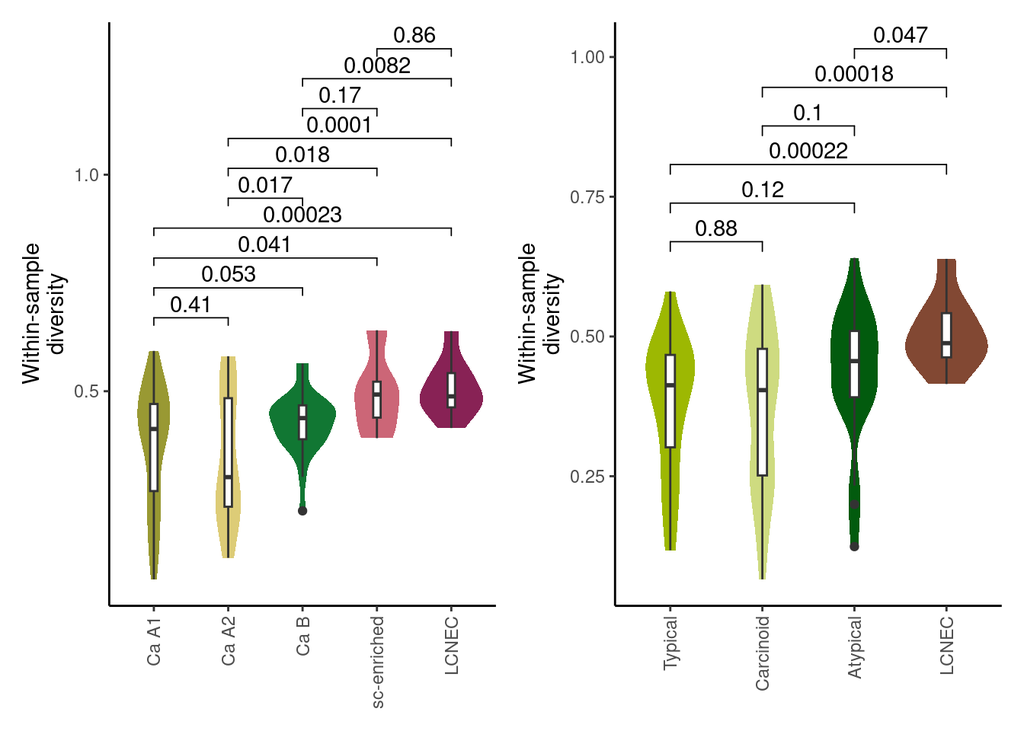

```r
ggSVA = ggplot( global.5p.prop4boot, aes(y=Diversity,x=group,fill=group)) +
  geom_violin(col=NA) + geom_boxplot(width=0.1,fill="white") + scale_fill_manual(values=arc4) + theme_classic() +
  stat_compare_means(comparisons = list(c("Ca A1","Ca A2"),
                                        c("Ca A1","Ca B"),
                                        c("Ca A1","sc-enriched"),
                                        c("Ca A1","LCNEC"),
                                        c("Ca A2","Ca B"),
                                        c("Ca A2","sc-enriched"),
                                        c("Ca A2","LCNEC"),
                                        c("Ca B","sc-enriched"),
                                        c("Ca B","LCNEC"),
                                        c("sc-enriched","LCNEC")),method = "t.test") +
  ylab("Within-sample\ndiversity") + theme(axis.title.x = element_blank(),axis.text.x = element_text(angle=90,hjust = 1,vjust = 0.5)) + guides(fill="none")

ggSVAty = ggplot( global.5p.prop4boot, aes(y=Diversity,x=type,fill=type)) +
  geom_violin(col=NA) + geom_boxplot(width=0.1,fill="white") + scale_fill_manual(values=type5) + theme_classic() +
  stat_compare_means(comparisons = list(c("Typical","Carcinoid"),
                                        c("Typical","Atypical"),
                                        c("Typical","LCNEC"),
                                        c("Carcinoid","Atypical"),
                                        c("Carcinoid","LCNEC"),
                                        c("Atypical","LCNEC") ),method = "t.test") +
  ylab("Within-sample\ndiversity") + theme(axis.title.x = element_blank(),axis.text.x = element_text(angle=90,hjust = 1,vjust = 0.5)) + guides(fill="none")


ggSVA + ggSVAty
```

```r
write_csv(left_join(sigs.groups.5p, global.5p.prop4boot[,c(1,32)]), file="TableS21_signatures.csv")
```